# Ficha de Información Metropolitana

Universidad Autónoma Metropolitnana

Lic. Martínez Rodriguez, Alvaro[^1]

Lic. Pérez Victorino, Leonardo[^2]

La ficha de información metropolitana es una herramienta valiosa para la planificación territorial en zonas metropolitanas (ZM). Proporciona información censal en diferentes formatos, como gráficos, tablas y mapas, tanto de los Censos de Población y Vivienda, 2020 (CPV2020) como de los Censos Económicos de 1999, 2004, 2009, 2014 y 2019. Ambos publicados por el Instituto Nacional de Estadística y Geografía (INEGI).

## Información general de la Zona Metropolitana de Mérida

| Nombre | Clave |
| --- | --- |
| Acanceh | 31002 |
| Conkal | 31013 |
| Hunucmá | 31038 |
| Kanasín | 31041 |
| Mérida | 31050 |
| Samahil | 31063 |
| Timucuy | 31090 |
| Tixkokob | 31093 |
| Tixpéhual | 31095 |
| Ucú | 31100 |

[output cut: 1 more lines]

Municipios de la zona metropolitana

Además, se presenta un mapa de la zona metropolitana:

[interactive chart not shown]

A continuación se presentan algunos datos generales sobre esta zona:

## Información sociodemográfica

La estructura de población de la zona metropolitana de Mérida se presenta en la una piramide poblacional ya que permite obtener una visión general de la distribución de la población por género y edad:

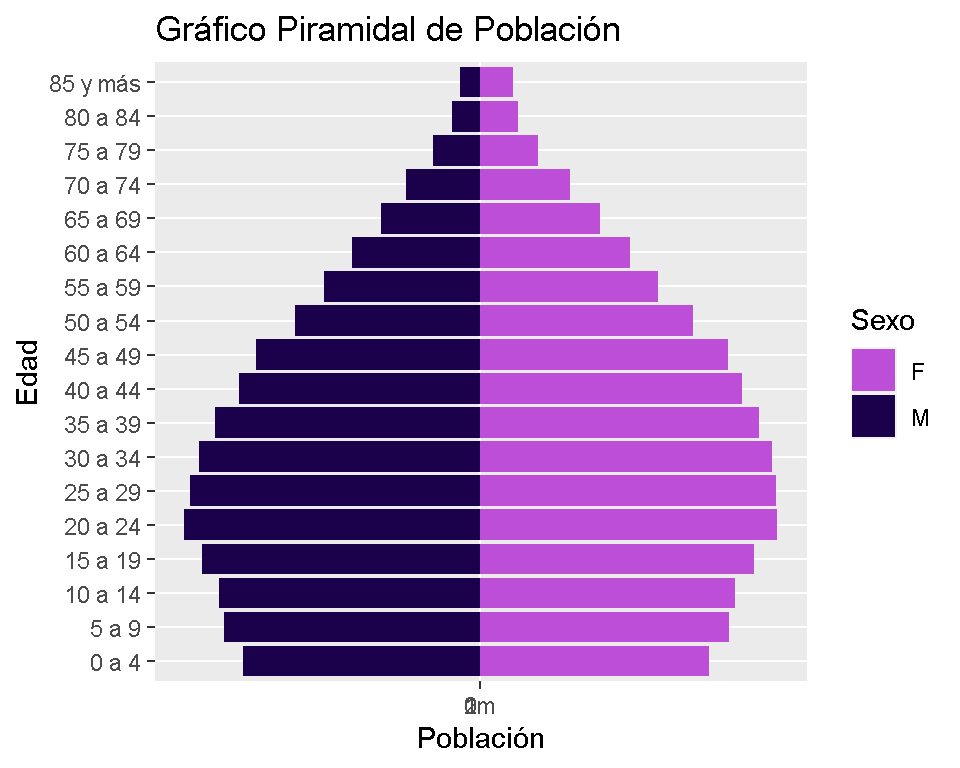

En el siguiente mapa se observa como se distribuye la población sobre la región:

[interactive chart not shown]

### Vivienda

El CPV 2020 también proporciona información sobre la vivienda en la zona metropolitana, a continuación se presentan los principales resultados:

- Número de viviendas habitadas: 392597
- Porcentaje de viviendas desocupadas:13%
- Promedio de ocupantes por vivienda: 3.679
- Promedio de ocupantes por cuarto:1.2145455
- Porcentaje de viviendas con servicios básicos:96%
- Porcentaje de viviendas sin bienes2: 0%
- Porcentaje de ocupantes en viviendas particulares que disponen de energía eléctrica, agua entubada y drenaje: 0%

### Socioeconómicos

La población en terminos de la poblacioón economicamente activa esta descrita por:

- Porcentaje de población de 12 años y más económicamente activa: 53%
- Porcentaje de población de 12 años y más no económicamente activa: 30% `

### Educación

La educación de la zona metropolitana esta caracterizada por los siguientes estadísticos:

- Porcentaje de población de 15 años y más sin escolaridad:2%
- Porcentaje de población de 15 años y más con al menos un grado aprobado en primaria: 70%
- Porcentaje de población de 15 años y más con educación básica completa: 16%
- Porcentaje de población de 15 años y más con secundaria o equivalente incompleta:2%
- Porcentaje de población de 18 años y más con al menos un grado aprobado en educación media superior: 42%

### Salud

La situación de la afiliación a algún servico de salud es la siguiente:

- Porcentaje de población afiliada a servicios de salud: 77%
- Población sin afiliación a servicios de salud:295114

### Indicadores de desarrollo

Finalmente se presentan tres indicadores de desarrollo; los índices son: índice de Desarrollo Humano (IDH), Índice de Marginación (IM) e Índice de Rezago Social (IRS).

IDH es un indicador elaborado por el Programa de Naciones Unidas para el Desarrollo (PNUD), este busca medir la calidad de vida, así como el progreso socioeconómico de cada entidad y municipio; El cálculo del Índice de Desarrollo Humano se realiza a partir de las tres variables: esperanza de vida, educación e ingreso per cápita.

- Muy Alto - IDH mayor de 1.
- Alto - IDH entre 0.80 a 1.
- Medio - IDH entre 0.50 y 0.80.
- Bajo - IDH entre 0 y 0.50
- Muy Bajo - IDH menores a 0.
- El promedio del IDH en 2020 para la zona metropolitana es de 0.743 según datos del PNUD.

El IM es un índice construido por el consejo Nacional de Población (CONAPO). Este índice considera 4 dimensiones estructurales para su construcción: vivienda, ingreso, educación y distribución de la población. El indice se puede ubicar en 5 estratos designados por la ténica de estratificación de Dalenius-Hodges..

Por último, el IRS es construido por el Consejo Nacional de Evaluación de la Política de Desarrollo Social, CONEVAL, este índice incorpora indicadores de educación, de acceso a servicios de salud, de servicios básicos y tiene como finalidad ordenar los municipios según sus carencias sociales. Este índice, al igual que el IM, se clasifica en cinco estratos.

## Datos económicos.

Con base en la información de los subsectores de los 21 sectores principales de la clasificación del SCIAN, extraída de los Censos Económicos del INEGI durante el periodo de 1998-2018, se ha llevado a cabo la agrupación de los datos de cada municipio que pertenece a una zona metropolitana en cinco grandes sectores: Primarios, Construcción, Manufactura, Comercio y Servicios. Esta clasificación se basa en la metodología proporcionada por el INEGI. Se utilizaron las siguientes variables:

- Unidades económicas (UE) [número de unidades]
- Activiso fijos totales (AF) [miles de pesos a precios corrientes]
- Formación bruta de capital fijo (FB) [miles de pesos a precios corrientes]
- Producción bruta total (PB) [miles de pesos a precios corrientes]
- Personal ocupado total (PO) [número de personas]
- Total de remuneraciones (RE) [miles de pesos a precios corrientes]
- Valor agregado censal bruto (VA) [miles de pesos a precios corrientes]

Posteriormente, se replica la metodología utilizada por García y Carranco (2008) para estimar los coeficientes de participación relativa (PR), de localización de la actividad económica (QL), Hirschman-Herfindahl (HH) e Inverso de Hirschman-Herfindahl (IHH).

$PR_ij$=$X_ij/X_in$

$QL_ij$=$(X_ij⁄X_j )/(X_in⁄X_n)$

$HH_ij$=$X_ij/X_in - X_j/X_n$

$IHH_ij$=$1/(X_ij/X_in - X_j/X_n)$

Donde:

- $X_ij$= Variable económica del sector i en el municipio j
- $X_j$= Variable económica del total de los sectores en el municipio j
- $X_in$= Variable económica del sector i de la Zona Metropolitana del municipio j
- $X_n$= Variable económica del total de los sectores de la Zona Metropolitana del municipio j

### Cifras brutas

#### 1999

##### UE

| Clave | Municipio | Primarios | Construcción | Manufactura | Comercio | Servicios |
| --- | --- | --- | --- | --- | --- | --- |
| 31002 | Acanceh | 0 | 0 | 31 | 120 | 23 |
| 31013 | Conkal | 0 | 0 | 19 | 60 | 31 |
| 31038 | Hunucmá | 0 | 0 | 128 | 321 | 142 |
| 31041 | Kanasín | 0 | 0 | 95 | 417 | 43 |
| 31050 | Mérida | 0 | 0 | 2,814 | 13,422 | 9,881 |
| 31063 | Samahil | 0 | 0 | 0 | 0 | 0 |
| 31090 | Timucuy | 0 | 0 | 0 | 0 | 0 |
| 31093 | Tixkokob | 0 | 0 | 23 | 146 | 48 |
| 31095 | Tixpéhual | 0 | 0 | 0 | 32 | 0 |
| 31100 | Ucú | 0 | 0 | 0 | 0 | 7 |

[output cut: 1 more lines]

##### AF

| Clave | Municipio | Primarios | Construcción | Manufactura | Comercio | Servicios |
| --- | --- | --- | --- | --- | --- | --- |
| 31002 | Acanceh | 77 | 0 | 2,687 | 5,901 | 3,543 |
| 31013 | Conkal | 6,522 | 0 | 12,897 | 1,860 | 1,479 |
| 31038 | Hunucmá | 41,358 | 0 | 6,504 | 10,208 | 11,175 |
| 31041 | Kanasín | 224,292 | 0 | 41,038 | 18,681 | 10,020 |
| 31050 | Mérida | 50,778 | 406,327 | 4,768,547 | 1,867,696 | 11,246,649 |
| 31063 | Samahil | 0 | 0 | 503 | 605 | 611 |
| 31090 | Timucuy | 0 | 0 | 338 | 528 | 777 |
| 31093 | Tixkokob | 153 | 0 | 4,680 | 7,425 | 4,206 |
| 31095 | Tixpéhual | 2,837 | 0 | 3,623 | 393 | 1,057 |
| 31100 | Ucú | 115 | 0 | 903 | 309 | 1,971 |

[output cut: 1 more lines]

##### FB

| Clave | Municipio | Primarios | Construcción | Manufactura | Comercio | Servicios |
| --- | --- | --- | --- | --- | --- | --- |
| 31002 | Acanceh | 0 | 0 | 6 | 595 | 18 |
| 31013 | Conkal | 0 | 0 | 58 | 1 | 24 |
| 31038 | Hunucmá | 995 | 0 | 160 | 193 | 82 |
| 31041 | Kanasín | 961 | 0 | 6,502 | 1,294 | 15 |
| 31050 | Mérida | 6,811 | 65,942 | 465,409 | 176,880 | 1,209,898 |
| 31063 | Samahil | 0 | 0 | 3 | 30 | 0 |
| 31090 | Timucuy | 0 | 0 | 2 | 9 | 0 |
| 31093 | Tixkokob | 0 | 0 | 0 | 87 | 65 |
| 31095 | Tixpéhual | 0 | 0 | 37 | 0 | 0 |
| 31100 | Ucú | 0 | 0 | 0 | 2 | 6 |

[output cut: 1 more lines]

##### PB

| Clave | Municipio | Primarios | Construcción | Manufactura | Comercio | Servicios |
| --- | --- | --- | --- | --- | --- | --- |
| 31002 | Acanceh | 0 | 0 | 37,185 | 11,902 | 2,343 |
| 31013 | Conkal | 11,538 | 0 | 19,902 | 4,581 | 1,794 |
| 31038 | Hunucmá | 59,671 | 0 | 25,895 | 19,964 | 11,418 |
| 31041 | Kanasín | 38,406 | 0 | 134,118 | 74,422 | 19,747 |
| 31050 | Mérida | 234,850 | 2,359,674 | 10,672,241 | 6,164,762 | 8,494,263 |
| 31063 | Samahil | 0 | 0 | 917 | 750 | 386 |
| 31090 | Timucuy | 0 | 0 | 1,590 | 573 | 176 |
| 31093 | Tixkokob | 180 | 0 | 10,555 | 22,478 | 7,897 |
| 31095 | Tixpéhual | 15,283 | 0 | 33,723 | 1,030 | 1,245 |
| 31100 | Ucú | 1,007 | 0 | 2,846 | 583 | 542 |

[output cut: 1 more lines]

##### PO

| Clave | Municipio | Primarios | Construcción | Manufactura | Comercio | Servicios |
| --- | --- | --- | --- | --- | --- | --- |
| 31002 | Acanceh | 4 | 0 | 608 | 285 | 171 |
| 31013 | Conkal | 158 | 0 | 235 | 114 | 79 |
| 31038 | Hunucmá | 904 | 0 | 553 | 589 | 458 |
| 31041 | Kanasín | 210 | 0 | 1,049 | 631 | 348 |
| 31050 | Mérida | 760 | 24,944 | 38,365 | 44,353 | 61,164 |
| 31063 | Samahil | 0 | 0 | 18 | 52 | 11 |
| 31090 | Timucuy | 0 | 0 | 41 | 57 | 8 |
| 31093 | Tixkokob | 12 | 0 | 115 | 265 | 224 |
| 31095 | Tixpéhual | 42 | 0 | 102 | 49 | 22 |
| 31100 | Ucú | 20 | 0 | 33 | 38 | 17 |

[output cut: 1 more lines]

##### RE

| Clave | Municipio | Primarios | Construcción | Manufactura | Comercio | Servicios |
| --- | --- | --- | --- | --- | --- | --- |
| 31002 | Acanceh | 167 | 0 | 8,763 | 4,949 | 2,093 |
| 31013 | Conkal | 1,306 | 0 | 2,920 | 513 | 201 |
| 31038 | Hunucmá | 314 | 0 | 3,501 | 2,564 | 1,823 |
| 31041 | Kanasín | 6,206 | 0 | 15,491 | 4,583 | 3,103 |
| 31050 | Mérida | 9,833 | 297,919 | 1,072,919 | 1,015,937 | 1,817,426 |
| 31063 | Samahil | 0 | 0 | 61 | 156 | 18 |
| 31090 | Timucuy | 0 | 0 | 69 | 10 | 12 |
| 31093 | Tixkokob | 113 | 0 | 819 | 1,751 | 1,893 |
| 31095 | Tixpéhual | 1,300 | 0 | 2,996 | 62 | 70 |
| 31100 | Ucú | 220 | 0 | 360 | 11 | 10 |

[output cut: 1 more lines]

##### VA

| Clave | Municipio | Primarios | Construcción | Manufactura | Comercio | Servicios |
| --- | --- | --- | --- | --- | --- | --- |
| 31002 | Acanceh | -55 | 0 | 15,490 | 10,248 | -1,826 |
| 31013 | Conkal | 7,863 | 0 | 6,728 | 3,920 | 533 |
| 31038 | Hunucmá | 20,878 | 0 | 8,289 | 14,639 | 4,139 |
| 31041 | Kanasín | 16,484 | 0 | 29,925 | 62,402 | 6,661 |
| 31050 | Mérida | 87,207 | 475,258 | 3,138,180 | 3,855,132 | 4,165,834 |
| 31063 | Samahil | 0 | 0 | 268 | 658 | 62 |
| 31090 | Timucuy | 0 | 0 | 402 | 442 | 1 |
| 31093 | Tixkokob | 86 | 0 | 2,723 | 19,940 | 1,263 |
| 31095 | Tixpéhual | 11,606 | 0 | 12,062 | 860 | 287 |
| 31100 | Ucú | 282 | 0 | 690 | 481 | 11 |

[output cut: 1 more lines]

#### 2004

##### UE

| Clave | Municipio | Primarios | Construcción | Manufactura | Comercio | Servicios |
| --- | --- | --- | --- | --- | --- | --- |
| 31002 | Acanceh | 0 | 0 | 51 | 137 | 30 |
| 31013 | Conkal | 0 | 0 | 26 | 102 | 41 |
| 31038 | Hunucmá | 0 | 0 | 142 | 491 | 161 |
| 31041 | Kanasín | 7 | 0 | 86 | 568 | 84 |
| 31050 | Mérida | 0 | 233 | 2,628 | 14,573 | 11,375 |
| 31063 | Samahil | 0 | 0 | 6 | 0 | 0 |
| 31090 | Timucuy | 0 | 0 | 5 | 0 | 0 |
| 31093 | Tixkokob | 0 | 0 | 69 | 167 | 51 |
| 31095 | Tixpéhual | 0 | 0 | 5 | 41 | 9 |
| 31100 | Ucú | 0 | 0 | 5 | 0 | 5 |

[output cut: 1 more lines]

##### AF

| Clave | Municipio | Primarios | Construcción | Manufactura | Comercio | Servicios |
| --- | --- | --- | --- | --- | --- | --- |
| 31002 | Acanceh | 0 | 0 | 6,342 | 6,836 | 8,484 |
| 31013 | Conkal | 9,850 | 0 | 20,260 | 6,094 | 7,321 |
| 31038 | Hunucmá | 9,314 | 0 | 43,352 | 25,860 | 24,172 |
| 31041 | Kanasín | 58,267 | 26,388 | 100,062 | 102,646 | 64,489 |
| 31050 | Mérida | 62,418 | 707,257 | 6,455,423 | 4,396,590 | 21,931,120 |
| 31063 | Samahil | 0 | 0 | 311 | 1,634 | 1,020 |
| 31090 | Timucuy | 0 | 0 | 421 | 704 | 528 |
| 31093 | Tixkokob | 0 | 0 | 44,894 | 12,954 | 46,665 |
| 31095 | Tixpéhual | 3,257 | 0 | 880 | 2,177 | 1,299 |
| 31100 | Ucú | 2,079 | 0 | 1,092 | 811 | 1,083 |

[output cut: 1 more lines]

##### FB

| Clave | Municipio | Primarios | Construcción | Manufactura | Comercio | Servicios |
| --- | --- | --- | --- | --- | --- | --- |
| 31002 | Acanceh | 0 | 0 | 137 | 40 | 1,184 |
| 31013 | Conkal | 0 | 0 | 610 | 841 | 404 |
| 31038 | Hunucmá | 966 | 0 | 461 | 566 | 1,348 |
| 31041 | Kanasín | 19,709 | 130 | 4,927 | 2,325 | 571 |
| 31050 | Mérida | 6,893 | 79,780 | 737,194 | 282,599 | 1,641,922 |
| 31063 | Samahil | 0 | 0 | 45 | 18 | 460 |
| 31090 | Timucuy | 0 | 0 | 0 | 2 | 17 |
| 31093 | Tixkokob | 0 | 0 | 1,558 | 859 | 1,052 |
| 31095 | Tixpéhual | 0 | 0 | 0 | 12 | 14 |
| 31100 | Ucú | 0 | 0 | 47 | 29 | 90 |

[output cut: 1 more lines]

##### PB

| Clave | Municipio | Primarios | Construcción | Manufactura | Comercio | Servicios |
| --- | --- | --- | --- | --- | --- | --- |
| 31002 | Acanceh | 0 | 0 | 363,029 | 16,777 | 11,239 |
| 31013 | Conkal | 3,404 | 0 | 63,181 | 10,619 | 14,881 |
| 31038 | Hunucmá | 43,927 | 0 | 113,383 | 55,875 | 27,609 |
| 31041 | Kanasín | 96,670 | 77,631 | 455,597 | 147,384 | 66,391 |
| 31050 | Mérida | 88,918 | 4,050,442 | 15,054,799 | 9,858,594 | 24,841,976 |
| 31063 | Samahil | 0 | 0 | 1,036 | 1,617 | 703 |
| 31090 | Timucuy | 0 | 0 | 1,370 | 2,213 | 428 |
| 31093 | Tixkokob | 0 | 0 | 41,379 | 28,189 | 45,962 |
| 31095 | Tixpéhual | 14,602 | 0 | 2,271 | 4,878 | 2,352 |
| 31100 | Ucú | 4,826 | 0 | 11,195 | 1,169 | 1,711 |

[output cut: 1 more lines]

##### PO

| Clave | Municipio | Primarios | Construcción | Manufactura | Comercio | Servicios |
| --- | --- | --- | --- | --- | --- | --- |
| 31002 | Acanceh | 0 | 0 | 1,051 | 363 | 288 |
| 31013 | Conkal | 7 | 0 | 292 | 224 | 188 |
| 31038 | Hunucmá | 793 | 0 | 781 | 1,079 | 813 |
| 31041 | Kanasín | 259 | 155 | 1,563 | 1,733 | 743 |
| 31050 | Mérida | 310 | 18,003 | 41,607 | 63,278 | 78,688 |
| 31063 | Samahil | 0 | 0 | 24 | 86 | 49 |
| 31090 | Timucuy | 0 | 0 | 23 | 76 | 42 |
| 31093 | Tixkokob | 0 | 0 | 399 | 418 | 358 |
| 31095 | Tixpéhual | 15 | 0 | 34 | 127 | 84 |
| 31100 | Ucú | 11 | 0 | 55 | 65 | 28 |

[output cut: 1 more lines]

##### RE

| Clave | Municipio | Primarios | Construcción | Manufactura | Comercio | Servicios |
| --- | --- | --- | --- | --- | --- | --- |
| 31002 | Acanceh | 0 | 0 | 76,144 | 2,514 | 5,940 |
| 31013 | Conkal | 264 | 0 | 6,501 | 1,895 | 1,473 |
| 31038 | Hunucmá | 6,760 | 0 | 12,939 | 7,536 | 4,851 |
| 31041 | Kanasín | 14,624 | 10,255 | 41,680 | 30,748 | 9,366 |
| 31050 | Mérida | 14,007 | 467,770 | 1,992,899 | 1,823,590 | 3,383,849 |
| 31063 | Samahil | 0 | 0 | 44 | 510 | 21 |
| 31090 | Timucuy | 0 | 0 | 33 | 35 | 108 |
| 31093 | Tixkokob | 0 | 0 | 9,394 | 4,669 | 4,247 |
| 31095 | Tixpéhual | 850 | 0 | 354 | 406 | 350 |
| 31100 | Ucú | 284 | 0 | 801 | 38 | 50 |

[output cut: 1 more lines]

##### VA

| Clave | Municipio | Primarios | Construcción | Manufactura | Comercio | Servicios |
| --- | --- | --- | --- | --- | --- | --- |
| 31002 | Acanceh | 0 | 0 | 140,448 | 14,302 | -3,014 |
| 31013 | Conkal | 1,380 | 0 | 35,937 | 8,663 | 10,213 |
| 31038 | Hunucmá | 20,873 | 0 | 84,899 | 47,315 | 12,436 |
| 31041 | Kanasín | 42,298 | 21,388 | 96,070 | 111,813 | 30,802 |
| 31050 | Mérida | 57,885 | 1,269,390 | 5,970,823 | 6,228,834 | 11,984,526 |
| 31063 | Samahil | 0 | 0 | 222 | 1,107 | 48 |
| 31090 | Timucuy | 0 | 0 | 656 | 1,931 | -153 |
| 31093 | Tixkokob | 0 | 0 | 14,776 | 23,314 | 19,010 |
| 31095 | Tixpéhual | 6,230 | 0 | 990 | 4,220 | 684 |
| 31100 | Ucú | 2,973 | 0 | 4,338 | 957 | 542 |

[output cut: 1 more lines]

#### 2009

##### UE

| Clave | Municipio | Primarios | Construcción | Manufactura | Comercio | Servicios |
| --- | --- | --- | --- | --- | --- | --- |
| 31002 | Acanceh | 0 | 0 | 104 | 211 | 110 |
| 31013 | Conkal | 0 | 0 | 17 | 133 | 62 |
| 31038 | Hunucmá | 0 | 0 | 198 | 534 | 172 |
| 31041 | Kanasín | 0 | 0 | 210 | 810 | 405 |
| 31050 | Mérida | 0 | 596 | 3,386 | 16,479 | 15,704 |
| 31063 | Samahil | 0 | 0 | 5 | 42 | 12 |
| 31090 | Timucuy | 0 | 0 | 0 | 0 | 0 |
| 31093 | Tixkokob | 0 | 0 | 122 | 229 | 99 |
| 31095 | Tixpéhual | 0 | 0 | 0 | 52 | 14 |
| 31100 | Ucú | 0 | 0 | 0 | 33 | 7 |

[output cut: 1 more lines]

##### AF

| Clave | Municipio | Primarios | Construcción | Manufactura | Comercio | Servicios |
| --- | --- | --- | --- | --- | --- | --- |
| 31002 | Acanceh | 0 | 0 | 181,590 | 30,629 | 27,576 |
| 31013 | Conkal | 2,570 | 0 | 24,726 | 6,901 | 2,976 |
| 31038 | Hunucmá | 17,962 | 0 | 23,906 | 53,465 | 57,466 |
| 31041 | Kanasín | 114,906 | 134,270 | 349,417 | 179,105 | 117,709 |
| 31050 | Mérida | 40,083 | 1,679,243 | 10,534,447 | 8,089,441 | 40,780,906 |
| 31063 | Samahil | 0 | 0 | 941 | 2,914 | 5,959 |
| 31090 | Timucuy | 0 | 0 | 846 | 2,263 | 623 |
| 31093 | Tixkokob | 0 | 5 | 80,350 | 20,889 | 24,223 |
| 31095 | Tixpéhual | 11,245 | 0 | 28,772 | 5,303 | 3,215 |
| 31100 | Ucú | 9,060 | 0 | 5,745 | 3,898 | 400 |

[output cut: 1 more lines]

##### FB

| Clave | Municipio | Primarios | Construcción | Manufactura | Comercio | Servicios |
| --- | --- | --- | --- | --- | --- | --- |
| 31002 | Acanceh | 0 | 0 | 7,283 | 1,637 | 252 |
| 31013 | Conkal | 0 | 0 | 120 | 194 | 143 |
| 31038 | Hunucmá | 83 | 0 | 745 | 2,658 | 1,138 |
| 31041 | Kanasín | 10,439 | 34,394 | 22,048 | 10,585 | 4,804 |
| 31050 | Mérida | 3,631 | 59,216 | 584,235 | 900,290 | 2,398,211 |
| 31063 | Samahil | 0 | 0 | 101 | -9 | 114 |
| 31090 | Timucuy | 0 | 0 | 0 | 0 | 0 |
| 31093 | Tixkokob | 0 | 0 | 295 | 1,042 | 392 |
| 31095 | Tixpéhual | 0 | 0 | 76 | 188 | 156 |
| 31100 | Ucú | 0 | 0 | 65 | 151 | 12 |

[output cut: 1 more lines]

##### PB

| Clave | Municipio | Primarios | Construcción | Manufactura | Comercio | Servicios |
| --- | --- | --- | --- | --- | --- | --- |
| 31002 | Acanceh | 0 | 0 | 415,393 | 25,015 | 27,589 |
| 31013 | Conkal | 1,895 | 0 | 26,925 | 13,542 | 10,418 |
| 31038 | Hunucmá | 24,832 | 0 | 51,367 | 169,534 | 61,903 |
| 31041 | Kanasín | 140,275 | 430,068 | 1,090,173 | 217,940 | 153,157 |
| 31050 | Mérida | 99,025 | 9,262,552 | 22,102,971 | 15,191,664 | 33,560,506 |
| 31063 | Samahil | 0 | 0 | 2,007 | 2,492 | 2,062 |
| 31090 | Timucuy | 0 | 0 | 1,837 | 1,550 | 664 |
| 31093 | Tixkokob | 0 | 38 | 218,388 | 39,452 | 39,618 |
| 31095 | Tixpéhual | 53,790 | 0 | 27,718 | 3,883 | 2,949 |
| 31100 | Ucú | 4,988 | 0 | 10,900 | 1,322 | 689 |

[output cut: 1 more lines]

##### PO

| Clave | Municipio | Primarios | Construcción | Manufactura | Comercio | Servicios |
| --- | --- | --- | --- | --- | --- | --- |
| 31002 | Acanceh | 0 | 0 | 1,627 | 686 | 397 |
| 31013 | Conkal | 18 | 0 | 203 | 337 | 246 |
| 31038 | Hunucmá | 701 | 0 | 725 | 1,567 | 997 |
| 31041 | Kanasín | 338 | 556 | 2,040 | 2,351 | 1,717 |
| 31050 | Mérida | 220 | 18,660 | 37,029 | 76,618 | 110,292 |
| 31063 | Samahil | 0 | 0 | 49 | 157 | 76 |
| 31090 | Timucuy | 0 | 0 | 26 | 90 | 13 |
| 31093 | Tixkokob | 0 | 1 | 1,720 | 654 | 543 |
| 31095 | Tixpéhual | 40 | 0 | 195 | 141 | 70 |
| 31100 | Ucú | 15 | 0 | 46 | 105 | 34 |

[output cut: 1 more lines]

##### RE

| Clave | Municipio | Primarios | Construcción | Manufactura | Comercio | Servicios |
| --- | --- | --- | --- | --- | --- | --- |
| 31002 | Acanceh | 0 | 0 | 123,232 | 12,011 | 2,771 |
| 31013 | Conkal | 747 | 0 | 6,023 | 2,569 | 1,649 |
| 31038 | Hunucmá | 1,235 | 0 | 11,013 | 7,128 | 8,605 |
| 31041 | Kanasín | 16,427 | 37,119 | 75,931 | 36,155 | 27,950 |
| 31050 | Mérida | 13,796 | 1,249,017 | 1,884,551 | 2,230,768 | 5,430,437 |
| 31063 | Samahil | 0 | 0 | 209 | 1,146 | 280 |
| 31090 | Timucuy | 0 | 0 | 320 | 175 | 67 |
| 31093 | Tixkokob | 0 | 0 | 79,801 | 6,738 | 4,721 |
| 31095 | Tixpéhual | 2,840 | 0 | 11,012 | 433 | 234 |
| 31100 | Ucú | 645 | 0 | 935 | 596 | 53 |

[output cut: 1 more lines]

##### VA

| Clave | Municipio | Primarios | Construcción | Manufactura | Comercio | Servicios |
| --- | --- | --- | --- | --- | --- | --- |
| 31002 | Acanceh | 0 | 0 | 313,320 | -13,688 | 16,487 |
| 31013 | Conkal | 836 | 0 | 10,586 | 10,139 | 3,676 |
| 31038 | Hunucmá | 9,348 | 0 | 21,587 | 76,284 | 31,717 |
| 31041 | Kanasín | 82,680 | 91,372 | 246,026 | 100,332 | 62,308 |
| 31050 | Mérida | 39,068 | 2,689,082 | 5,839,201 | 8,467,859 | 16,879,470 |
| 31063 | Samahil | 0 | 0 | 900 | 1,664 | 689 |
| 31090 | Timucuy | 0 | 0 | 719 | 926 | -547 |
| 31093 | Tixkokob | 0 | 22 | 146,122 | 29,862 | 19,603 |
| 31095 | Tixpéhual | 34,487 | 0 | 14,413 | 2,900 | 1,331 |
| 31100 | Ucú | 499 | 0 | 4,655 | 752 | 154 |

[output cut: 1 more lines]

#### 2014

##### UE

| Clave | Municipio | Primarios | Construcción | Manufactura | Comercio | Servicios |
| --- | --- | --- | --- | --- | --- | --- |
| 31002 | Acanceh | 0 | 0 | 92 | 211 | 60 |
| 31013 | Conkal | 0 | 0 | 29 | 147 | 92 |
| 31038 | Hunucmá | 0 | 0 | 220 | 563 | 333 |
| 31041 | Kanasín | 0 | 4 | 269 | 1,162 | 725 |
| 31050 | Mérida | 7 | 527 | 3,622 | 17,478 | 20,056 |
| 31063 | Samahil | 0 | 0 | 14 | 57 | 15 |
| 31090 | Timucuy | 0 | 0 | 7 | 37 | 5 |
| 31093 | Tixkokob | 0 | 0 | 93 | 237 | 212 |
| 31095 | Tixpéhual | 0 | 0 | 6 | 61 | 34 |
| 31100 | Ucú | 0 | 0 | 9 | 42 | 9 |

[output cut: 1 more lines]

##### AF

| Clave | Municipio | Primarios | Construcción | Manufactura | Comercio | Servicios |
| --- | --- | --- | --- | --- | --- | --- |
| 31002 | Acanceh | 0 | 0 | 206,811 | 24,924 | 11,516 |
| 31013 | Conkal | 0 | 0 | 7,634 | 14,936 | 2,895 |
| 31038 | Hunucmá | 0 | 0 | 28,500 | 68,483 | 55,948 |
| 31041 | Kanasín | 0 | 88,786 | 441,159 | 207,334 | 191,064 |
| 31050 | Mérida | 91,066 | 1,605,537 | 10,099,623 | 11,484,681 | 16,488,482 |
| 31063 | Samahil | 0 | 0 | 1,786 | 16,527 | 1,247 |
| 31090 | Timucuy | 0 | 0 | 917 | 1,627 | 18 |
| 31093 | Tixkokob | 0 | 0 | 98,544 | 29,735 | 26,806 |
| 31095 | Tixpéhual | 0 | 0 | 2,213 | 5,380 | 1,327 |
| 31100 | Ucú | 0 | 0 | 6,462 | 3,636 | 6,817 |

[output cut: 1 more lines]

##### FB

| Clave | Municipio | Primarios | Construcción | Manufactura | Comercio | Servicios |
| --- | --- | --- | --- | --- | --- | --- |
| 31002 | Acanceh | 0 | 0 | 4,270 | 1,013 | 1,045 |
| 31013 | Conkal | 0 | 0 | 147 | 675 | 94 |
| 31038 | Hunucmá | 0 | 0 | 596 | 1,384 | 1,004 |
| 31041 | Kanasín | 0 | 5,875 | 16,627 | 9,727 | 4,565 |
| 31050 | Mérida | 1,790 | 3,002 | 410,929 | 731,232 | 1,072,265 |
| 31063 | Samahil | 0 | 0 | 59 | 5 | 1 |
| 31090 | Timucuy | 0 | 0 | 0 | 136 | 0 |
| 31093 | Tixkokob | 0 | 0 | 24,836 | 495 | 588 |
| 31095 | Tixpéhual | 0 | 0 | 0 | 96 | 0 |
| 31100 | Ucú | 0 | 0 | 131 | 25 | -4 |

[output cut: 1 more lines]

##### PB

| Clave | Municipio | Primarios | Construcción | Manufactura | Comercio | Servicios |
| --- | --- | --- | --- | --- | --- | --- |
| 31002 | Acanceh | 0 | 0 | 485,685 | 32,304 | 76,168 |
| 31013 | Conkal | 0 | 0 | 30,908 | 26,150 | 13,656 |
| 31038 | Hunucmá | 0 | 0 | 70,714 | 122,942 | 146,673 |
| 31041 | Kanasín | 0 | 420,288 | 1,504,950 | 377,906 | 251,828 |
| 31050 | Mérida | 79,481 | 6,487,897 | 30,437,291 | 20,676,431 | 89,438,862 |
| 31063 | Samahil | 0 | 0 | 3,100 | 8,178 | 2,072 |
| 31090 | Timucuy | 0 | 0 | 2,060 | 4,997 | 516 |
| 31093 | Tixkokob | 0 | 0 | 173,923 | 30,805 | 31,284 |
| 31095 | Tixpéhual | 0 | 0 | 4,452 | 6,008 | 3,890 |
| 31100 | Ucú | 0 | 0 | 3,851 | 8,024 | 2,812 |

[output cut: 1 more lines]

##### PO

| Clave | Municipio | Primarios | Construcción | Manufactura | Comercio | Servicios |
| --- | --- | --- | --- | --- | --- | --- |
| 31002 | Acanceh | 0 | 0 | 1,717 | 470 | 132 |
| 31013 | Conkal | 0 | 0 | 115 | 306 | 192 |
| 31038 | Hunucmá | 0 | 0 | 728 | 1,178 | 829 |
| 31041 | Kanasín | 0 | 487 | 2,203 | 3,469 | 2,012 |
| 31050 | Mérida | 246 | 16,019 | 34,585 | 77,315 | 136,125 |
| 31063 | Samahil | 0 | 0 | 43 | 120 | 35 |
| 31090 | Timucuy | 0 | 0 | 21 | 79 | 14 |
| 31093 | Tixkokob | 0 | 0 | 1,605 | 476 | 487 |
| 31095 | Tixpéhual | 0 | 0 | 25 | 115 | 61 |
| 31100 | Ucú | 0 | 0 | 28 | 71 | 23 |

[output cut: 1 more lines]

##### RE

| Clave | Municipio | Primarios | Construcción | Manufactura | Comercio | Servicios |
| --- | --- | --- | --- | --- | --- | --- |
| 31002 | Acanceh | 0 | 0 | 145,070 | 4,790 | 1,696 |
| 31013 | Conkal | 0 | 0 | 3,054 | 2,439 | 1,578 |
| 31038 | Hunucmá | 0 | 0 | 13,742 | 10,380 | 9,824 |
| 31041 | Kanasín | 0 | 13,414 | 111,630 | 52,143 | 40,328 |
| 31050 | Mérida | 16,607 | 861,698 | 2,187,227 | 2,634,372 | 8,093,712 |
| 31063 | Samahil | 0 | 0 | 342 | 2,374 | 115 |
| 31090 | Timucuy | 0 | 0 | 284 | 78 | 24 |
| 31093 | Tixkokob | 0 | 0 | 86,333 | 4,528 | 7,502 |
| 31095 | Tixpéhual | 0 | 0 | 780 | 523 | 159 |
| 31100 | Ucú | 0 | 0 | 428 | 208 | 300 |

[output cut: 1 more lines]

##### VA

| Clave | Municipio | Primarios | Construcción | Manufactura | Comercio | Servicios |
| --- | --- | --- | --- | --- | --- | --- |
| 31002 | Acanceh | 0 | 0 | 264,569 | 23,069 | 39,935 |
| 31013 | Conkal | 0 | 0 | 9,148 | 15,886 | 4,723 |
| 31038 | Hunucmá | 0 | 0 | 34,742 | 80,271 | 109,256 |
| 31041 | Kanasín | 0 | 143,349 | 245,652 | 218,207 | 114,360 |
| 31050 | Mérida | 29,693 | 2,027,805 | 8,058,879 | 12,896,306 | 24,294,036 |
| 31063 | Samahil | 0 | 0 | 723 | 5,921 | 542 |
| 31090 | Timucuy | 0 | 0 | 886 | 3,695 | 148 |
| 31093 | Tixkokob | 0 | 0 | 113,959 | 19,825 | 15,624 |
| 31095 | Tixpéhual | 0 | 0 | 2,407 | 4,253 | 1,484 |
| 31100 | Ucú | 0 | 0 | 1,351 | 6,880 | 1,239 |

[output cut: 1 more lines]

#### 2019

##### UE

| Clave | Municipio | Primarios | Construcción | Manufactura | Comercio | Servicios |
| --- | --- | --- | --- | --- | --- | --- |
| 31002 | Acanceh | 0 | 0 | 90 | 226 | 177 |
| 31013 | Conkal | 2 | 0 | 65 | 175 | 208 |
| 31038 | Hunucmá | 99 | 0 | 257 | 692 | 563 |
| 31041 | Kanasín | 5 | 10 | 318 | 1,461 | 1,103 |
| 31050 | Mérida | 19 | 553 | 3,850 | 18,574 | 23,068 |
| 31063 | Samahil | 0 | 0 | 50 | 85 | 71 |
| 31090 | Timucuy | 0 | 0 | 14 | 54 | 27 |
| 31093 | Tixkokob | 0 | 0 | 120 | 243 | 307 |
| 31095 | Tixpéhual | 2 | 0 | 14 | 73 | 66 |
| 31100 | Ucú | 1 | 0 | 15 | 61 | 34 |

[output cut: 1 more lines]

##### AF

| Clave | Municipio | Primarios | Construcción | Manufactura | Comercio | Servicios |
| --- | --- | --- | --- | --- | --- | --- |
| 31002 | Acanceh | 0 | 0 | 270,214 | 31,254 | 3,458 |
| 31013 | Conkal | 0 | 0 | 23,508 | 39,925 | 14,938 |
| 31038 | Hunucmá | 0 | 0 | 66,979 | 82,170 | 109,890 |
| 31041 | Kanasín | 0 | 242,811 | 1,783,744 | 427,431 | 333,060 |
| 31050 | Mérida | 39,732 | 2,246,254 | 8,610,863 | 27,435,275 | 22,523,359 |
| 31063 | Samahil | 0 | 0 | 3,678 | 5,320 | 1,108 |
| 31090 | Timucuy | 0 | 0 | 34,183 | 4,499 | 602 |
| 31093 | Tixkokob | 0 | 0 | 216,146 | 272,053 | 31,861 |
| 31095 | Tixpéhual | 0 | 0 | 1,732 | 5,465 | 26,235 |
| 31100 | Ucú | 0 | 0 | 1,503 | 2,630 | 401 |

[output cut: 1 more lines]

##### FB

| Clave | Municipio | Primarios | Construcción | Manufactura | Comercio | Servicios |
| --- | --- | --- | --- | --- | --- | --- |
| 31002 | Acanceh | 0 | 0 | 25,399 | 1,521 | 184 |
| 31013 | Conkal | 0 | 0 | 366 | 401 | 47 |
| 31038 | Hunucmá | 0 | 0 | 2,425 | 2,915 | 1,660 |
| 31041 | Kanasín | 0 | 3,859 | 44,240 | 19,270 | 20,353 |
| 31050 | Mérida | 9 | 84,471 | 450,341 | 1,560,066 | 850,572 |
| 31063 | Samahil | 0 | 0 | -40 | -164 | -303 |
| 31090 | Timucuy | 0 | 0 | 0 | 17 | 47 |
| 31093 | Tixkokob | 0 | 0 | 5,206 | 339 | 47 |
| 31095 | Tixpéhual | 0 | 0 | 36 | 0 | 13 |
| 31100 | Ucú | 0 | 0 | 327 | 618 | 42 |

[output cut: 1 more lines]

##### PB

| Clave | Municipio | Primarios | Construcción | Manufactura | Comercio | Servicios |
| --- | --- | --- | --- | --- | --- | --- |
| 31002 | Acanceh | 0 | 0 | 483,758 | 67,180 | 14,745 |
| 31013 | Conkal | 0 | 0 | 143,094 | 72,877 | 13,097 |
| 31038 | Hunucmá | 0 | 0 | 129,080 | 150,945 | 140,610 |
| 31041 | Kanasín | 0 | 191,122 | 3,742,772 | 696,051 | 587,623 |
| 31050 | Mérida | 40,402 | 14,053,292 | 39,282,590 | 39,453,288 | 41,728,634 |
| 31063 | Samahil | 0 | 0 | 10,742 | 11,352 | 8,387 |
| 31090 | Timucuy | 0 | 0 | 3,799 | 7,672 | 6,707 |
| 31093 | Tixkokob | 0 | 0 | 1,193,851 | 79,221 | 54,034 |
| 31095 | Tixpéhual | 0 | 0 | 6,573 | 10,702 | 9,893 |
| 31100 | Ucú | 0 | 0 | 2,969 | 10,160 | 3,900 |

[output cut: 1 more lines]

##### PO

| Clave | Municipio | Primarios | Construcción | Manufactura | Comercio | Servicios |
| --- | --- | --- | --- | --- | --- | --- |
| 31002 | Acanceh | 0 | 0 | 2,178 | 521 | 82 |
| 31013 | Conkal | 0 | 0 | 416 | 418 | 111 |
| 31038 | Hunucmá | 0 | 0 | 938 | 1,322 | 1,825 |
| 31041 | Kanasín | 0 | 220 | 3,369 | 3,439 | 2,869 |
| 31050 | Mérida | 143 | 21,694 | 42,325 | 89,035 | 158,390 |
| 31063 | Samahil | 0 | 0 | 127 | 205 | 151 |
| 31090 | Timucuy | 0 | 0 | 24 | 92 | 39 |
| 31093 | Tixkokob | 0 | 0 | 1,684 | 499 | 539 |
| 31095 | Tixpéhual | 0 | 0 | 36 | 118 | 120 |
| 31100 | Ucú | 0 | 0 | 25 | 102 | 52 |

[output cut: 1 more lines]

##### RE

| Clave | Municipio | Primarios | Construcción | Manufactura | Comercio | Servicios |
| --- | --- | --- | --- | --- | --- | --- |
| 31002 | Acanceh | 0 | 0 | 200,562 | 8,458 | 2,469 |
| 31013 | Conkal | 0 | 0 | 21,019 | 9,817 | 2,748 |
| 31038 | Hunucmá | 0 | 0 | 35,790 | 15,223 | 30,162 |
| 31041 | Kanasín | 0 | 10,853 | 127,656 | 93,850 | 67,746 |
| 31050 | Mérida | 6,296 | 1,356,499 | 3,213,000 | 4,029,904 | 9,884,225 |
| 31063 | Samahil | 0 | 0 | 2,256 | 71,167 | 872 |
| 31090 | Timucuy | 0 | 0 | 666 | 324 | 773 |
| 31093 | Tixkokob | 0 | 0 | 146,300 | 12,005 | 12,117 |
| 31095 | Tixpéhual | 0 | 0 | 1,128 | 1,307 | 1,459 |
| 31100 | Ucú | 0 | 0 | 228 | 884 | 504 |

[output cut: 1 more lines]

##### VA

| Clave | Municipio | Primarios | Construcción | Manufactura | Comercio | Servicios |
| --- | --- | --- | --- | --- | --- | --- |
| 31002 | Acanceh | 0 | 0 | 241,491 | 45,327 | 8,243 |
| 31013 | Conkal | 0 | 0 | 48,831 | 53,436 | 7,103 |
| 31038 | Hunucmá | 0 | 0 | 61,946 | 102,011 | 69,751 |
| 31041 | Kanasín | 0 | 68,941 | 1,221,731 | 454,572 | 288,368 |
| 31050 | Mérida | 18,982 | 4,186,547 | 9,707,150 | 25,227,708 | 22,003,039 |
| 31063 | Samahil | 0 | 0 | 4,911 | 7,482 | 3,764 |
| 31090 | Timucuy | 0 | 0 | 1,098 | 6,052 | 3,501 |
| 31093 | Tixkokob | 0 | 0 | 243,314 | 51,333 | 26,019 |
| 31095 | Tixpéhual | 0 | 0 | 2,584 | 7,601 | 4,092 |
| 31100 | Ucú | 0 | 0 | 1,190 | 7,938 | 2,255 |

[output cut: 1 more lines]

### Coeficientes de localización (QL)

#### 1999

##### UE

| Clave | Municipio | Primarios | Construcción | Manufactura | Comercio | Servicios |
| --- | --- | --- | --- | --- | --- | --- |
| 31002 | Acanceh | 0.0000 | 0.0000 | 1.6057 | 1.3071 | 0.3746 |
| 31013 | Conkal | 0.0000 | 0.0000 | 1.5567 | 1.0338 | 0.7988 |
| 31038 | Hunucmá | 0.0000 | 0.0000 | 1.9520 | 1.0294 | 0.6810 |
| 31041 | Kanasín | 0.0000 | 0.0000 | 1.5427 | 1.4240 | 0.2196 |
| 31050 | Mérida | 0.0000 | 0.0000 | 0.9711 | 0.9740 | 1.0723 |
| 31063 | Samahil | NA | NA | NA | NA | NA |
| 31090 | Timucuy | NA | NA | NA | NA | NA |
| 31093 | Tixkokob | 0.0000 | 0.0000 | 0.9553 | 1.2752 | 0.6269 |
| 31095 | Tixpéhual | 0.0000 | 0.0000 | 0.0000 | 1.8953 | 0.0000 |
| 31100 | Ucú | 0.0000 | 0.0000 | 0.0000 | 0.0000 | 2.8343 |

[output cut: 1 more lines]

##### AF

| Clave | Municipio | Primarios | Construcción | Manufactura | Comercio | Servicios |
| --- | --- | --- | --- | --- | --- | --- |
| 31002 | Acanceh | 0.2592 | 0.0000 | 0.6469 | 6.3644 | 0.5333 |
| 31013 | Conkal | 11.7751 | 0.0000 | 1.6656 | 1.0761 | 0.1194 |
| 31038 | Hunucmá | 24.5409 | 0.0000 | 0.2761 | 1.9410 | 0.2965 |
| 31041 | Kanasín | 31.3429 | 0.0000 | 0.4102 | 0.8365 | 0.0626 |
| 31050 | Mérida | 0.1138 | 1.4551 | 0.7642 | 1.3409 | 1.1268 |
| 31063 | Samahil | 0.0000 | 0.0000 | 0.8600 | 4.6340 | 0.6531 |
| 31090 | Timucuy | 0.0000 | 0.0000 | 0.6046 | 4.2313 | 0.8689 |
| 31093 | Tixkokob | 0.3818 | 0.0000 | 0.8354 | 5.9380 | 0.4694 |
| 31095 | Tixpéhual | 14.7367 | 0.0000 | 1.3462 | 0.6542 | 0.2455 |
| 31100 | Ucú | 1.4327 | 0.0000 | 0.8047 | 1.2336 | 1.0981 |

[output cut: 1 more lines]

##### FB

[output not shown]

[output cut: 1 more lines]

##### PB

| Clave | Municipio | Primarios | Construcción | Manufactura | Comercio | Servicios |
| --- | --- | --- | --- | --- | --- | --- |
| 31002 | Acanceh | 0.0000 | 0.0000 | 1.4612 | 1.6562 | 0.1426 |
| 31013 | Conkal | 30.5756 | 0.0000 | 1.0636 | 0.8669 | 0.1485 |
| 31038 | Hunucmá | 51.1304 | 0.0000 | 0.4475 | 1.2217 | 0.3057 |
| 31041 | Kanasín | 14.4310 | 0.0000 | 1.0163 | 1.9970 | 0.2318 |
| 31050 | Mérida | 0.8427 | 2.3417 | 0.7723 | 1.5798 | 0.9524 |
| 31063 | Samahil | 0.0000 | 0.0000 | 0.9027 | 2.6144 | 0.5887 |
| 31090 | Timucuy | 0.0000 | 0.0000 | 1.3738 | 1.7532 | 0.2356 |
| 31093 | Tixkokob | 0.4388 | 0.0000 | 0.5189 | 3.9130 | 0.6015 |
| 31095 | Tixpéhual | 29.8649 | 0.0000 | 1.3290 | 0.1437 | 0.0760 |
| 31100 | Ucú | 20.2714 | 0.0000 | 1.1554 | 0.8381 | 0.3409 |

[output cut: 1 more lines]

##### PO

| Clave | Municipio | Primarios | Construcción | Manufactura | Comercio | Servicios |
| --- | --- | --- | --- | --- | --- | --- |
| 31002 | Acanceh | 0.4222 | 0.0000 | 1.8442 | 1.0285 | 0.4336 |
| 31013 | Conkal | 30.3962 | 0.0000 | 1.2991 | 0.7498 | 0.3651 |
| 31038 | Hunucmá | 40.7000 | 0.0000 | 0.7154 | 0.9066 | 0.4953 |
| 31041 | Kanasín | 10.5784 | 0.0000 | 1.5184 | 1.0866 | 0.4211 |
| 31050 | Mérida | 0.5052 | 2.7391 | 0.7329 | 1.0080 | 0.9767 |
| 31063 | Samahil | 0.0000 | 0.0000 | 0.7199 | 2.4742 | 0.3678 |
| 31090 | Timucuy | 0.0000 | 0.0000 | 1.2530 | 2.0724 | 0.2044 |
| 31093 | Tixkokob | 2.1961 | 0.0000 | 0.6048 | 1.6580 | 0.9847 |
| 31095 | Tixpéhual | 22.0227 | 0.0000 | 1.5369 | 0.8784 | 0.2771 |
| 31100 | Ucú | 20.8769 | 0.0000 | 0.9898 | 1.3560 | 0.4263 |

[output cut: 1 more lines]

##### RE

| Clave | Municipio | Primarios | Construcción | Manufactura | Comercio | Servicios |
| --- | --- | --- | --- | --- | --- | --- |
| 31002 | Acanceh | 0.9220 | 0.0000 | 1.4839 | 2.1820 | 0.2904 |
| 31013 | Conkal | 23.3126 | 0.0000 | 1.5987 | 0.7313 | 0.0902 |
| 31038 | Hunucmá | 3.3759 | 0.0000 | 1.1544 | 2.2014 | 0.4926 |
| 31041 | Kanasín | 18.6248 | 0.0000 | 1.4259 | 1.0984 | 0.2340 |
| 31050 | Mérida | 0.2058 | 2.7510 | 0.6886 | 1.6977 | 0.9558 |
| 31063 | Samahil | 0.0000 | 0.0000 | 0.7020 | 4.6748 | 0.1698 |
| 31090 | Timucuy | 0.0000 | 0.0000 | 2.0507 | 0.7739 | 0.2923 |
| 31093 | Tixkokob | 2.1775 | 0.0000 | 0.4841 | 2.6947 | 0.9168 |
| 31095 | Tixpéhual | 25.8887 | 0.0000 | 1.8299 | 0.0986 | 0.0350 |
| 31100 | Ucú | 32.2793 | 0.0000 | 1.6201 | 0.1289 | 0.0369 |

[output cut: 1 more lines]

##### VA

| Clave | Municipio | Primarios | Construcción | Manufactura | Comercio | Servicios |
| --- | --- | --- | --- | --- | --- | --- |
| 31002 | Acanceh | -0.1961 | 0.0000 | 1.7622 | 1.9285 | -0.2042 |
| 31013 | Conkal | 35.1168 | 0.0000 | 0.9588 | 0.9241 | 0.0747 |
| 31038 | Hunucmá | 37.0365 | 0.0000 | 0.4692 | 1.3708 | 0.2303 |
| 31041 | Kanasín | 12.1414 | 0.0000 | 0.7034 | 2.4262 | 0.1539 |
| 31050 | Mérida | 0.6328 | 1.8237 | 0.7266 | 1.4766 | 0.9482 |
| 31063 | Samahil | 0.0000 | 0.0000 | 0.7362 | 2.9900 | 0.1674 |
| 31090 | Timucuy | 0.0000 | 0.0000 | 1.2912 | 2.3484 | 0.0032 |
| 31093 | Tixkokob | 0.3046 | 0.0000 | 0.3078 | 3.7282 | 0.1403 |
| 31095 | Tixpéhual | 39.7789 | 0.0000 | 1.3192 | 0.1556 | 0.0309 |
| 31100 | Ucú | 16.3830 | 0.0000 | 1.2792 | 1.4750 | 0.0200 |

[output cut: 1 more lines]

#### 2004

##### UE

| Clave | Municipio | Primarios | Construcción | Manufactura | Comercio | Servicios |
| --- | --- | --- | --- | --- | --- | --- |
| 31002 | Acanceh | 0.0000 | 0.0000 | 2.3934 | 1.1639 | 0.3870 |
| 31013 | Conkal | 0.0000 | 0.0000 | 1.5739 | 1.1178 | 0.6823 |
| 31038 | Hunucmá | 0.0000 | 0.0000 | 1.8297 | 1.1453 | 0.5703 |
| 31041 | Kanasín | 5.2177 | 0.0000 | 1.1810 | 1.4121 | 0.3171 |
| 31050 | Mérida | 0.0000 | 1.6344 | 0.9333 | 0.9369 | 1.1104 |
| 31063 | Samahil | 0.0000 | 0.0000 | 10.2307 | 0.0000 | 0.0000 |
| 31090 | Timucuy | 0.0000 | 0.0000 | 10.2307 | 0.0000 | 0.0000 |
| 31093 | Tixkokob | 0.0000 | 0.0000 | 2.4596 | 1.0777 | 0.4998 |
| 31095 | Tixpéhual | 0.0000 | 0.0000 | 0.9301 | 1.3806 | 0.4602 |
| 31100 | Ucú | 0.0000 | 0.0000 | 5.1153 | 0.0000 | 1.4062 |

[output cut: 1 more lines]

##### AF

| Clave | Municipio | Primarios | Construcción | Manufactura | Comercio | Servicios |
| --- | --- | --- | --- | --- | --- | --- |
| 31002 | Acanceh | 0.0000 | 0.0000 | 0.7992 | 3.5089 | 0.7589 |
| 31013 | Conkal | 13.6076 | 0.0000 | 1.2706 | 1.5568 | 0.3259 |
| 31038 | Hunucmá | 5.4533 | 0.0000 | 1.1523 | 2.7998 | 0.4561 |
| 31041 | Kanasín | 9.9574 | 6.8262 | 0.7763 | 3.2438 | 0.3551 |
| 31050 | Mérida | 0.1119 | 1.9186 | 0.5252 | 1.4570 | 1.2665 |
| 31063 | Samahil | 0.0000 | 0.0000 | 0.2863 | 6.1276 | 0.6666 |
| 31090 | Timucuy | 0.0000 | 0.0000 | 0.6952 | 4.7355 | 0.6189 |
| 31093 | Tixkokob | 0.0000 | 0.0000 | 1.1725 | 1.3782 | 0.8652 |
| 31095 | Tixpéhual | 25.7244 | 0.0000 | 0.3155 | 3.1796 | 0.3306 |
| 31100 | Ucú | 24.6807 | 0.0000 | 0.5885 | 1.7804 | 0.4143 |

[output cut: 1 more lines]

##### FB

[output not shown]

[output cut: 1 more lines]

##### PB

| Clave | Municipio | Primarios | Construcción | Manufactura | Comercio | Servicios |
| --- | --- | --- | --- | --- | --- | --- |
| 31002 | Acanceh | 0.0000 | 0.0000 | 2.0099 | 0.3123 | 0.0801 |
| 31013 | Conkal | 3.6175 | 0.0000 | 1.4854 | 0.8395 | 0.4503 |
| 31038 | Hunucmá | 17.8522 | 0.0000 | 1.0194 | 1.6894 | 0.3195 |
| 31041 | Kanasín | 11.2131 | 2.9071 | 1.1691 | 1.2718 | 0.2193 |
| 31050 | Mérida | 0.1615 | 2.3744 | 0.6048 | 1.3317 | 1.2844 |
| 31063 | Samahil | 0.0000 | 0.0000 | 0.6683 | 3.5078 | 0.5837 |
| 31090 | Timucuy | 0.0000 | 0.0000 | 0.7395 | 4.0168 | 0.2973 |
| 31093 | Tixkokob | 0.0000 | 0.0000 | 0.7754 | 1.7764 | 1.1085 |
| 31095 | Tixpéhual | 59.2854 | 0.0000 | 0.2040 | 1.4734 | 0.2719 |
| 31100 | Ucú | 24.9867 | 0.0000 | 1.2823 | 0.4503 | 0.2522 |

[output cut: 1 more lines]

##### PO

| Clave | Municipio | Primarios | Construcción | Manufactura | Comercio | Servicios |
| --- | --- | --- | --- | --- | --- | --- |
| 31002 | Acanceh | 0.0000 | 0.0000 | 2.3437 | 0.7295 | 0.4343 |
| 31013 | Conkal | 1.1911 | 0.0000 | 1.5587 | 1.0776 | 0.6786 |
| 31038 | Hunucmá | 27.6800 | 0.0000 | 0.8552 | 1.0648 | 0.6020 |
| 31041 | Kanasín | 7.0367 | 0.7525 | 1.3322 | 1.3311 | 0.4282 |
| 31050 | Mérida | 0.1858 | 1.9278 | 0.7822 | 1.0721 | 1.0003 |
| 31063 | Samahil | 0.0000 | 0.0000 | 0.5729 | 1.8500 | 0.7909 |
| 31090 | Timucuy | 0.0000 | 0.0000 | 0.6191 | 1.8436 | 0.7645 |
| 31093 | Tixkokob | 0.0000 | 0.0000 | 1.2888 | 1.2168 | 0.7820 |
| 31095 | Tixpéhual | 6.9797 | 0.0000 | 0.4963 | 1.6707 | 0.8292 |
| 31100 | Ucú | 8.3698 | 0.0000 | 1.3129 | 1.3983 | 0.4520 |

[output cut: 1 more lines]

##### RE

| Clave | Municipio | Primarios | Construcción | Manufactura | Comercio | Servicios |
| --- | --- | --- | --- | --- | --- | --- |
| 31002 | Acanceh | 0.0000 | 0.0000 | 2.5664 | 0.1901 | 0.1535 |
| 31013 | Conkal | 2.7367 | 0.0000 | 1.8293 | 1.1962 | 0.3179 |
| 31038 | Hunucmá | 22.1308 | 0.0000 | 1.1498 | 1.5023 | 0.3306 |
| 31041 | Kanasín | 14.4005 | 3.6816 | 1.1141 | 1.8437 | 0.1920 |
| 31050 | Mérida | 0.1915 | 2.3319 | 0.7397 | 1.5184 | 0.9632 |
| 31063 | Samahil | 0.0000 | 0.0000 | 0.2182 | 5.6733 | 0.0799 |
| 31090 | Timucuy | 0.0000 | 0.0000 | 0.5346 | 1.2720 | 1.3418 |
| 31093 | Tixkokob | 0.0000 | 0.0000 | 1.4629 | 1.6311 | 0.5072 |
| 31095 | Tixpéhual | 45.5542 | 0.0000 | 0.5150 | 1.3250 | 0.3905 |
| 31100 | Ucú | 25.4323 | 0.0000 | 1.9471 | 0.2072 | 0.0932 |

[output cut: 1 more lines]

##### VA

| Clave | Municipio | Primarios | Construcción | Manufactura | Comercio | Servicios |
| --- | --- | --- | --- | --- | --- | --- |
| 31002 | Acanceh | 0.0000 | 0.0000 | 2.8478 | 0.4784 | -0.0452 |
| 31013 | Conkal | 1.5242 | 0.0000 | 1.9676 | 0.7826 | 0.4135 |
| 31038 | Hunucmá | 7.8267 | 0.0000 | 1.5780 | 1.4510 | 0.1709 |
| 31041 | Kanasín | 8.6822 | 3.1654 | 0.9775 | 1.8771 | 0.2318 |
| 31050 | Mérida | 0.1408 | 2.2267 | 0.7201 | 1.2394 | 1.0689 |
| 31063 | Samahil | 0.0000 | 0.0000 | 0.4960 | 4.0808 | 0.0793 |
| 31090 | Timucuy | 0.0000 | 0.0000 | 0.8292 | 4.0271 | -0.1430 |
| 31093 | Tixkokob | 0.0000 | 0.0000 | 0.7962 | 2.0726 | 0.7575 |
| 31095 | Tixpéhual | 31.8928 | 0.0000 | 0.2512 | 1.7668 | 0.1284 |
| 31100 | Ucú | 20.9445 | 0.0000 | 1.5149 | 0.5514 | 0.1400 |

[output cut: 1 more lines]

#### 2009

##### UE

| Clave | Municipio | Primarios | Construcción | Manufactura | Comercio | Servicios |
| --- | --- | --- | --- | --- | --- | --- |
| 31002 | Acanceh | 0.0000 | 0.0000 | 2.3758 | 0.9764 | 0.6791 |
| 31013 | Conkal | 0.0000 | 0.0000 | 0.7785 | 1.2338 | 0.7674 |
| 31038 | Hunucmá | 0.0000 | 0.0000 | 2.1265 | 1.1617 | 0.4992 |
| 31041 | Kanasín | 0.0000 | 0.0000 | 1.4308 | 1.1179 | 0.7457 |
| 31050 | Mérida | 0.0000 | 2.7692 | 0.9090 | 0.8961 | 1.1394 |
| 31063 | Samahil | 0.0000 | 0.0000 | 0.8228 | 1.4000 | 0.5337 |
| 31090 | Timucuy | NA | NA | NA | NA | NA |
| 31093 | Tixkokob | 0.0000 | 0.0000 | 2.6322 | 1.0008 | 0.5772 |
| 31095 | Tixpéhual | 0.0000 | 0.0000 | 0.0000 | 1.5495 | 0.5566 |
| 31100 | Ucú | 0.0000 | 0.0000 | 0.0000 | 1.6225 | 0.4592 |

[output cut: 1 more lines]

##### AF

| Clave | Municipio | Primarios | Construcción | Manufactura | Comercio | Servicios |
| --- | --- | --- | --- | --- | --- | --- |
| 31002 | Acanceh | 0.0000 | 0.0000 | 2.8313 | 1.3583 | 0.1905 |
| 31013 | Conkal | 3.6475 | 0.0000 | 2.4869 | 1.9742 | 0.1326 |
| 31038 | Hunucmá | 6.2019 | 0.0000 | 0.5850 | 3.7210 | 0.6230 |
| 31041 | Kanasín | 6.7704 | 9.4433 | 1.4590 | 2.1271 | 0.2178 |
| 31050 | Mérida | 0.0346 | 1.7301 | 0.6444 | 1.4074 | 1.1052 |
| 31063 | Samahil | 0.0000 | 0.0000 | 0.3585 | 3.1575 | 1.0058 |
| 31090 | Timucuy | 0.0000 | 0.0000 | 0.8476 | 6.4484 | 0.2765 |
| 31093 | Tixkokob | 0.0000 | 0.0025 | 2.3944 | 1.7705 | 0.3198 |
| 31095 | Tixpéhual | 12.2235 | 0.0000 | 2.2164 | 1.1619 | 0.1097 |
| 31100 | Ucú | 25.0218 | 0.0000 | 1.1244 | 2.1699 | 0.0347 |

[output cut: 1 more lines]

##### FB

[output not shown]

[output cut: 1 more lines]

##### PB

| Clave | Municipio | Primarios | Construcción | Manufactura | Comercio | Servicios |
| --- | --- | --- | --- | --- | --- | --- |
| 31002 | Acanceh | 0.0000 | 0.0000 | 1.8290 | 0.5109 | 0.1686 |
| 31013 | Conkal | 1.9825 | 0.0000 | 1.0512 | 2.4524 | 0.5645 |
| 31038 | Hunucmá | 4.4571 | 0.0000 | 0.3441 | 5.2674 | 0.5754 |
| 31041 | Kanasín | 3.8126 | 5.0075 | 1.1057 | 1.0253 | 0.2156 |
| 31050 | Mérida | 0.0682 | 2.7314 | 0.5678 | 1.8102 | 1.1964 |
| 31063 | Samahil | 0.0000 | 0.0000 | 0.6303 | 3.6304 | 0.8987 |
| 31090 | Timucuy | 0.0000 | 0.0000 | 0.9344 | 3.6572 | 0.4687 |
| 31093 | Tixkokob | 0.0000 | 0.0030 | 1.5126 | 1.2675 | 0.3808 |
| 31095 | Tixpéhual | 33.6219 | 0.0000 | 0.6465 | 0.4201 | 0.0955 |
| 31100 | Ucú | 15.3878 | 0.0000 | 1.2548 | 0.7060 | 0.1101 |

[output cut: 1 more lines]

##### PO

| Clave | Municipio | Primarios | Construcción | Manufactura | Comercio | Servicios |
| --- | --- | --- | --- | --- | --- | --- |
| 31002 | Acanceh | 0.0000 | 0.0000 | 2.5252 | 0.8903 | 0.3399 |
| 31013 | Conkal | 3.1360 | 0.0000 | 1.0620 | 1.4742 | 0.7098 |
| 31038 | Hunucmá | 24.6095 | 0.0000 | 0.7643 | 1.3813 | 0.5797 |
| 31041 | Kanasín | 6.7616 | 1.9979 | 1.2254 | 1.1809 | 0.5689 |
| 31050 | Mérida | 0.1269 | 1.9336 | 0.6414 | 1.1098 | 1.0538 |
| 31063 | Samahil | 0.0000 | 0.0000 | 0.7308 | 1.9581 | 0.6252 |
| 31090 | Timucuy | 0.0000 | 0.0000 | 0.8477 | 2.4538 | 0.2338 |
| 31093 | Tixkokob | 0.0000 | 0.0086 | 2.4792 | 0.7883 | 0.4317 |
| 31095 | Tixpéhual | 12.5627 | 0.0000 | 1.8390 | 1.1119 | 0.3641 |
| 31100 | Ucú | 10.5055 | 0.0000 | 0.9674 | 1.8465 | 0.3944 |

[output cut: 1 more lines]

##### RE

| Clave | Municipio | Primarios | Construcción | Manufactura | Comercio | Servicios |
| --- | --- | --- | --- | --- | --- | --- |
| 31002 | Acanceh | 0.0000 | 0.0000 | 2.7083 | 0.6827 | 0.0408 |
| 31013 | Conkal | 5.0172 | 0.0000 | 1.6626 | 1.8341 | 0.3051 |
| 31038 | Hunucmá | 3.2574 | 0.0000 | 1.1938 | 1.9984 | 0.6253 |
| 31041 | Kanasín | 6.2626 | 5.1203 | 1.1897 | 1.4652 | 0.2936 |
| 31050 | Mérida | 0.0942 | 3.0858 | 0.5289 | 1.6191 | 1.0215 |
| 31063 | Samahil | 0.0000 | 0.0000 | 0.3877 | 5.4986 | 0.3482 |
| 31090 | Timucuy | 0.0000 | 0.0000 | 1.7271 | 2.4428 | 0.2424 |
| 31093 | Tixkokob | 0.0000 | 0.0000 | 2.6523 | 0.5792 | 0.1052 |
| 31095 | Tixpéhual | 14.4359 | 0.0000 | 2.3005 | 0.2340 | 0.0328 |
| 31100 | Ucú | 21.3556 | 0.0000 | 1.2723 | 2.0976 | 0.0483 |

[output cut: 1 more lines]

##### VA

| Clave | Municipio | Primarios | Construcción | Manufactura | Comercio | Servicios |
| --- | --- | --- | --- | --- | --- | --- |
| 31002 | Acanceh | 0.0000 | 0.0000 | 2.7965 | -0.3002 | 0.1176 |
| 31013 | Conkal | 1.1675 | 0.0000 | 1.1835 | 2.7853 | 0.3285 |
| 31038 | Hunucmá | 2.3713 | 0.0000 | 0.4384 | 3.8066 | 0.5149 |
| 31041 | Kanasín | 5.0007 | 5.2971 | 1.1912 | 1.1937 | 0.2412 |
| 31050 | Mérida | 0.0406 | 2.6785 | 0.4858 | 1.7310 | 1.1226 |
| 31063 | Samahil | 0.0000 | 0.0000 | 0.7806 | 3.5464 | 0.4777 |
| 31090 | Timucuy | 0.0000 | 0.0000 | 1.8476 | 5.8470 | -1.1236 |
| 31093 | Tixkokob | 0.0000 | 0.0038 | 2.1077 | 1.0584 | 0.2260 |
| 31095 | Tixpéhual | 22.8770 | 0.0000 | 0.7654 | 0.3784 | 0.0565 |
| 31100 | Ucú | 2.9021 | 0.0000 | 2.1673 | 0.8603 | 0.0573 |

[output cut: 1 more lines]

#### 2014

##### UE

| Clave | Municipio | Primarios | Construcción | Manufactura | Comercio | Servicios |
| --- | --- | --- | --- | --- | --- | --- |
| 31002 | Acanceh | 0.0000 | 0.0000 | 2.5806 | 1.1908 | 0.4061 |
| 31013 | Conkal | 0.0000 | 0.0000 | 1.1018 | 1.1237 | 0.8435 |
| 31038 | Hunucmá | 0.0000 | 0.0000 | 2.0072 | 1.0335 | 0.7332 |
| 31041 | Kanasín | 0.0000 | 0.3711 | 1.2681 | 1.1021 | 0.8247 |
| 31050 | Mérida | 0.0994 | 2.5329 | 0.8846 | 0.8589 | 1.1820 |
| 31063 | Samahil | 0.0000 | 0.0000 | 1.6576 | 1.3578 | 0.4286 |
| 31090 | Timucuy | 0.0000 | 0.0000 | 1.4546 | 1.5470 | 0.2507 |
| 31093 | Tixkokob | 0.0000 | 0.0000 | 1.7471 | 0.8958 | 0.9611 |
| 31095 | Tixpéhual | 0.0000 | 0.0000 | 0.6049 | 1.2373 | 0.8271 |
| 31100 | Ucú | 0.0000 | 0.0000 | 1.5273 | 1.4341 | 0.3686 |

[output cut: 1 more lines]

##### AF

| Clave | Municipio | Primarios | Construcción | Manufactura | Comercio | Servicios |
| --- | --- | --- | --- | --- | --- | --- |
| 31002 | Acanceh | 0.0000 | 0.0000 | 3.1095 | 0.9321 | 0.0802 |
| 31013 | Conkal | 0.0000 | 0.0000 | 1.0964 | 5.3358 | 0.1925 |
| 31038 | Hunucmá | 0.0000 | 0.0000 | 0.6816 | 4.0737 | 0.6196 |
| 31041 | Kanasín | 0.0000 | 7.3118 | 1.7380 | 2.0317 | 0.3486 |
| 31050 | Mérida | 0.1747 | 3.0864 | 0.9288 | 2.6271 | 0.7022 |
| 31063 | Samahil | 0.0000 | 0.0000 | 0.3339 | 7.6866 | 0.1080 |
| 31090 | Timucuy | 0.0000 | 0.0000 | 1.3091 | 5.7772 | 0.0119 |
| 31093 | Tixkokob | 0.0000 | 0.0000 | 2.3240 | 1.7442 | 0.2927 |
| 31095 | Tixpéhual | 0.0000 | 0.0000 | 0.9074 | 5.4869 | 0.2519 |
| 31100 | Ucú | 0.0000 | 0.0000 | 1.3972 | 1.9555 | 0.6825 |

[output cut: 1 more lines]

##### FB

[output not shown]

[output cut: 1 more lines]

##### PB

| Clave | Municipio | Primarios | Construcción | Manufactura | Comercio | Servicios |
| --- | --- | --- | --- | --- | --- | --- |
| 31002 | Acanceh | 0.0000 | 0.0000 | 1.6727 | 0.4560 | 0.3599 |
| 31013 | Conkal | 0.0000 | 0.0000 | 0.8944 | 3.1014 | 0.5422 |
| 31038 | Hunucmá | 0.0000 | 0.0000 | 0.4252 | 3.0296 | 1.2100 |
| 31041 | Kanasín | 0.0000 | 5.4345 | 1.2053 | 1.2405 | 0.2767 |
| 31050 | Mérida | 0.0958 | 1.4569 | 0.4234 | 1.1787 | 1.7069 |
| 31063 | Samahil | 0.0000 | 0.0000 | 0.4752 | 5.1375 | 0.4358 |
| 31090 | Timucuy | 0.0000 | 0.0000 | 0.5566 | 5.5339 | 0.1913 |
| 31093 | Tixkokob | 0.0000 | 0.0000 | 1.5080 | 1.0947 | 0.3722 |
| 31095 | Tixpéhual | 0.0000 | 0.0000 | 0.6348 | 3.5113 | 0.7611 |
| 31100 | Ucú | 0.0000 | 0.0000 | 0.5365 | 4.5819 | 0.5376 |

[output cut: 1 more lines]

##### PO

| Clave | Municipio | Primarios | Construcción | Manufactura | Comercio | Servicios |
| --- | --- | --- | --- | --- | --- | --- |
| 31002 | Acanceh | 0.0000 | 0.0000 | 3.0643 | 0.7107 | 0.1296 |
| 31013 | Conkal | 0.0000 | 0.0000 | 0.7764 | 1.7503 | 0.7131 |
| 31038 | Hunucmá | 0.0000 | 0.0000 | 1.1016 | 1.5103 | 0.6901 |
| 31041 | Kanasín | 0.0000 | 1.9939 | 1.1159 | 1.4886 | 0.5606 |
| 31050 | Mérida | 0.2287 | 2.0278 | 0.5416 | 1.0258 | 1.1726 |
| 31063 | Samahil | 0.0000 | 0.0000 | 0.8988 | 2.1251 | 0.4025 |
| 31090 | Timucuy | 0.0000 | 0.0000 | 0.7624 | 2.4299 | 0.2796 |
| 31093 | Tixkokob | 0.0000 | 0.0000 | 2.5867 | 0.6499 | 0.4318 |
| 31095 | Tixpéhual | 0.0000 | 0.0000 | 0.5148 | 2.0062 | 0.6909 |
| 31100 | Ucú | 0.0000 | 0.0000 | 0.9499 | 2.0406 | 0.4292 |

[output cut: 1 more lines]

##### RE

| Clave | Municipio | Primarios | Construcción | Manufactura | Comercio | Servicios |
| --- | --- | --- | --- | --- | --- | --- |
| 31002 | Acanceh | 0.0000 | 0.0000 | 2.8039 | 0.2299 | 0.0232 |
| 31013 | Conkal | 0.0000 | 0.0000 | 1.2651 | 2.5095 | 0.4635 |
| 31038 | Hunucmá | 0.0000 | 0.0000 | 1.1858 | 2.2247 | 0.6011 |
| 31041 | Kanasín | 0.0000 | 2.6316 | 1.5033 | 1.7441 | 0.3851 |
| 31050 | Mérida | 0.0740 | 2.6658 | 0.4645 | 1.3895 | 1.2188 |
| 31063 | Samahil | 0.0000 | 0.0000 | 0.3539 | 6.1011 | 0.0844 |
| 31090 | Timucuy | 0.0000 | 0.0000 | 2.1552 | 1.4702 | 0.1291 |
| 31093 | Tixkokob | 0.0000 | 0.0000 | 2.5710 | 0.3349 | 0.1584 |
| 31095 | Tixpéhual | 0.0000 | 0.0000 | 1.5628 | 2.6027 | 0.2259 |
| 31100 | Ucú | 0.0000 | 0.0000 | 1.3394 | 1.6168 | 0.6657 |

[output cut: 1 more lines]

##### VA

| Clave | Municipio | Primarios | Construcción | Manufactura | Comercio | Servicios |
| --- | --- | --- | --- | --- | --- | --- |
| 31002 | Acanceh | 0.0000 | 0.0000 | 2.4017 | 0.3991 | 0.2665 |
| 31013 | Conkal | 0.0000 | 0.0000 | 0.9142 | 3.0253 | 0.3469 |
| 31038 | Hunucmá | 0.0000 | 0.0000 | 0.4606 | 2.0283 | 1.0647 |
| 31041 | Kanasín | 0.0000 | 9.0188 | 1.0123 | 1.7137 | 0.3464 |
| 31050 | Mérida | 0.0817 | 1.9460 | 0.5066 | 1.5449 | 1.1224 |
| 31063 | Samahil | 0.0000 | 0.0000 | 0.2992 | 4.6694 | 0.1648 |
| 31090 | Timucuy | 0.0000 | 0.0000 | 0.5571 | 4.4279 | 0.0684 |
| 31093 | Tixkokob | 0.0000 | 0.0000 | 2.2681 | 0.7519 | 0.2286 |
| 31095 | Tixpéhual | 0.0000 | 0.0000 | 0.8789 | 2.9594 | 0.3983 |
| 31100 | Ucú | 0.0000 | 0.0000 | 0.4242 | 4.1171 | 0.2860 |

[output cut: 1 more lines]

#### 2019

##### UE

| Clave | Municipio | Primarios | Construcción | Manufactura | Comercio | Servicios |
| --- | --- | --- | --- | --- | --- | --- |
| 31002 | Acanceh | 0.0000 | 0.0000 | 1.8468 | 0.9774 | 0.8456 |
| 31013 | Conkal | 1.8706 | 0.0000 | 1.4612 | 0.8291 | 1.0887 |
| 31038 | Hunucmá | 25.8647 | 0.0000 | 1.6138 | 0.9158 | 0.8231 |
| 31041 | Kanasín | 0.7264 | 0.6654 | 1.1104 | 1.0752 | 0.8968 |
| 31050 | Mérida | 0.1736 | 2.3143 | 0.8455 | 0.8597 | 1.1795 |
| 31063 | Samahil | 0.0000 | 0.0000 | 2.4554 | 0.8797 | 0.8118 |
| 31090 | Timucuy | 0.0000 | 0.0000 | 1.4908 | 1.2119 | 0.6694 |
| 31093 | Tixkokob | 0.0000 | 0.0000 | 1.8119 | 0.7733 | 1.0793 |
| 31095 | Tixpéhual | 5.4308 | 0.0000 | 0.9137 | 1.0041 | 1.0029 |
| 31100 | Ucú | 3.7918 | 0.0000 | 1.3671 | 1.1717 | 0.7215 |

[output cut: 1 more lines]

##### AF

| Clave | Municipio | Primarios | Construcción | Manufactura | Comercio | Servicios |
| --- | --- | --- | --- | --- | --- | --- |
| 31002 | Acanceh | 0.0000 | 0.0000 | 3.1281 | 0.5236 | 0.0230 |
| 31013 | Conkal | 0.0000 | 0.0000 | 1.0588 | 2.6024 | 0.3864 |
| 31038 | Hunucmá | 0.0000 | 0.0000 | 0.9127 | 1.6204 | 0.8600 |
| 31041 | Kanasín | 0.0000 | 7.1319 | 2.2592 | 0.7834 | 0.2423 |
| 31050 | Mérida | 0.0422 | 3.0216 | 0.4995 | 2.3030 | 0.7503 |
| 31063 | Samahil | 0.0000 | 0.0000 | 1.2847 | 2.6892 | 0.2223 |
| 31090 | Timucuy | 0.0000 | 0.0000 | 3.0716 | 0.5850 | 0.0311 |
| 31093 | Tixkokob | 0.0000 | 0.0000 | 1.4671 | 2.6723 | 0.1242 |
| 31095 | Tixpéhual | 0.0000 | 0.0000 | 0.1829 | 0.8350 | 1.5909 |
| 31100 | Ucú | 0.0000 | 0.0000 | 1.1702 | 2.9632 | 0.1793 |

[output cut: 1 more lines]

##### FB

[output not shown]

[output cut: 1 more lines]

##### PB

| Clave | Municipio | Primarios | Construcción | Manufactura | Comercio | Servicios |
| --- | --- | --- | --- | --- | --- | --- |
| 31002 | Acanceh | 0.0000 | 0.0000 | 1.7131 | 0.8497 | 0.0794 |
| 31013 | Conkal | 0.0000 | 0.0000 | 1.2514 | 2.2764 | 0.1742 |
| 31038 | Hunucmá | 0.0000 | 0.0000 | 0.6147 | 2.5676 | 1.0185 |
| 31041 | Kanasín | 0.0000 | 1.2870 | 1.4370 | 0.9545 | 0.3432 |
| 31050 | Mérida | 0.0686 | 3.6695 | 0.5848 | 2.0979 | 0.9449 |
| 31063 | Samahil | 0.0000 | 0.0000 | 0.7060 | 2.6648 | 0.8384 |
| 31090 | Timucuy | 0.0000 | 0.0000 | 0.4186 | 3.0198 | 1.1242 |
| 31093 | Tixkokob | 0.0000 | 0.0000 | 1.8021 | 0.4271 | 0.1241 |
| 31095 | Tixpéhual | 0.0000 | 0.0000 | 0.4847 | 2.8185 | 1.1095 |
| 31100 | Ucú | 0.0000 | 0.0000 | 0.3493 | 4.2689 | 0.6978 |

[output cut: 1 more lines]

##### PO

| Clave | Municipio | Primarios | Construcción | Manufactura | Comercio | Servicios |
| --- | --- | --- | --- | --- | --- | --- |
| 31002 | Acanceh | 0.0000 | 0.0000 | 3.1884 | 0.7251 | 0.0636 |
| 31013 | Conkal | 0.0000 | 0.0000 | 1.7921 | 1.7120 | 0.2535 |
| 31038 | Hunucmá | 0.0000 | 0.0000 | 0.9348 | 1.2526 | 0.9643 |
| 31041 | Kanasín | 0.0000 | 0.7741 | 1.3858 | 1.3449 | 0.6257 |
| 31050 | Mérida | 0.1154 | 2.4246 | 0.5530 | 1.1060 | 1.0972 |
| 31063 | Samahil | 0.0000 | 0.0000 | 1.0705 | 1.6428 | 0.6748 |
| 31090 | Timucuy | 0.0000 | 0.0000 | 0.6304 | 2.2973 | 0.5431 |
| 31093 | Tixkokob | 0.0000 | 0.0000 | 2.5186 | 0.7096 | 0.4274 |
| 31095 | Tixpéhual | 0.0000 | 0.0000 | 0.5349 | 1.6669 | 0.9453 |
| 31100 | Ucú | 0.0000 | 0.0000 | 0.5686 | 2.2056 | 0.6270 |

[output cut: 1 more lines]

##### RE

| Clave | Municipio | Primarios | Construcción | Manufactura | Comercio | Servicios |
| --- | --- | --- | --- | --- | --- | --- |
| 31002 | Acanceh | 0.0000 | 0.0000 | 2.6230 | 0.2956 | 0.0244 |
| 31013 | Conkal | 0.0000 | 0.0000 | 1.7311 | 2.1607 | 0.1709 |
| 31038 | Hunucmá | 0.0000 | 0.0000 | 1.2195 | 1.3862 | 0.7759 |
| 31041 | Kanasín | 0.0000 | 1.7323 | 1.1765 | 2.3116 | 0.4714 |
| 31050 | Mérida | 0.1009 | 3.5141 | 0.4806 | 1.6110 | 1.1162 |
| 31063 | Samahil | 0.0000 | 0.0000 | 0.0840 | 7.0805 | 0.0245 |
| 31090 | Timucuy | 0.0000 | 0.0000 | 1.0449 | 1.3584 | 0.9155 |
| 31093 | Tixkokob | 0.0000 | 0.0000 | 2.3744 | 0.5207 | 0.1485 |
| 31095 | Tixpéhual | 0.0000 | 0.0000 | 0.8012 | 2.4810 | 0.7824 |
| 31100 | Ucú | 0.0000 | 0.0000 | 0.3902 | 4.0435 | 0.6512 |

[output cut: 1 more lines]

##### VA

| Clave | Municipio | Primarios | Construcción | Manufactura | Comercio | Servicios |
| --- | --- | --- | --- | --- | --- | --- |
| 31002 | Acanceh | 0.0000 | 0.0000 | 2.3908 | 0.6957 | 0.0681 |
| 31013 | Conkal | 0.0000 | 0.0000 | 1.3042 | 2.2125 | 0.1584 |
| 31038 | Hunucmá | 0.0000 | 0.0000 | 0.7743 | 1.9766 | 0.7279 |
| 31041 | Kanasín | 0.0000 | 1.5157 | 1.7549 | 1.0123 | 0.3458 |
| 31050 | Mérida | 0.0695 | 3.0612 | 0.4638 | 1.8685 | 0.8777 |
| 31063 | Samahil | 0.0000 | 0.0000 | 0.8879 | 2.0971 | 0.5682 |
| 31090 | Timucuy | 0.0000 | 0.0000 | 0.3011 | 2.5731 | 0.8017 |
| 31093 | Tixkokob | 0.0000 | 0.0000 | 2.2165 | 0.7249 | 0.1979 |
| 31095 | Tixpéhual | 0.0000 | 0.0000 | 0.5287 | 2.4110 | 0.6990 |
| 31100 | Ucú | 0.0000 | 0.0000 | 0.3054 | 3.1580 | 0.4832 |

[output cut: 1 more lines]

### Participación Relativa (PR)

#### 1999

##### UE

| Clave | Municipio | Primarios | Construcción | Manufactura | Comercio | Servicios |
| --- | --- | --- | --- | --- | --- | --- |
| 31002 | Acanceh | 0.0000 | 0.0000 | 0.0002 | 0.0001 | 0.0000 |
| 31013 | Conkal | 0.0000 | 0.0000 | 0.0001 | 0.0001 | 0.0000 |
| 31038 | Hunucmá | 0.0000 | 0.0000 | 0.0006 | 0.0003 | 0.0002 |
| 31041 | Kanasín | 0.0000 | 0.0000 | 0.0005 | 0.0004 | 0.0001 |
| 31050 | Mérida | 0.0000 | 0.0000 | 0.0136 | 0.0137 | 0.0150 |
| 31063 | Samahil | 0.0000 | 0.0000 | 0.0000 | 0.0000 | 0.0000 |
| 31090 | Timucuy | 0.0000 | 0.0000 | 0.0000 | 0.0000 | 0.0000 |
| 31093 | Tixkokob | 0.0000 | 0.0000 | 0.0001 | 0.0001 | 0.0001 |
| 31095 | Tixpéhual | 0.0000 | 0.0000 | 0.0000 | 0.0000 | 0.0000 |
| 31100 | Ucú | 0.0000 | 0.0000 | 0.0000 | 0.0000 | 0.0000 |

[output cut: 1 more lines]

##### AF

| Clave | Municipio | Primarios | Construcción | Manufactura | Comercio | Servicios |
| --- | --- | --- | --- | --- | --- | --- |
| 31002 | Acanceh | 0.0000 | 0.0000 | 0.0000 | 0.0000 | 0.0000 |
| 31013 | Conkal | 0.0001 | 0.0000 | 0.0000 | 0.0000 | 0.0000 |
| 31038 | Hunucmá | 0.0008 | 0.0000 | 0.0000 | 0.0001 | 0.0000 |
| 31041 | Kanasín | 0.0044 | 0.0000 | 0.0001 | 0.0001 | 0.0000 |
| 31050 | Mérida | 0.0010 | 0.0126 | 0.0066 | 0.0116 | 0.0098 |
| 31063 | Samahil | 0.0000 | 0.0000 | 0.0000 | 0.0000 | 0.0000 |
| 31090 | Timucuy | 0.0000 | 0.0000 | 0.0000 | 0.0000 | 0.0000 |
| 31093 | Tixkokob | 0.0000 | 0.0000 | 0.0000 | 0.0000 | 0.0000 |
| 31095 | Tixpéhual | 0.0001 | 0.0000 | 0.0000 | 0.0000 | 0.0000 |
| 31100 | Ucú | 0.0000 | 0.0000 | 0.0000 | 0.0000 | 0.0000 |

[output cut: 1 more lines]

##### FB

[output not shown]

[output cut: 1 more lines]

##### PB

| Clave | Municipio | Primarios | Construcción | Manufactura | Comercio | Servicios |
| --- | --- | --- | --- | --- | --- | --- |
| 31002 | Acanceh | 0.0000 | 0.0000 | 0.0000 | 0.0000 | 0.0000 |
| 31013 | Conkal | 0.0004 | 0.0000 | 0.0000 | 0.0000 | 0.0000 |
| 31038 | Hunucmá | 0.0019 | 0.0000 | 0.0000 | 0.0000 | 0.0000 |
| 31041 | Kanasín | 0.0012 | 0.0000 | 0.0001 | 0.0002 | 0.0000 |
| 31050 | Mérida | 0.0074 | 0.0204 | 0.0067 | 0.0138 | 0.0083 |
| 31063 | Samahil | 0.0000 | 0.0000 | 0.0000 | 0.0000 | 0.0000 |
| 31090 | Timucuy | 0.0000 | 0.0000 | 0.0000 | 0.0000 | 0.0000 |
| 31093 | Tixkokob | 0.0000 | 0.0000 | 0.0000 | 0.0001 | 0.0000 |
| 31095 | Tixpéhual | 0.0005 | 0.0000 | 0.0000 | 0.0000 | 0.0000 |
| 31100 | Ucú | 0.0000 | 0.0000 | 0.0000 | 0.0000 | 0.0000 |

[output cut: 1 more lines]

##### PO

| Clave | Municipio | Primarios | Construcción | Manufactura | Comercio | Servicios |
| --- | --- | --- | --- | --- | --- | --- |
| 31002 | Acanceh | 0.0000 | 0.0000 | 0.0002 | 0.0001 | 0.0000 |
| 31013 | Conkal | 0.0016 | 0.0000 | 0.0001 | 0.0000 | 0.0000 |
| 31038 | Hunucmá | 0.0091 | 0.0000 | 0.0002 | 0.0002 | 0.0001 |
| 31041 | Kanasín | 0.0021 | 0.0000 | 0.0003 | 0.0002 | 0.0001 |
| 31050 | Mérida | 0.0077 | 0.0417 | 0.0112 | 0.0153 | 0.0149 |
| 31063 | Samahil | 0.0000 | 0.0000 | 0.0000 | 0.0000 | 0.0000 |
| 31090 | Timucuy | 0.0000 | 0.0000 | 0.0000 | 0.0000 | 0.0000 |
| 31093 | Tixkokob | 0.0001 | 0.0000 | 0.0000 | 0.0001 | 0.0001 |
| 31095 | Tixpéhual | 0.0004 | 0.0000 | 0.0000 | 0.0000 | 0.0000 |
| 31100 | Ucú | 0.0002 | 0.0000 | 0.0000 | 0.0000 | 0.0000 |

[output cut: 1 more lines]

##### RE

| Clave | Municipio | Primarios | Construcción | Manufactura | Comercio | Servicios |
| --- | --- | --- | --- | --- | --- | --- |
| 31002 | Acanceh | 0.0000 | 0.0000 | 0.0001 | 0.0001 | 0.0000 |
| 31013 | Conkal | 0.0002 | 0.0000 | 0.0000 | 0.0000 | 0.0000 |
| 31038 | Hunucmá | 0.0001 | 0.0000 | 0.0000 | 0.0000 | 0.0000 |
| 31041 | Kanasín | 0.0012 | 0.0000 | 0.0001 | 0.0001 | 0.0000 |
| 31050 | Mérida | 0.0018 | 0.0245 | 0.0061 | 0.0151 | 0.0085 |
| 31063 | Samahil | 0.0000 | 0.0000 | 0.0000 | 0.0000 | 0.0000 |
| 31090 | Timucuy | 0.0000 | 0.0000 | 0.0000 | 0.0000 | 0.0000 |
| 31093 | Tixkokob | 0.0000 | 0.0000 | 0.0000 | 0.0000 | 0.0000 |
| 31095 | Tixpéhual | 0.0002 | 0.0000 | 0.0000 | 0.0000 | 0.0000 |
| 31100 | Ucú | 0.0000 | 0.0000 | 0.0000 | 0.0000 | 0.0000 |

[output cut: 1 more lines]

##### VA

| Clave | Municipio | Primarios | Construcción | Manufactura | Comercio | Servicios |
| --- | --- | --- | --- | --- | --- | --- |
| 31002 | Acanceh | 0.0000 | 0.0000 | 0.0000 | 0.0000 | 0.0000 |
| 31013 | Conkal | 0.0005 | 0.0000 | 0.0000 | 0.0000 | 0.0000 |
| 31038 | Hunucmá | 0.0013 | 0.0000 | 0.0000 | 0.0000 | 0.0000 |
| 31041 | Kanasín | 0.0010 | 0.0000 | 0.0001 | 0.0002 | 0.0000 |
| 31050 | Mérida | 0.0055 | 0.0157 | 0.0063 | 0.0127 | 0.0082 |
| 31063 | Samahil | 0.0000 | 0.0000 | 0.0000 | 0.0000 | 0.0000 |
| 31090 | Timucuy | 0.0000 | 0.0000 | 0.0000 | 0.0000 | 0.0000 |
| 31093 | Tixkokob | 0.0000 | 0.0000 | 0.0000 | 0.0001 | 0.0000 |
| 31095 | Tixpéhual | 0.0007 | 0.0000 | 0.0000 | 0.0000 | 0.0000 |
| 31100 | Ucú | 0.0000 | 0.0000 | 0.0000 | 0.0000 | 0.0000 |

[output cut: 1 more lines]

#### 2004

##### UE

| Clave | Municipio | Primarios | Construcción | Manufactura | Comercio | Servicios |
| --- | --- | --- | --- | --- | --- | --- |
| 31002 | Acanceh | 0.0000 | 0.0000 | 0.0003 | 0.0001 | 0.0000 |
| 31013 | Conkal | 0.0000 | 0.0000 | 0.0001 | 0.0001 | 0.0001 |
| 31038 | Hunucmá | 0.0000 | 0.0000 | 0.0007 | 0.0005 | 0.0002 |
| 31041 | Kanasín | 0.0020 | 0.0000 | 0.0004 | 0.0005 | 0.0001 |
| 31050 | Mérida | 0.0000 | 0.0240 | 0.0137 | 0.0138 | 0.0163 |
| 31063 | Samahil | 0.0000 | 0.0000 | 0.0000 | 0.0000 | 0.0000 |
| 31090 | Timucuy | 0.0000 | 0.0000 | 0.0000 | 0.0000 | 0.0000 |
| 31093 | Tixkokob | 0.0000 | 0.0000 | 0.0004 | 0.0002 | 0.0001 |
| 31095 | Tixpéhual | 0.0000 | 0.0000 | 0.0000 | 0.0000 | 0.0000 |
| 31100 | Ucú | 0.0000 | 0.0000 | 0.0000 | 0.0000 | 0.0000 |

[output cut: 1 more lines]

##### AF

| Clave | Municipio | Primarios | Construcción | Manufactura | Comercio | Servicios |
| --- | --- | --- | --- | --- | --- | --- |
| 31002 | Acanceh | 0.0000 | 0.0000 | 0.0000 | 0.0000 | 0.0000 |
| 31013 | Conkal | 0.0002 | 0.0000 | 0.0000 | 0.0000 | 0.0000 |
| 31038 | Hunucmá | 0.0002 | 0.0000 | 0.0000 | 0.0001 | 0.0000 |
| 31041 | Kanasín | 0.0012 | 0.0008 | 0.0001 | 0.0004 | 0.0000 |
| 31050 | Mérida | 0.0013 | 0.0224 | 0.0061 | 0.0170 | 0.0148 |
| 31063 | Samahil | 0.0000 | 0.0000 | 0.0000 | 0.0000 | 0.0000 |
| 31090 | Timucuy | 0.0000 | 0.0000 | 0.0000 | 0.0000 | 0.0000 |
| 31093 | Tixkokob | 0.0000 | 0.0000 | 0.0000 | 0.0001 | 0.0000 |
| 31095 | Tixpéhual | 0.0001 | 0.0000 | 0.0000 | 0.0000 | 0.0000 |
| 31100 | Ucú | 0.0000 | 0.0000 | 0.0000 | 0.0000 | 0.0000 |

[output cut: 1 more lines]

##### FB

[output not shown]

[output cut: 1 more lines]

##### PB

| Clave | Municipio | Primarios | Construcción | Manufactura | Comercio | Servicios |
| --- | --- | --- | --- | --- | --- | --- |
| 31002 | Acanceh | 0.0000 | 0.0000 | 0.0002 | 0.0000 | 0.0000 |
| 31013 | Conkal | 0.0001 | 0.0000 | 0.0000 | 0.0000 | 0.0000 |
| 31038 | Hunucmá | 0.0008 | 0.0000 | 0.0000 | 0.0001 | 0.0000 |
| 31041 | Kanasín | 0.0018 | 0.0005 | 0.0002 | 0.0002 | 0.0000 |
| 31050 | Mérida | 0.0017 | 0.0250 | 0.0064 | 0.0140 | 0.0135 |
| 31063 | Samahil | 0.0000 | 0.0000 | 0.0000 | 0.0000 | 0.0000 |
| 31090 | Timucuy | 0.0000 | 0.0000 | 0.0000 | 0.0000 | 0.0000 |
| 31093 | Tixkokob | 0.0000 | 0.0000 | 0.0000 | 0.0000 | 0.0000 |
| 31095 | Tixpéhual | 0.0003 | 0.0000 | 0.0000 | 0.0000 | 0.0000 |
| 31100 | Ucú | 0.0001 | 0.0000 | 0.0000 | 0.0000 | 0.0000 |

[output cut: 1 more lines]

##### PO

| Clave | Municipio | Primarios | Construcción | Manufactura | Comercio | Servicios |
| --- | --- | --- | --- | --- | --- | --- |
| 31002 | Acanceh | 0.0000 | 0.0000 | 0.0003 | 0.0001 | 0.0001 |
| 31013 | Conkal | 0.0001 | 0.0000 | 0.0001 | 0.0001 | 0.0000 |
| 31038 | Hunucmá | 0.0074 | 0.0000 | 0.0002 | 0.0003 | 0.0002 |
| 31041 | Kanasín | 0.0024 | 0.0003 | 0.0005 | 0.0005 | 0.0001 |
| 31050 | Mérida | 0.0029 | 0.0302 | 0.0123 | 0.0168 | 0.0157 |
| 31063 | Samahil | 0.0000 | 0.0000 | 0.0000 | 0.0000 | 0.0000 |
| 31090 | Timucuy | 0.0000 | 0.0000 | 0.0000 | 0.0000 | 0.0000 |
| 31093 | Tixkokob | 0.0000 | 0.0000 | 0.0001 | 0.0001 | 0.0001 |
| 31095 | Tixpéhual | 0.0001 | 0.0000 | 0.0000 | 0.0000 | 0.0000 |
| 31100 | Ucú | 0.0001 | 0.0000 | 0.0000 | 0.0000 | 0.0000 |

[output cut: 1 more lines]

##### RE

| Clave | Municipio | Primarios | Construcción | Manufactura | Comercio | Servicios |
| --- | --- | --- | --- | --- | --- | --- |
| 31002 | Acanceh | 0.0000 | 0.0000 | 0.0003 | 0.0000 | 0.0000 |
| 31013 | Conkal | 0.0000 | 0.0000 | 0.0000 | 0.0000 | 0.0000 |
| 31038 | Hunucmá | 0.0010 | 0.0000 | 0.0001 | 0.0001 | 0.0000 |
| 31041 | Kanasín | 0.0021 | 0.0005 | 0.0002 | 0.0003 | 0.0000 |
| 31050 | Mérida | 0.0020 | 0.0245 | 0.0078 | 0.0160 | 0.0101 |
| 31063 | Samahil | 0.0000 | 0.0000 | 0.0000 | 0.0000 | 0.0000 |
| 31090 | Timucuy | 0.0000 | 0.0000 | 0.0000 | 0.0000 | 0.0000 |
| 31093 | Tixkokob | 0.0000 | 0.0000 | 0.0000 | 0.0000 | 0.0000 |
| 31095 | Tixpéhual | 0.0001 | 0.0000 | 0.0000 | 0.0000 | 0.0000 |
| 31100 | Ucú | 0.0000 | 0.0000 | 0.0000 | 0.0000 | 0.0000 |

[output cut: 1 more lines]

##### VA

| Clave | Municipio | Primarios | Construcción | Manufactura | Comercio | Servicios |
| --- | --- | --- | --- | --- | --- | --- |
| 31002 | Acanceh | 0.0000 | 0.0000 | 0.0002 | 0.0000 | 0.0000 |
| 31013 | Conkal | 0.0000 | 0.0000 | 0.0000 | 0.0000 | 0.0000 |
| 31038 | Hunucmá | 0.0005 | 0.0000 | 0.0001 | 0.0001 | 0.0000 |
| 31041 | Kanasín | 0.0011 | 0.0004 | 0.0001 | 0.0002 | 0.0000 |
| 31050 | Mérida | 0.0015 | 0.0231 | 0.0075 | 0.0129 | 0.0111 |
| 31063 | Samahil | 0.0000 | 0.0000 | 0.0000 | 0.0000 | 0.0000 |
| 31090 | Timucuy | 0.0000 | 0.0000 | 0.0000 | 0.0000 | 0.0000 |
| 31093 | Tixkokob | 0.0000 | 0.0000 | 0.0000 | 0.0000 | 0.0000 |
| 31095 | Tixpéhual | 0.0002 | 0.0000 | 0.0000 | 0.0000 | 0.0000 |
| 31100 | Ucú | 0.0001 | 0.0000 | 0.0000 | 0.0000 | 0.0000 |

[output cut: 1 more lines]

#### 2009

##### UE

| Clave | Municipio | Primarios | Construcción | Manufactura | Comercio | Servicios |
| --- | --- | --- | --- | --- | --- | --- |
| 31002 | Acanceh | 0.0000 | 0.0000 | 0.0004 | 0.0002 | 0.0001 |
| 31013 | Conkal | 0.0000 | 0.0000 | 0.0001 | 0.0001 | 0.0001 |
| 31038 | Hunucmá | 0.0000 | 0.0000 | 0.0008 | 0.0004 | 0.0002 |
| 31041 | Kanasín | 0.0000 | 0.0000 | 0.0008 | 0.0007 | 0.0004 |
| 31050 | Mérida | 0.0000 | 0.0416 | 0.0137 | 0.0135 | 0.0171 |
| 31063 | Samahil | 0.0000 | 0.0000 | 0.0000 | 0.0000 | 0.0000 |
| 31090 | Timucuy | 0.0000 | 0.0000 | 0.0000 | 0.0000 | 0.0000 |
| 31093 | Tixkokob | 0.0000 | 0.0000 | 0.0005 | 0.0002 | 0.0001 |
| 31095 | Tixpéhual | 0.0000 | 0.0000 | 0.0000 | 0.0000 | 0.0000 |
| 31100 | Ucú | 0.0000 | 0.0000 | 0.0000 | 0.0000 | 0.0000 |

[output cut: 1 more lines]

##### AF

| Clave | Municipio | Primarios | Construcción | Manufactura | Comercio | Servicios |
| --- | --- | --- | --- | --- | --- | --- |
| 31002 | Acanceh | 0.0000 | 0.0000 | 0.0001 | 0.0001 | 0.0000 |
| 31013 | Conkal | 0.0000 | 0.0000 | 0.0000 | 0.0000 | 0.0000 |
| 31038 | Hunucmá | 0.0002 | 0.0000 | 0.0000 | 0.0001 | 0.0000 |
| 31041 | Kanasín | 0.0013 | 0.0018 | 0.0003 | 0.0004 | 0.0000 |
| 31050 | Mérida | 0.0004 | 0.0223 | 0.0083 | 0.0181 | 0.0142 |
| 31063 | Samahil | 0.0000 | 0.0000 | 0.0000 | 0.0000 | 0.0000 |
| 31090 | Timucuy | 0.0000 | 0.0000 | 0.0000 | 0.0000 | 0.0000 |
| 31093 | Tixkokob | 0.0000 | 0.0000 | 0.0001 | 0.0000 | 0.0000 |
| 31095 | Tixpéhual | 0.0001 | 0.0000 | 0.0000 | 0.0000 | 0.0000 |
| 31100 | Ucú | 0.0001 | 0.0000 | 0.0000 | 0.0000 | 0.0000 |

[output cut: 1 more lines]

##### FB

[output not shown]

[output cut: 1 more lines]

##### PB

| Clave | Municipio | Primarios | Construcción | Manufactura | Comercio | Servicios |
| --- | --- | --- | --- | --- | --- | --- |
| 31002 | Acanceh | 0e+00 | 0.0000 | 0.0001 | 0.0000 | 0.0000 |
| 31013 | Conkal | 0e+00 | 0.0000 | 0.0000 | 0.0000 | 0.0000 |
| 31038 | Hunucmá | 2e-04 | 0.0000 | 0.0000 | 0.0002 | 0.0000 |
| 31041 | Kanasín | 9e-04 | 0.0012 | 0.0003 | 0.0002 | 0.0001 |
| 31050 | Mérida | 6e-04 | 0.0254 | 0.0053 | 0.0168 | 0.0111 |
| 31063 | Samahil | 0e+00 | 0.0000 | 0.0000 | 0.0000 | 0.0000 |
| 31090 | Timucuy | 0e+00 | 0.0000 | 0.0000 | 0.0000 | 0.0000 |
| 31093 | Tixkokob | 0e+00 | 0.0000 | 0.0001 | 0.0000 | 0.0000 |
| 31095 | Tixpéhual | 3e-04 | 0.0000 | 0.0000 | 0.0000 | 0.0000 |
| 31100 | Ucú | 0e+00 | 0.0000 | 0.0000 | 0.0000 | 0.0000 |

[output cut: 1 more lines]

##### PO

| Clave | Municipio | Primarios | Construcción | Manufactura | Comercio | Servicios |
| --- | --- | --- | --- | --- | --- | --- |
| 31002 | Acanceh | 0.0000 | 0.0000 | 0.0004 | 0.0002 | 0.0001 |
| 31013 | Conkal | 0.0002 | 0.0000 | 0.0001 | 0.0001 | 0.0000 |
| 31038 | Hunucmá | 0.0062 | 0.0000 | 0.0002 | 0.0003 | 0.0001 |
| 31041 | Kanasín | 0.0030 | 0.0009 | 0.0005 | 0.0005 | 0.0003 |
| 31050 | Mérida | 0.0019 | 0.0296 | 0.0098 | 0.0170 | 0.0162 |
| 31063 | Samahil | 0.0000 | 0.0000 | 0.0000 | 0.0000 | 0.0000 |
| 31090 | Timucuy | 0.0000 | 0.0000 | 0.0000 | 0.0000 | 0.0000 |
| 31093 | Tixkokob | 0.0000 | 0.0000 | 0.0005 | 0.0001 | 0.0001 |
| 31095 | Tixpéhual | 0.0004 | 0.0000 | 0.0001 | 0.0000 | 0.0000 |
| 31100 | Ucú | 0.0001 | 0.0000 | 0.0000 | 0.0000 | 0.0000 |

[output cut: 1 more lines]

##### RE

| Clave | Municipio | Primarios | Construcción | Manufactura | Comercio | Servicios |
| --- | --- | --- | --- | --- | --- | --- |
| 31002 | Acanceh | 0.0000 | 0.0000 | 0.0004 | 0.0001 | 0.0000 |
| 31013 | Conkal | 0.0001 | 0.0000 | 0.0000 | 0.0000 | 0.0000 |
| 31038 | Hunucmá | 0.0001 | 0.0000 | 0.0000 | 0.0001 | 0.0000 |
| 31041 | Kanasín | 0.0012 | 0.0010 | 0.0002 | 0.0003 | 0.0001 |
| 31050 | Mérida | 0.0010 | 0.0335 | 0.0057 | 0.0176 | 0.0111 |
| 31063 | Samahil | 0.0000 | 0.0000 | 0.0000 | 0.0000 | 0.0000 |
| 31090 | Timucuy | 0.0000 | 0.0000 | 0.0000 | 0.0000 | 0.0000 |
| 31093 | Tixkokob | 0.0000 | 0.0000 | 0.0002 | 0.0001 | 0.0000 |
| 31095 | Tixpéhual | 0.0002 | 0.0000 | 0.0000 | 0.0000 | 0.0000 |
| 31100 | Ucú | 0.0000 | 0.0000 | 0.0000 | 0.0000 | 0.0000 |

[output cut: 1 more lines]

##### VA

| Clave | Municipio | Primarios | Construcción | Manufactura | Comercio | Servicios |
| --- | --- | --- | --- | --- | --- | --- |
| 31002 | Acanceh | 0e+00 | 0.0000 | 0.0002 | 0.0000 | 0.0000 |
| 31013 | Conkal | 0e+00 | 0.0000 | 0.0000 | 0.0000 | 0.0000 |
| 31038 | Hunucmá | 1e-04 | 0.0000 | 0.0000 | 0.0001 | 0.0000 |
| 31041 | Kanasín | 8e-04 | 0.0009 | 0.0002 | 0.0002 | 0.0000 |
| 31050 | Mérida | 4e-04 | 0.0252 | 0.0046 | 0.0163 | 0.0106 |
| 31063 | Samahil | 0e+00 | 0.0000 | 0.0000 | 0.0000 | 0.0000 |
| 31090 | Timucuy | 0e+00 | 0.0000 | 0.0000 | 0.0000 | 0.0000 |
| 31093 | Tixkokob | 0e+00 | 0.0000 | 0.0001 | 0.0001 | 0.0000 |
| 31095 | Tixpéhual | 3e-04 | 0.0000 | 0.0000 | 0.0000 | 0.0000 |
| 31100 | Ucú | 0e+00 | 0.0000 | 0.0000 | 0.0000 | 0.0000 |

[output cut: 1 more lines]

#### 2014

##### UE

| Clave | Municipio | Primarios | Construcción | Manufactura | Comercio | Servicios |
| --- | --- | --- | --- | --- | --- | --- |
| 31002 | Acanceh | 0.0000 | 0.0000 | 0.0003 | 0.0002 | 0.0001 |
| 31013 | Conkal | 0.0000 | 0.0000 | 0.0001 | 0.0001 | 0.0001 |
| 31038 | Hunucmá | 0.0000 | 0.0000 | 0.0008 | 0.0004 | 0.0003 |
| 31041 | Kanasín | 0.0000 | 0.0003 | 0.0010 | 0.0009 | 0.0006 |
| 31050 | Mérida | 0.0015 | 0.0384 | 0.0134 | 0.0130 | 0.0179 |
| 31063 | Samahil | 0.0000 | 0.0000 | 0.0001 | 0.0000 | 0.0000 |
| 31090 | Timucuy | 0.0000 | 0.0000 | 0.0000 | 0.0000 | 0.0000 |
| 31093 | Tixkokob | 0.0000 | 0.0000 | 0.0003 | 0.0002 | 0.0002 |
| 31095 | Tixpéhual | 0.0000 | 0.0000 | 0.0000 | 0.0000 | 0.0000 |
| 31100 | Ucú | 0.0000 | 0.0000 | 0.0000 | 0.0000 | 0.0000 |

[output cut: 1 more lines]

##### AF

| Clave | Municipio | Primarios | Construcción | Manufactura | Comercio | Servicios |
| --- | --- | --- | --- | --- | --- | --- |
| 31002 | Acanceh | 0.0000 | 0.0000 | 0.0001 | 0.0000 | 0e+00 |
| 31013 | Conkal | 0.0000 | 0.0000 | 0.0000 | 0.0000 | 0e+00 |
| 31038 | Hunucmá | 0.0000 | 0.0000 | 0.0000 | 0.0001 | 0e+00 |
| 31041 | Kanasín | 0.0000 | 0.0012 | 0.0003 | 0.0003 | 1e-04 |
| 31050 | Mérida | 0.0012 | 0.0220 | 0.0066 | 0.0188 | 5e-03 |
| 31063 | Samahil | 0.0000 | 0.0000 | 0.0000 | 0.0000 | 0e+00 |
| 31090 | Timucuy | 0.0000 | 0.0000 | 0.0000 | 0.0000 | 0e+00 |
| 31093 | Tixkokob | 0.0000 | 0.0000 | 0.0001 | 0.0000 | 0e+00 |
| 31095 | Tixpéhual | 0.0000 | 0.0000 | 0.0000 | 0.0000 | 0e+00 |
| 31100 | Ucú | 0.0000 | 0.0000 | 0.0000 | 0.0000 | 0e+00 |

[output cut: 1 more lines]

##### FB

[output not shown]

[output cut: 1 more lines]

##### PB

| Clave | Municipio | Primarios | Construcción | Manufactura | Comercio | Servicios |
| --- | --- | --- | --- | --- | --- | --- |
| 31002 | Acanceh | 0.0000 | 0.0000 | 0.0001 | 0.0000 | 0.0000 |
| 31013 | Conkal | 0.0000 | 0.0000 | 0.0000 | 0.0000 | 0.0000 |
| 31038 | Hunucmá | 0.0000 | 0.0000 | 0.0000 | 0.0001 | 0.0000 |
| 31041 | Kanasín | 0.0000 | 0.0014 | 0.0003 | 0.0003 | 0.0001 |
| 31050 | Mérida | 0.0014 | 0.0215 | 0.0062 | 0.0174 | 0.0251 |
| 31063 | Samahil | 0.0000 | 0.0000 | 0.0000 | 0.0000 | 0.0000 |
| 31090 | Timucuy | 0.0000 | 0.0000 | 0.0000 | 0.0000 | 0.0000 |
| 31093 | Tixkokob | 0.0000 | 0.0000 | 0.0000 | 0.0000 | 0.0000 |
| 31095 | Tixpéhual | 0.0000 | 0.0000 | 0.0000 | 0.0000 | 0.0000 |
| 31100 | Ucú | 0.0000 | 0.0000 | 0.0000 | 0.0000 | 0.0000 |

[output cut: 1 more lines]

##### PO

| Clave | Municipio | Primarios | Construcción | Manufactura | Comercio | Servicios |
| --- | --- | --- | --- | --- | --- | --- |
| 31002 | Acanceh | 0.0000 | 0.0000 | 0.0004 | 0.0001 | 0.0000 |
| 31013 | Conkal | 0.0000 | 0.0000 | 0.0000 | 0.0001 | 0.0000 |
| 31038 | Hunucmá | 0.0000 | 0.0000 | 0.0002 | 0.0003 | 0.0001 |
| 31041 | Kanasín | 0.0000 | 0.0010 | 0.0006 | 0.0007 | 0.0003 |
| 31050 | Mérida | 0.0037 | 0.0330 | 0.0088 | 0.0167 | 0.0191 |
| 31063 | Samahil | 0.0000 | 0.0000 | 0.0000 | 0.0000 | 0.0000 |
| 31090 | Timucuy | 0.0000 | 0.0000 | 0.0000 | 0.0000 | 0.0000 |
| 31093 | Tixkokob | 0.0000 | 0.0000 | 0.0004 | 0.0001 | 0.0001 |
| 31095 | Tixpéhual | 0.0000 | 0.0000 | 0.0000 | 0.0000 | 0.0000 |
| 31100 | Ucú | 0.0000 | 0.0000 | 0.0000 | 0.0000 | 0.0000 |

[output cut: 1 more lines]

##### RE

| Clave | Municipio | Primarios | Construcción | Manufactura | Comercio | Servicios |
| --- | --- | --- | --- | --- | --- | --- |
| 31002 | Acanceh | 0e+00 | 0.0000 | 0.0004 | 0.0000 | 0.0000 |
| 31013 | Conkal | 0e+00 | 0.0000 | 0.0000 | 0.0000 | 0.0000 |
| 31038 | Hunucmá | 0e+00 | 0.0000 | 0.0000 | 0.0001 | 0.0000 |
| 31041 | Kanasín | 0e+00 | 0.0005 | 0.0003 | 0.0003 | 0.0001 |
| 31050 | Mérida | 9e-04 | 0.0324 | 0.0056 | 0.0169 | 0.0148 |
| 31063 | Samahil | 0e+00 | 0.0000 | 0.0000 | 0.0000 | 0.0000 |
| 31090 | Timucuy | 0e+00 | 0.0000 | 0.0000 | 0.0000 | 0.0000 |
| 31093 | Tixkokob | 0e+00 | 0.0000 | 0.0002 | 0.0000 | 0.0000 |
| 31095 | Tixpéhual | 0e+00 | 0.0000 | 0.0000 | 0.0000 | 0.0000 |
| 31100 | Ucú | 0e+00 | 0.0000 | 0.0000 | 0.0000 | 0.0000 |

[output cut: 1 more lines]

##### VA

| Clave | Municipio | Primarios | Construcción | Manufactura | Comercio | Servicios |
| --- | --- | --- | --- | --- | --- | --- |
| 31002 | Acanceh | 0e+00 | 0.0000 | 0.0002 | 0.0000 | 0.0000 |
| 31013 | Conkal | 0e+00 | 0.0000 | 0.0000 | 0.0000 | 0.0000 |
| 31038 | Hunucmá | 0e+00 | 0.0000 | 0.0000 | 0.0001 | 0.0001 |
| 31041 | Kanasín | 0e+00 | 0.0016 | 0.0002 | 0.0003 | 0.0001 |
| 31050 | Mérida | 9e-04 | 0.0221 | 0.0058 | 0.0176 | 0.0128 |
| 31063 | Samahil | 0e+00 | 0.0000 | 0.0000 | 0.0000 | 0.0000 |
| 31090 | Timucuy | 0e+00 | 0.0000 | 0.0000 | 0.0000 | 0.0000 |
| 31093 | Tixkokob | 0e+00 | 0.0000 | 0.0001 | 0.0000 | 0.0000 |
| 31095 | Tixpéhual | 0e+00 | 0.0000 | 0.0000 | 0.0000 | 0.0000 |
| 31100 | Ucú | 0e+00 | 0.0000 | 0.0000 | 0.0000 | 0.0000 |

[output cut: 1 more lines]

#### 2019

##### UE

| Clave | Municipio | Primarios | Construcción | Manufactura | Comercio | Servicios |
| --- | --- | --- | --- | --- | --- | --- |
| 31002 | Acanceh | 0.0000 | 0.0000 | 0.0003 | 0.0002 | 0.0001 |
| 31013 | Conkal | 0.0003 | 0.0000 | 0.0002 | 0.0001 | 0.0002 |
| 31038 | Hunucmá | 0.0133 | 0.0000 | 0.0008 | 0.0005 | 0.0004 |
| 31041 | Kanasín | 0.0007 | 0.0006 | 0.0010 | 0.0010 | 0.0008 |
| 31050 | Mérida | 0.0026 | 0.0341 | 0.0125 | 0.0127 | 0.0174 |
| 31063 | Samahil | 0.0000 | 0.0000 | 0.0002 | 0.0001 | 0.0001 |
| 31090 | Timucuy | 0.0000 | 0.0000 | 0.0000 | 0.0000 | 0.0000 |
| 31093 | Tixkokob | 0.0000 | 0.0000 | 0.0004 | 0.0002 | 0.0002 |
| 31095 | Tixpéhual | 0.0003 | 0.0000 | 0.0000 | 0.0000 | 0.0000 |
| 31100 | Ucú | 0.0001 | 0.0000 | 0.0000 | 0.0000 | 0.0000 |

[output cut: 1 more lines]

##### AF

| Clave | Municipio | Primarios | Construcción | Manufactura | Comercio | Servicios |
| --- | --- | --- | --- | --- | --- | --- |
| 31002 | Acanceh | 0e+00 | 0.0000 | 0.0001 | 0.0000 | 0.0000 |
| 31013 | Conkal | 0e+00 | 0.0000 | 0.0000 | 0.0000 | 0.0000 |
| 31038 | Hunucmá | 0e+00 | 0.0000 | 0.0000 | 0.0001 | 0.0000 |
| 31041 | Kanasín | 0e+00 | 0.0025 | 0.0008 | 0.0003 | 0.0001 |
| 31050 | Mérida | 3e-04 | 0.0236 | 0.0039 | 0.0180 | 0.0059 |
| 31063 | Samahil | 0e+00 | 0.0000 | 0.0000 | 0.0000 | 0.0000 |
| 31090 | Timucuy | 0e+00 | 0.0000 | 0.0000 | 0.0000 | 0.0000 |
| 31093 | Tixkokob | 0e+00 | 0.0000 | 0.0001 | 0.0002 | 0.0000 |
| 31095 | Tixpéhual | 0e+00 | 0.0000 | 0.0000 | 0.0000 | 0.0000 |
| 31100 | Ucú | 0e+00 | 0.0000 | 0.0000 | 0.0000 | 0.0000 |

[output cut: 1 more lines]

##### FB

[output not shown]

[output cut: 1 more lines]

##### PB

| Clave | Municipio | Primarios | Construcción | Manufactura | Comercio | Servicios |
| --- | --- | --- | --- | --- | --- | --- |
| 31002 | Acanceh | 0.0000 | 0.0000 | 0.0001 | 0.0000 | 0.0000 |
| 31013 | Conkal | 0.0000 | 0.0000 | 0.0000 | 0.0000 | 0.0000 |
| 31038 | Hunucmá | 0.0000 | 0.0000 | 0.0000 | 0.0001 | 0.0000 |
| 31041 | Kanasín | 0.0000 | 0.0004 | 0.0005 | 0.0003 | 0.0001 |
| 31050 | Mérida | 0.0006 | 0.0302 | 0.0048 | 0.0173 | 0.0078 |
| 31063 | Samahil | 0.0000 | 0.0000 | 0.0000 | 0.0000 | 0.0000 |
| 31090 | Timucuy | 0.0000 | 0.0000 | 0.0000 | 0.0000 | 0.0000 |
| 31093 | Tixkokob | 0.0000 | 0.0000 | 0.0001 | 0.0000 | 0.0000 |
| 31095 | Tixpéhual | 0.0000 | 0.0000 | 0.0000 | 0.0000 | 0.0000 |
| 31100 | Ucú | 0.0000 | 0.0000 | 0.0000 | 0.0000 | 0.0000 |

[output cut: 1 more lines]

##### PO

| Clave | Municipio | Primarios | Construcción | Manufactura | Comercio | Servicios |
| --- | --- | --- | --- | --- | --- | --- |
| 31002 | Acanceh | 0.0000 | 0.0000 | 0.0004 | 0.0001 | 0.0000 |
| 31013 | Conkal | 0.0000 | 0.0000 | 0.0001 | 0.0001 | 0.0000 |
| 31038 | Hunucmá | 0.0000 | 0.0000 | 0.0002 | 0.0003 | 0.0002 |
| 31041 | Kanasín | 0.0000 | 0.0004 | 0.0007 | 0.0007 | 0.0003 |
| 31050 | Mérida | 0.0018 | 0.0377 | 0.0086 | 0.0172 | 0.0171 |
| 31063 | Samahil | 0.0000 | 0.0000 | 0.0000 | 0.0000 | 0.0000 |
| 31090 | Timucuy | 0.0000 | 0.0000 | 0.0000 | 0.0000 | 0.0000 |
| 31093 | Tixkokob | 0.0000 | 0.0000 | 0.0003 | 0.0001 | 0.0001 |
| 31095 | Tixpéhual | 0.0000 | 0.0000 | 0.0000 | 0.0000 | 0.0000 |
| 31100 | Ucú | 0.0000 | 0.0000 | 0.0000 | 0.0000 | 0.0000 |

[output cut: 1 more lines]

##### RE

| Clave | Municipio | Primarios | Construcción | Manufactura | Comercio | Servicios |
| --- | --- | --- | --- | --- | --- | --- |
| 31002 | Acanceh | 0.0000 | 0.0000 | 0.0003 | 0.0000 | 0.0000 |
| 31013 | Conkal | 0.0000 | 0.0000 | 0.0000 | 0.0000 | 0.0000 |
| 31038 | Hunucmá | 0.0000 | 0.0000 | 0.0001 | 0.0001 | 0.0000 |
| 31041 | Kanasín | 0.0000 | 0.0003 | 0.0002 | 0.0004 | 0.0001 |
| 31050 | Mérida | 0.0011 | 0.0395 | 0.0054 | 0.0181 | 0.0126 |
| 31063 | Samahil | 0.0000 | 0.0000 | 0.0000 | 0.0003 | 0.0000 |
| 31090 | Timucuy | 0.0000 | 0.0000 | 0.0000 | 0.0000 | 0.0000 |
| 31093 | Tixkokob | 0.0000 | 0.0000 | 0.0002 | 0.0001 | 0.0000 |
| 31095 | Tixpéhual | 0.0000 | 0.0000 | 0.0000 | 0.0000 | 0.0000 |
| 31100 | Ucú | 0.0000 | 0.0000 | 0.0000 | 0.0000 | 0.0000 |

[output cut: 1 more lines]

##### VA

| Clave | Municipio | Primarios | Construcción | Manufactura | Comercio | Servicios |
| --- | --- | --- | --- | --- | --- | --- |
| 31002 | Acanceh | 0.0000 | 0.0000 | 0.0001 | 0.0000 | 0.0000 |
| 31013 | Conkal | 0.0000 | 0.0000 | 0.0000 | 0.0000 | 0.0000 |
| 31038 | Hunucmá | 0.0000 | 0.0000 | 0.0000 | 0.0001 | 0.0000 |
| 31041 | Kanasín | 0.0000 | 0.0004 | 0.0005 | 0.0003 | 0.0001 |
| 31050 | Mérida | 0.0006 | 0.0259 | 0.0039 | 0.0158 | 0.0074 |
| 31063 | Samahil | 0.0000 | 0.0000 | 0.0000 | 0.0000 | 0.0000 |
| 31090 | Timucuy | 0.0000 | 0.0000 | 0.0000 | 0.0000 | 0.0000 |
| 31093 | Tixkokob | 0.0000 | 0.0000 | 0.0001 | 0.0000 | 0.0000 |
| 31095 | Tixpéhual | 0.0000 | 0.0000 | 0.0000 | 0.0000 | 0.0000 |
| 31100 | Ucú | 0.0000 | 0.0000 | 0.0000 | 0.0000 | 0.0000 |

[output cut: 1 more lines]

### Hirschman-Herfindahl (HH)

#### 1999

##### UE

| Clave | Municipio | Primarios | Construcción | Manufactura | Comercio | Servicios |
| --- | --- | --- | --- | --- | --- | --- |
| 31002 | Acanceh | -0.0001 | -0.0001 | 1e-04 | 0e+00 | -1e-04 |
| 31013 | Conkal | -0.0001 | -0.0001 | 0e+00 | 0e+00 | 0e+00 |
| 31038 | Hunucmá | -0.0003 | -0.0003 | 3e-04 | 0e+00 | -1e-04 |
| 31041 | Kanasín | -0.0003 | -0.0003 | 2e-04 | 1e-04 | -2e-04 |
| 31050 | Mérida | -0.0140 | -0.0140 | -4e-04 | -4e-04 | 1e-03 |
| 31063 | Samahil | 0.0000 | 0.0000 | 0e+00 | 0e+00 | 0e+00 |
| 31090 | Timucuy | 0.0000 | 0.0000 | 0e+00 | 0e+00 | 0e+00 |
| 31093 | Tixkokob | -0.0001 | -0.0001 | 0e+00 | 0e+00 | 0e+00 |
| 31095 | Tixpéhual | 0.0000 | 0.0000 | 0e+00 | 0e+00 | 0e+00 |
| 31100 | Ucú | 0.0000 | 0.0000 | 0e+00 | 0e+00 | 0e+00 |

[output cut: 1 more lines]

##### AF

| Clave | Municipio | Primarios | Construcción | Manufactura | Comercio | Servicios |
| --- | --- | --- | --- | --- | --- | --- |
| 31002 | Acanceh | 0.0000 | 0.0000 | 0e+00 | 0e+00 | 0.0000 |
| 31013 | Conkal | 0.0001 | 0.0000 | 0e+00 | 0e+00 | 0.0000 |
| 31038 | Hunucmá | 0.0008 | 0.0000 | 0e+00 | 0e+00 | 0.0000 |
| 31041 | Kanasín | 0.0042 | -0.0001 | -1e-04 | 0e+00 | -0.0001 |
| 31050 | Mérida | -0.0077 | 0.0039 | -2e-03 | 3e-03 | 0.0011 |
| 31063 | Samahil | 0.0000 | 0.0000 | 0e+00 | 0e+00 | 0.0000 |
| 31090 | Timucuy | 0.0000 | 0.0000 | 0e+00 | 0e+00 | 0.0000 |
| 31093 | Tixkokob | 0.0000 | 0.0000 | 0e+00 | 0e+00 | 0.0000 |
| 31095 | Tixpéhual | 0.0001 | 0.0000 | 0e+00 | 0e+00 | 0.0000 |
| 31100 | Ucú | 0.0000 | 0.0000 | 0e+00 | 0e+00 | 0.0000 |

[output cut: 1 more lines]

##### FB

| Clave | Municipio | Primarios | Construcción | Manufactura | Comercio | Servicios |
| --- | --- | --- | --- | --- | --- | --- |
| 31002 | Acanceh | -0.0001 | -0.0001 | 1e-04 | 0e+00 | -1e-04 |
| 31013 | Conkal | -0.0001 | -0.0001 | 0e+00 | 0e+00 | 0e+00 |
| 31038 | Hunucmá | -0.0003 | -0.0003 | 3e-04 | 0e+00 | -1e-04 |
| 31041 | Kanasín | -0.0003 | -0.0003 | 2e-04 | 1e-04 | -2e-04 |
| 31050 | Mérida | -0.0140 | -0.0140 | -4e-04 | -4e-04 | 1e-03 |
| 31063 | Samahil | 0.0000 | 0.0000 | 0e+00 | 0e+00 | 0e+00 |
| 31090 | Timucuy | 0.0000 | 0.0000 | 0e+00 | 0e+00 | 0e+00 |
| 31093 | Tixkokob | -0.0001 | -0.0001 | 0e+00 | 0e+00 | 0e+00 |
| 31095 | Tixpéhual | 0.0000 | 0.0000 | 0e+00 | 0e+00 | 0e+00 |
| 31100 | Ucú | 0.0000 | 0.0000 | 0e+00 | 0e+00 | 0e+00 |

[output cut: 1 more lines]

##### PB

| Clave | Municipio | Primarios | Construcción | Manufactura | Comercio | Servicios |
| --- | --- | --- | --- | --- | --- | --- |
| 31002 | Acanceh | 0.0000 | 0.0000 | 0e+00 | 0.0000 | 0e+00 |
| 31013 | Conkal | 0.0003 | 0.0000 | 0e+00 | 0.0000 | 0e+00 |
| 31038 | Hunucmá | 0.0018 | 0.0000 | 0e+00 | 0.0000 | 0e+00 |
| 31041 | Kanasín | 0.0011 | -0.0001 | 0e+00 | 0.0001 | -1e-04 |
| 31050 | Mérida | -0.0014 | 0.0117 | -2e-03 | 0.0051 | -4e-04 |
| 31063 | Samahil | 0.0000 | 0.0000 | 0e+00 | 0.0000 | 0e+00 |
| 31090 | Timucuy | 0.0000 | 0.0000 | 0e+00 | 0.0000 | 0e+00 |
| 31093 | Tixkokob | 0.0000 | 0.0000 | 0e+00 | 0.0000 | 0e+00 |
| 31095 | Tixpéhual | 0.0005 | 0.0000 | 0e+00 | 0.0000 | 0e+00 |
| 31100 | Ucú | 0.0000 | 0.0000 | 0e+00 | 0.0000 | 0e+00 |

[output cut: 1 more lines]

##### PO

| Clave | Municipio | Primarios | Construcción | Manufactura | Comercio | Servicios |
| --- | --- | --- | --- | --- | --- | --- |
| 31002 | Acanceh | -0.0001 | -0.0001 | 0.0001 | 0e+00 | -1e-04 |
| 31013 | Conkal | 0.0015 | -0.0001 | 0.0000 | 0e+00 | 0e+00 |
| 31038 | Hunucmá | 0.0089 | -0.0002 | -0.0001 | 0e+00 | -1e-04 |
| 31041 | Kanasín | 0.0019 | -0.0002 | 0.0001 | 0e+00 | -1e-04 |
| 31050 | Mérida | -0.0075 | 0.0265 | -0.0041 | 1e-04 | -4e-04 |
| 31063 | Samahil | 0.0000 | 0.0000 | 0.0000 | 0e+00 | 0e+00 |
| 31090 | Timucuy | 0.0000 | 0.0000 | 0.0000 | 0e+00 | 0e+00 |
| 31093 | Tixkokob | 0.0001 | -0.0001 | 0.0000 | 0e+00 | 0e+00 |
| 31095 | Tixpéhual | 0.0004 | 0.0000 | 0.0000 | 0e+00 | 0e+00 |
| 31100 | Ucú | 0.0002 | 0.0000 | 0.0000 | 0e+00 | 0e+00 |

[output cut: 1 more lines]

##### RE

| Clave | Municipio | Primarios | Construcción | Manufactura | Comercio | Servicios |
| --- | --- | --- | --- | --- | --- | --- |
| 31002 | Acanceh | 0.0000 | 0.0000 | 0.0000 | 0.0000 | 0e+00 |
| 31013 | Conkal | 0.0002 | 0.0000 | 0.0000 | 0.0000 | 0e+00 |
| 31038 | Hunucmá | 0.0000 | 0.0000 | 0.0000 | 0.0000 | 0e+00 |
| 31041 | Kanasín | 0.0011 | -0.0001 | 0.0000 | 0.0000 | 0e+00 |
| 31050 | Mérida | -0.0071 | 0.0156 | -0.0028 | 0.0062 | -4e-04 |
| 31063 | Samahil | 0.0000 | 0.0000 | 0.0000 | 0.0000 | 0e+00 |
| 31090 | Timucuy | 0.0000 | 0.0000 | 0.0000 | 0.0000 | 0e+00 |
| 31093 | Tixkokob | 0.0000 | 0.0000 | 0.0000 | 0.0000 | 0e+00 |
| 31095 | Tixpéhual | 0.0002 | 0.0000 | 0.0000 | 0.0000 | 0e+00 |
| 31100 | Ucú | 0.0000 | 0.0000 | 0.0000 | 0.0000 | 0e+00 |

[output cut: 1 more lines]

##### VA

| Clave | Municipio | Primarios | Construcción | Manufactura | Comercio | Servicios |
| --- | --- | --- | --- | --- | --- | --- |
| 31002 | Acanceh | 0.0000 | 0.0000 | 0.0000 | 0.0000 | 0e+00 |
| 31013 | Conkal | 0.0005 | 0.0000 | 0.0000 | 0.0000 | 0e+00 |
| 31038 | Hunucmá | 0.0013 | 0.0000 | 0.0000 | 0.0000 | 0e+00 |
| 31041 | Kanasín | 0.0009 | -0.0001 | 0.0000 | 0.0001 | -1e-04 |
| 31050 | Mérida | -0.0032 | 0.0071 | -0.0024 | 0.0041 | -4e-04 |
| 31063 | Samahil | 0.0000 | 0.0000 | 0.0000 | 0.0000 | 0e+00 |
| 31090 | Timucuy | 0.0000 | 0.0000 | 0.0000 | 0.0000 | 0e+00 |
| 31093 | Tixkokob | 0.0000 | 0.0000 | 0.0000 | 0.0000 | 0e+00 |
| 31095 | Tixpéhual | 0.0007 | 0.0000 | 0.0000 | 0.0000 | 0e+00 |
| 31100 | Ucú | 0.0000 | 0.0000 | 0.0000 | 0.0000 | 0e+00 |

[output cut: 1 more lines]

#### 2004

##### UE

| Clave | Municipio | Primarios | Construcción | Manufactura | Comercio | Servicios |
| --- | --- | --- | --- | --- | --- | --- |
| 31002 | Acanceh | -0.0001 | -0.0001 | 2e-04 | 0e+00 | -0.0001 |
| 31013 | Conkal | -0.0001 | -0.0001 | 0e+00 | 0e+00 | 0.0000 |
| 31038 | Hunucmá | -0.0004 | -0.0004 | 3e-04 | 1e-04 | -0.0002 |
| 31041 | Kanasín | 0.0016 | -0.0004 | 1e-04 | 2e-04 | -0.0003 |
| 31050 | Mérida | -0.0147 | 0.0093 | -1e-03 | -9e-04 | 0.0016 |
| 31063 | Samahil | 0.0000 | 0.0000 | 0e+00 | 0e+00 | 0.0000 |
| 31090 | Timucuy | 0.0000 | 0.0000 | 0e+00 | 0e+00 | 0.0000 |
| 31093 | Tixkokob | -0.0001 | -0.0001 | 2e-04 | 0e+00 | -0.0001 |
| 31095 | Tixpéhual | 0.0000 | 0.0000 | 0e+00 | 0e+00 | 0.0000 |
| 31100 | Ucú | 0.0000 | 0.0000 | 0e+00 | 0e+00 | 0.0000 |

[output cut: 1 more lines]

##### AF

| Clave | Municipio | Primarios | Construcción | Manufactura | Comercio | Servicios |
| --- | --- | --- | --- | --- | --- | --- |
| 31002 | Acanceh | 0.0000 | 0.0000 | 0.0000 | 0.0000 | 0.0000 |
| 31013 | Conkal | 0.0002 | 0.0000 | 0.0000 | 0.0000 | 0.0000 |
| 31038 | Hunucmá | 0.0002 | 0.0000 | 0.0000 | 0.0001 | 0.0000 |
| 31041 | Kanasín | 0.0011 | 0.0007 | 0.0000 | 0.0003 | -0.0001 |
| 31050 | Mérida | -0.0104 | 0.0107 | -0.0055 | 0.0053 | 0.0031 |
| 31063 | Samahil | 0.0000 | 0.0000 | 0.0000 | 0.0000 | 0.0000 |
| 31090 | Timucuy | 0.0000 | 0.0000 | 0.0000 | 0.0000 | 0.0000 |
| 31093 | Tixkokob | 0.0000 | 0.0000 | 0.0000 | 0.0000 | 0.0000 |
| 31095 | Tixpéhual | 0.0001 | 0.0000 | 0.0000 | 0.0000 | 0.0000 |
| 31100 | Ucú | 0.0000 | 0.0000 | 0.0000 | 0.0000 | 0.0000 |

[output cut: 1 more lines]

##### FB

| Clave | Municipio | Primarios | Construcción | Manufactura | Comercio | Servicios |
| --- | --- | --- | --- | --- | --- | --- |
| 31002 | Acanceh | -0.0001 | -0.0001 | 2e-04 | 0e+00 | -0.0001 |
| 31013 | Conkal | -0.0001 | -0.0001 | 0e+00 | 0e+00 | 0.0000 |
| 31038 | Hunucmá | -0.0004 | -0.0004 | 3e-04 | 1e-04 | -0.0002 |
| 31041 | Kanasín | 0.0016 | -0.0004 | 1e-04 | 2e-04 | -0.0003 |
| 31050 | Mérida | -0.0147 | 0.0093 | -1e-03 | -9e-04 | 0.0016 |
| 31063 | Samahil | 0.0000 | 0.0000 | 0e+00 | 0e+00 | 0.0000 |
| 31090 | Timucuy | 0.0000 | 0.0000 | 0e+00 | 0e+00 | 0.0000 |
| 31093 | Tixkokob | -0.0001 | -0.0001 | 2e-04 | 0e+00 | -0.0001 |
| 31095 | Tixpéhual | 0.0000 | 0.0000 | 0e+00 | 0e+00 | 0.0000 |
| 31100 | Ucú | 0.0000 | 0.0000 | 0e+00 | 0e+00 | 0.0000 |

[output cut: 1 more lines]

##### PB

| Clave | Municipio | Primarios | Construcción | Manufactura | Comercio | Servicios |
| --- | --- | --- | --- | --- | --- | --- |
| 31002 | Acanceh | -0.0001 | -0.0001 | 0.0001 | -0.0001 | -1e-04 |
| 31013 | Conkal | 0.0000 | 0.0000 | 0.0000 | 0.0000 | 0e+00 |
| 31038 | Hunucmá | 0.0008 | 0.0000 | 0.0000 | 0.0000 | 0e+00 |
| 31041 | Kanasín | 0.0017 | 0.0003 | 0.0000 | 0.0000 | -1e-04 |
| 31050 | Mérida | -0.0088 | 0.0145 | -0.0042 | 0.0035 | 3e-03 |
| 31063 | Samahil | 0.0000 | 0.0000 | 0.0000 | 0.0000 | 0e+00 |
| 31090 | Timucuy | 0.0000 | 0.0000 | 0.0000 | 0.0000 | 0e+00 |
| 31093 | Tixkokob | 0.0000 | 0.0000 | 0.0000 | 0.0000 | 0e+00 |
| 31095 | Tixpéhual | 0.0003 | 0.0000 | 0.0000 | 0.0000 | 0e+00 |
| 31100 | Ucú | 0.0001 | 0.0000 | 0.0000 | 0.0000 | 0e+00 |

[output cut: 1 more lines]

##### PO

| Clave | Municipio | Primarios | Construcción | Manufactura | Comercio | Servicios |
| --- | --- | --- | --- | --- | --- | --- |
| 31002 | Acanceh | -0.0001 | -0.0001 | 0.0002 | 0.0000 | -1e-04 |
| 31013 | Conkal | 0.0000 | -0.0001 | 0.0000 | 0.0000 | 0e+00 |
| 31038 | Hunucmá | 0.0072 | -0.0003 | 0.0000 | 0.0000 | -1e-04 |
| 31041 | Kanasín | 0.0021 | -0.0001 | 0.0001 | 0.0001 | -2e-04 |
| 31050 | Mérida | -0.0128 | 0.0145 | -0.0034 | 0.0011 | 0e+00 |
| 31063 | Samahil | 0.0000 | 0.0000 | 0.0000 | 0.0000 | 0e+00 |
| 31090 | Timucuy | 0.0000 | 0.0000 | 0.0000 | 0.0000 | 0e+00 |
| 31093 | Tixkokob | -0.0001 | -0.0001 | 0.0000 | 0.0000 | 0e+00 |
| 31095 | Tixpéhual | 0.0001 | 0.0000 | 0.0000 | 0.0000 | 0e+00 |
| 31100 | Ucú | 0.0001 | 0.0000 | 0.0000 | 0.0000 | 0e+00 |

[output cut: 1 more lines]

##### RE

| Clave | Municipio | Primarios | Construcción | Manufactura | Comercio | Servicios |
| --- | --- | --- | --- | --- | --- | --- |
| 31002 | Acanceh | -0.0001 | -0.0001 | 0.0002 | -0.0001 | -1e-04 |
| 31013 | Conkal | 0.0000 | 0.0000 | 0.0000 | 0.0000 | 0e+00 |
| 31038 | Hunucmá | 0.0009 | 0.0000 | 0.0000 | 0.0000 | 0e+00 |
| 31041 | Kanasín | 0.0020 | 0.0004 | 0.0000 | 0.0001 | -1e-04 |
| 31050 | Mérida | -0.0085 | 0.0140 | -0.0027 | 0.0054 | -4e-04 |
| 31063 | Samahil | 0.0000 | 0.0000 | 0.0000 | 0.0000 | 0e+00 |
| 31090 | Timucuy | 0.0000 | 0.0000 | 0.0000 | 0.0000 | 0e+00 |
| 31093 | Tixkokob | 0.0000 | 0.0000 | 0.0000 | 0.0000 | 0e+00 |
| 31095 | Tixpéhual | 0.0001 | 0.0000 | 0.0000 | 0.0000 | 0e+00 |
| 31100 | Ucú | 0.0000 | 0.0000 | 0.0000 | 0.0000 | 0e+00 |

[output cut: 1 more lines]

##### VA

| Clave | Municipio | Primarios | Construcción | Manufactura | Comercio | Servicios |
| --- | --- | --- | --- | --- | --- | --- |
| 31002 | Acanceh | -0.0001 | -0.0001 | 0.0001 | 0.0000 | -1e-04 |
| 31013 | Conkal | 0.0000 | 0.0000 | 0.0000 | 0.0000 | 0e+00 |
| 31038 | Hunucmá | 0.0005 | -0.0001 | 0.0000 | 0.0000 | -1e-04 |
| 31041 | Kanasín | 0.0009 | 0.0003 | 0.0000 | 0.0001 | -1e-04 |
| 31050 | Mérida | -0.0089 | 0.0127 | -0.0029 | 0.0025 | 7e-04 |
| 31063 | Samahil | 0.0000 | 0.0000 | 0.0000 | 0.0000 | 0e+00 |
| 31090 | Timucuy | 0.0000 | 0.0000 | 0.0000 | 0.0000 | 0e+00 |
| 31093 | Tixkokob | 0.0000 | 0.0000 | 0.0000 | 0.0000 | 0e+00 |
| 31095 | Tixpéhual | 0.0002 | 0.0000 | 0.0000 | 0.0000 | 0e+00 |
| 31100 | Ucú | 0.0001 | 0.0000 | 0.0000 | 0.0000 | 0e+00 |

[output cut: 1 more lines]

#### 2009

##### UE

| Clave | Municipio | Primarios | Construcción | Manufactura | Comercio | Servicios |
| --- | --- | --- | --- | --- | --- | --- |
| 31002 | Acanceh | -0.0002 | -0.0002 | 0.0002 | 0.0000 | -0.0001 |
| 31013 | Conkal | -0.0001 | -0.0001 | 0.0000 | 0.0000 | 0.0000 |
| 31038 | Hunucmá | -0.0004 | -0.0004 | 0.0004 | 0.0001 | -0.0002 |
| 31041 | Kanasín | -0.0006 | -0.0006 | 0.0003 | 0.0001 | -0.0002 |
| 31050 | Mérida | -0.0150 | 0.0266 | -0.0014 | -0.0016 | 0.0021 |
| 31063 | Samahil | 0.0000 | 0.0000 | 0.0000 | 0.0000 | 0.0000 |
| 31090 | Timucuy | 0.0000 | 0.0000 | 0.0000 | 0.0000 | 0.0000 |
| 31093 | Tixkokob | -0.0002 | -0.0002 | 0.0003 | 0.0000 | -0.0001 |
| 31095 | Tixpéhual | 0.0000 | 0.0000 | 0.0000 | 0.0000 | 0.0000 |
| 31100 | Ucú | 0.0000 | 0.0000 | 0.0000 | 0.0000 | 0.0000 |

[output cut: 1 more lines]

##### AF

| Clave | Municipio | Primarios | Construcción | Manufactura | Comercio | Servicios |
| --- | --- | --- | --- | --- | --- | --- |
| 31002 | Acanceh | -0.0001 | -0.0001 | 0.0001 | 0.0000 | 0.0000 |
| 31013 | Conkal | 0.0000 | 0.0000 | 0.0000 | 0.0000 | 0.0000 |
| 31038 | Hunucmá | 0.0002 | 0.0000 | 0.0000 | 0.0001 | 0.0000 |
| 31041 | Kanasín | 0.0011 | 0.0016 | 0.0001 | 0.0002 | -0.0001 |
| 31050 | Mérida | -0.0124 | 0.0094 | -0.0046 | 0.0052 | 0.0014 |
| 31063 | Samahil | 0.0000 | 0.0000 | 0.0000 | 0.0000 | 0.0000 |
| 31090 | Timucuy | 0.0000 | 0.0000 | 0.0000 | 0.0000 | 0.0000 |
| 31093 | Tixkokob | 0.0000 | 0.0000 | 0.0000 | 0.0000 | 0.0000 |
| 31095 | Tixpéhual | 0.0001 | 0.0000 | 0.0000 | 0.0000 | 0.0000 |
| 31100 | Ucú | 0.0001 | 0.0000 | 0.0000 | 0.0000 | 0.0000 |

[output cut: 1 more lines]

##### FB

| Clave | Municipio | Primarios | Construcción | Manufactura | Comercio | Servicios |
| --- | --- | --- | --- | --- | --- | --- |
| 31002 | Acanceh | -0.0002 | -0.0002 | 0.0002 | 0.0000 | -0.0001 |
| 31013 | Conkal | -0.0001 | -0.0001 | 0.0000 | 0.0000 | 0.0000 |
| 31038 | Hunucmá | -0.0004 | -0.0004 | 0.0004 | 0.0001 | -0.0002 |
| 31041 | Kanasín | -0.0006 | -0.0006 | 0.0003 | 0.0001 | -0.0002 |
| 31050 | Mérida | -0.0150 | 0.0266 | -0.0014 | -0.0016 | 0.0021 |
| 31063 | Samahil | 0.0000 | 0.0000 | 0.0000 | 0.0000 | 0.0000 |
| 31090 | Timucuy | 0.0000 | 0.0000 | 0.0000 | 0.0000 | 0.0000 |
| 31093 | Tixkokob | -0.0002 | -0.0002 | 0.0003 | 0.0000 | -0.0001 |
| 31095 | Tixpéhual | 0.0000 | 0.0000 | 0.0000 | 0.0000 | 0.0000 |
| 31100 | Ucú | 0.0000 | 0.0000 | 0.0000 | 0.0000 | 0.0000 |

[output cut: 1 more lines]

##### PB

| Clave | Municipio | Primarios | Construcción | Manufactura | Comercio | Servicios |
| --- | --- | --- | --- | --- | --- | --- |
| 31002 | Acanceh | -0.0001 | -0.0001 | 0e+00 | 0.0000 | 0.0000 |
| 31013 | Conkal | 0.0000 | 0.0000 | 0e+00 | 0.0000 | 0.0000 |
| 31038 | Hunucmá | 0.0001 | 0.0000 | 0e+00 | 0.0002 | 0.0000 |
| 31041 | Kanasín | 0.0007 | 0.0009 | 0e+00 | 0.0000 | -0.0002 |
| 31050 | Mérida | -0.0087 | 0.0161 | -4e-03 | 0.0075 | 0.0018 |
| 31063 | Samahil | 0.0000 | 0.0000 | 0e+00 | 0.0000 | 0.0000 |
| 31090 | Timucuy | 0.0000 | 0.0000 | 0e+00 | 0.0000 | 0.0000 |
| 31093 | Tixkokob | 0.0000 | 0.0000 | 0e+00 | 0.0000 | 0.0000 |
| 31095 | Tixpéhual | 0.0003 | 0.0000 | 0e+00 | 0.0000 | 0.0000 |
| 31100 | Ucú | 0.0000 | 0.0000 | 0e+00 | 0.0000 | 0.0000 |

[output cut: 1 more lines]

##### PO

| Clave | Municipio | Primarios | Construcción | Manufactura | Comercio | Servicios |
| --- | --- | --- | --- | --- | --- | --- |
| 31002 | Acanceh | -0.0002 | -0.0002 | 0.0003 | 0.0000 | -1e-04 |
| 31013 | Conkal | 0.0001 | -0.0001 | 0.0000 | 0.0000 | 0e+00 |
| 31038 | Hunucmá | 0.0059 | -0.0003 | -0.0001 | 0.0001 | -1e-04 |
| 31041 | Kanasín | 0.0025 | 0.0004 | 0.0001 | 0.0001 | -2e-04 |
| 31050 | Mérida | -0.0134 | 0.0143 | -0.0055 | 0.0017 | 8e-04 |
| 31063 | Samahil | 0.0000 | 0.0000 | 0.0000 | 0.0000 | 0e+00 |
| 31090 | Timucuy | 0.0000 | 0.0000 | 0.0000 | 0.0000 | 0e+00 |
| 31093 | Tixkokob | -0.0002 | -0.0002 | 0.0003 | 0.0000 | -1e-04 |
| 31095 | Tixpéhual | 0.0003 | 0.0000 | 0.0000 | 0.0000 | 0e+00 |
| 31100 | Ucú | 0.0001 | 0.0000 | 0.0000 | 0.0000 | 0e+00 |

[output cut: 1 more lines]

##### RE

| Clave | Municipio | Primarios | Construcción | Manufactura | Comercio | Servicios |
| --- | --- | --- | --- | --- | --- | --- |
| 31002 | Acanceh | -0.0001 | -0.0001 | 0.0002 | 0.0000 | -1e-04 |
| 31013 | Conkal | 0.0000 | 0.0000 | 0.0000 | 0.0000 | 0e+00 |
| 31038 | Hunucmá | 0.0001 | 0.0000 | 0.0000 | 0.0000 | 0e+00 |
| 31041 | Kanasín | 0.0010 | 0.0008 | 0.0000 | 0.0001 | -1e-04 |
| 31050 | Mérida | -0.0098 | 0.0227 | -0.0051 | 0.0067 | 2e-04 |
| 31063 | Samahil | 0.0000 | 0.0000 | 0.0000 | 0.0000 | 0e+00 |
| 31090 | Timucuy | 0.0000 | 0.0000 | 0.0000 | 0.0000 | 0e+00 |
| 31093 | Tixkokob | -0.0001 | -0.0001 | 0.0002 | 0.0000 | -1e-04 |
| 31095 | Tixpéhual | 0.0002 | 0.0000 | 0.0000 | 0.0000 | 0e+00 |
| 31100 | Ucú | 0.0000 | 0.0000 | 0.0000 | 0.0000 | 0e+00 |

[output cut: 1 more lines]

##### VA

| Clave | Municipio | Primarios | Construcción | Manufactura | Comercio | Servicios |
| --- | --- | --- | --- | --- | --- | --- |
| 31002 | Acanceh | -1e-04 | -0.0001 | 0.0002 | -0.0001 | -0.0001 |
| 31013 | Conkal | 0e+00 | 0.0000 | 0.0000 | 0.0000 | 0.0000 |
| 31038 | Hunucmá | 1e-04 | 0.0000 | 0.0000 | 0.0001 | 0.0000 |
| 31041 | Kanasín | 6e-04 | 0.0007 | 0.0000 | 0.0000 | -0.0001 |
| 31050 | Mérida | -9e-03 | 0.0158 | -0.0048 | 0.0069 | 0.0012 |
| 31063 | Samahil | 0e+00 | 0.0000 | 0.0000 | 0.0000 | 0.0000 |
| 31090 | Timucuy | 0e+00 | 0.0000 | 0.0000 | 0.0000 | 0.0000 |
| 31093 | Tixkokob | -1e-04 | -0.0001 | 0.0001 | 0.0000 | 0.0000 |
| 31095 | Tixpéhual | 3e-04 | 0.0000 | 0.0000 | 0.0000 | 0.0000 |
| 31100 | Ucú | 0e+00 | 0.0000 | 0.0000 | 0.0000 | 0.0000 |

[output cut: 1 more lines]

#### 2014

##### UE

| Clave | Municipio | Primarios | Construcción | Manufactura | Comercio | Servicios |
| --- | --- | --- | --- | --- | --- | --- |
| 31002 | Acanceh | -0.0001 | -0.0001 | 0.0002 | 0.0000 | -0.0001 |
| 31013 | Conkal | -0.0001 | -0.0001 | 0.0000 | 0.0000 | 0.0000 |
| 31038 | Hunucmá | -0.0004 | -0.0004 | 0.0004 | 0.0000 | -0.0001 |
| 31041 | Kanasín | -0.0008 | -0.0005 | 0.0002 | 0.0001 | -0.0001 |
| 31050 | Mérida | -0.0136 | 0.0232 | -0.0017 | -0.0021 | 0.0028 |
| 31063 | Samahil | 0.0000 | 0.0000 | 0.0000 | 0.0000 | 0.0000 |
| 31090 | Timucuy | 0.0000 | 0.0000 | 0.0000 | 0.0000 | 0.0000 |
| 31093 | Tixkokob | -0.0002 | -0.0002 | 0.0001 | 0.0000 | 0.0000 |
| 31095 | Tixpéhual | 0.0000 | 0.0000 | 0.0000 | 0.0000 | 0.0000 |
| 31100 | Ucú | 0.0000 | 0.0000 | 0.0000 | 0.0000 | 0.0000 |

[output cut: 1 more lines]

##### AF

| Clave | Municipio | Primarios | Construcción | Manufactura | Comercio | Servicios |
| --- | --- | --- | --- | --- | --- | --- |
| 31002 | Acanceh | 0.0000 | 0.0000 | 1e-04 | 0.0000 | 0.0000 |
| 31013 | Conkal | 0.0000 | 0.0000 | 0e+00 | 0.0000 | 0.0000 |
| 31038 | Hunucmá | 0.0000 | 0.0000 | 0e+00 | 0.0001 | 0.0000 |
| 31041 | Kanasín | -0.0002 | 0.0011 | 1e-04 | 0.0002 | -0.0001 |
| 31050 | Mérida | -0.0059 | 0.0149 | -5e-04 | 0.0116 | -0.0021 |
| 31063 | Samahil | 0.0000 | 0.0000 | 0e+00 | 0.0000 | 0.0000 |
| 31090 | Timucuy | 0.0000 | 0.0000 | 0e+00 | 0.0000 | 0.0000 |
| 31093 | Tixkokob | 0.0000 | 0.0000 | 0e+00 | 0.0000 | 0.0000 |
| 31095 | Tixpéhual | 0.0000 | 0.0000 | 0e+00 | 0.0000 | 0.0000 |
| 31100 | Ucú | 0.0000 | 0.0000 | 0e+00 | 0.0000 | 0.0000 |

[output cut: 1 more lines]

##### FB

| Clave | Municipio | Primarios | Construcción | Manufactura | Comercio | Servicios |
| --- | --- | --- | --- | --- | --- | --- |
| 31002 | Acanceh | -0.0001 | -0.0001 | 0.0002 | 0.0000 | -0.0001 |
| 31013 | Conkal | -0.0001 | -0.0001 | 0.0000 | 0.0000 | 0.0000 |
| 31038 | Hunucmá | -0.0004 | -0.0004 | 0.0004 | 0.0000 | -0.0001 |
| 31041 | Kanasín | -0.0008 | -0.0005 | 0.0002 | 0.0001 | -0.0001 |
| 31050 | Mérida | -0.0136 | 0.0232 | -0.0017 | -0.0021 | 0.0028 |
| 31063 | Samahil | 0.0000 | 0.0000 | 0.0000 | 0.0000 | 0.0000 |
| 31090 | Timucuy | 0.0000 | 0.0000 | 0.0000 | 0.0000 | 0.0000 |
| 31093 | Tixkokob | -0.0002 | -0.0002 | 0.0001 | 0.0000 | 0.0000 |
| 31095 | Tixpéhual | 0.0000 | 0.0000 | 0.0000 | 0.0000 | 0.0000 |
| 31100 | Ucú | 0.0000 | 0.0000 | 0.0000 | 0.0000 | 0.0000 |

[output cut: 1 more lines]

##### PB

| Clave | Municipio | Primarios | Construcción | Manufactura | Comercio | Servicios |
| --- | --- | --- | --- | --- | --- | --- |
| 31002 | Acanceh | -0.0001 | -0.0001 | 0.0000 | 0.0000 | 0.0000 |
| 31013 | Conkal | 0.0000 | 0.0000 | 0.0000 | 0.0000 | 0.0000 |
| 31038 | Hunucmá | 0.0000 | 0.0000 | 0.0000 | 0.0001 | 0.0000 |
| 31041 | Kanasín | -0.0003 | 0.0011 | 0.0001 | 0.0001 | -0.0002 |
| 31050 | Mérida | -0.0133 | 0.0067 | -0.0085 | 0.0026 | 0.0104 |
| 31063 | Samahil | 0.0000 | 0.0000 | 0.0000 | 0.0000 | 0.0000 |
| 31090 | Timucuy | 0.0000 | 0.0000 | 0.0000 | 0.0000 | 0.0000 |
| 31093 | Tixkokob | 0.0000 | 0.0000 | 0.0000 | 0.0000 | 0.0000 |
| 31095 | Tixpéhual | 0.0000 | 0.0000 | 0.0000 | 0.0000 | 0.0000 |
| 31100 | Ucú | 0.0000 | 0.0000 | 0.0000 | 0.0000 | 0.0000 |

[output cut: 1 more lines]

##### PO

| Clave | Municipio | Primarios | Construcción | Manufactura | Comercio | Servicios |
| --- | --- | --- | --- | --- | --- | --- |
| 31002 | Acanceh | -0.0001 | -0.0001 | 0.0003 | 0e+00 | -0.0001 |
| 31013 | Conkal | 0.0000 | 0.0000 | 0.0000 | 0e+00 | 0.0000 |
| 31038 | Hunucmá | -0.0002 | -0.0002 | 0.0000 | 1e-04 | -0.0001 |
| 31041 | Kanasín | -0.0005 | 0.0005 | 0.0001 | 2e-04 | -0.0002 |
| 31050 | Mérida | -0.0126 | 0.0167 | -0.0075 | 4e-04 | 0.0028 |
| 31063 | Samahil | 0.0000 | 0.0000 | 0.0000 | 0e+00 | 0.0000 |
| 31090 | Timucuy | 0.0000 | 0.0000 | 0.0000 | 0e+00 | 0.0000 |
| 31093 | Tixkokob | -0.0002 | -0.0002 | 0.0003 | -1e-04 | -0.0001 |
| 31095 | Tixpéhual | 0.0000 | 0.0000 | 0.0000 | 0e+00 | 0.0000 |
| 31100 | Ucú | 0.0000 | 0.0000 | 0.0000 | 0e+00 | 0.0000 |

[output cut: 1 more lines]

##### RE

| Clave | Municipio | Primarios | Construcción | Manufactura | Comercio | Servicios |
| --- | --- | --- | --- | --- | --- | --- |
| 31002 | Acanceh | -0.0001 | -0.0001 | 0.0002 | -0.0001 | -0.0001 |
| 31013 | Conkal | 0.0000 | 0.0000 | 0.0000 | 0.0000 | 0.0000 |
| 31038 | Hunucmá | 0.0000 | 0.0000 | 0.0000 | 0.0000 | 0.0000 |
| 31041 | Kanasín | -0.0002 | 0.0003 | 0.0001 | 0.0001 | -0.0001 |
| 31050 | Mérida | -0.0113 | 0.0202 | -0.0065 | 0.0047 | 0.0027 |
| 31063 | Samahil | 0.0000 | 0.0000 | 0.0000 | 0.0000 | 0.0000 |
| 31090 | Timucuy | 0.0000 | 0.0000 | 0.0000 | 0.0000 | 0.0000 |
| 31093 | Tixkokob | -0.0001 | -0.0001 | 0.0001 | -0.0001 | -0.0001 |
| 31095 | Tixpéhual | 0.0000 | 0.0000 | 0.0000 | 0.0000 | 0.0000 |
| 31100 | Ucú | 0.0000 | 0.0000 | 0.0000 | 0.0000 | 0.0000 |

[output cut: 1 more lines]

##### VA

| Clave | Municipio | Primarios | Construcción | Manufactura | Comercio | Servicios |
| --- | --- | --- | --- | --- | --- | --- |
| 31002 | Acanceh | -0.0001 | -0.0001 | 0.0001 | 0.0000 | -0.0001 |
| 31013 | Conkal | 0.0000 | 0.0000 | 0.0000 | 0.0000 | 0.0000 |
| 31038 | Hunucmá | -0.0001 | -0.0001 | 0.0000 | 0.0001 | 0.0000 |
| 31041 | Kanasín | -0.0002 | 0.0014 | 0.0000 | 0.0001 | -0.0001 |
| 31050 | Mérida | -0.0104 | 0.0108 | -0.0056 | 0.0062 | 0.0014 |
| 31063 | Samahil | 0.0000 | 0.0000 | 0.0000 | 0.0000 | 0.0000 |
| 31090 | Timucuy | 0.0000 | 0.0000 | 0.0000 | 0.0000 | 0.0000 |
| 31093 | Tixkokob | 0.0000 | 0.0000 | 0.0000 | 0.0000 | 0.0000 |
| 31095 | Tixpéhual | 0.0000 | 0.0000 | 0.0000 | 0.0000 | 0.0000 |
| 31100 | Ucú | 0.0000 | 0.0000 | 0.0000 | 0.0000 | 0.0000 |

[output cut: 1 more lines]

#### 2019

##### UE

| Clave | Municipio | Primarios | Construcción | Manufactura | Comercio | Servicios |
| --- | --- | --- | --- | --- | --- | --- |
| 31002 | Acanceh | -0.0002 | -0.0002 | 0.0001 | 0.0000 | 0.0000 |
| 31013 | Conkal | 0.0001 | -0.0001 | 0.0001 | 0.0000 | 0.0000 |
| 31038 | Hunucmá | 0.0128 | -0.0005 | 0.0003 | 0.0000 | -0.0001 |
| 31041 | Kanasín | -0.0003 | -0.0003 | 0.0001 | 0.0001 | -0.0001 |
| 31050 | Mérida | -0.0122 | 0.0194 | -0.0023 | -0.0021 | 0.0026 |
| 31063 | Samahil | -0.0001 | -0.0001 | 0.0001 | 0.0000 | 0.0000 |
| 31090 | Timucuy | 0.0000 | 0.0000 | 0.0000 | 0.0000 | 0.0000 |
| 31093 | Tixkokob | -0.0002 | -0.0002 | 0.0002 | 0.0000 | 0.0000 |
| 31095 | Tixpéhual | 0.0002 | 0.0000 | 0.0000 | 0.0000 | 0.0000 |
| 31100 | Ucú | 0.0001 | 0.0000 | 0.0000 | 0.0000 | 0.0000 |

[output cut: 1 more lines]

##### AF

| Clave | Municipio | Primarios | Construcción | Manufactura | Comercio | Servicios |
| --- | --- | --- | --- | --- | --- | --- |
| 31002 | Acanceh | 0.0000 | 0.0000 | 0.0001 | 0.0000 | 0.0000 |
| 31013 | Conkal | 0.0000 | 0.0000 | 0.0000 | 0.0000 | 0.0000 |
| 31038 | Hunucmá | 0.0000 | 0.0000 | 0.0000 | 0.0000 | 0.0000 |
| 31041 | Kanasín | -0.0004 | 0.0022 | 0.0005 | -0.0001 | -0.0003 |
| 31050 | Mérida | -0.0075 | 0.0158 | -0.0039 | 0.0102 | -0.0019 |
| 31063 | Samahil | 0.0000 | 0.0000 | 0.0000 | 0.0000 | 0.0000 |
| 31090 | Timucuy | 0.0000 | 0.0000 | 0.0000 | 0.0000 | 0.0000 |
| 31093 | Tixkokob | -0.0001 | -0.0001 | 0.0000 | 0.0001 | -0.0001 |
| 31095 | Tixpéhual | 0.0000 | 0.0000 | 0.0000 | 0.0000 | 0.0000 |
| 31100 | Ucú | 0.0000 | 0.0000 | 0.0000 | 0.0000 | 0.0000 |

[output cut: 1 more lines]

##### FB

| Clave | Municipio | Primarios | Construcción | Manufactura | Comercio | Servicios |
| --- | --- | --- | --- | --- | --- | --- |
| 31002 | Acanceh | -0.0002 | -0.0002 | 0.0001 | 0.0000 | 0.0000 |
| 31013 | Conkal | 0.0001 | -0.0001 | 0.0001 | 0.0000 | 0.0000 |
| 31038 | Hunucmá | 0.0128 | -0.0005 | 0.0003 | 0.0000 | -0.0001 |
| 31041 | Kanasín | -0.0003 | -0.0003 | 0.0001 | 0.0001 | -0.0001 |
| 31050 | Mérida | -0.0122 | 0.0194 | -0.0023 | -0.0021 | 0.0026 |
| 31063 | Samahil | -0.0001 | -0.0001 | 0.0001 | 0.0000 | 0.0000 |
| 31090 | Timucuy | 0.0000 | 0.0000 | 0.0000 | 0.0000 | 0.0000 |
| 31093 | Tixkokob | -0.0002 | -0.0002 | 0.0002 | 0.0000 | 0.0000 |
| 31095 | Tixpéhual | 0.0002 | 0.0000 | 0.0000 | 0.0000 | 0.0000 |
| 31100 | Ucú | 0.0001 | 0.0000 | 0.0000 | 0.0000 | 0.0000 |

[output cut: 1 more lines]

##### PB

| Clave | Municipio | Primarios | Construcción | Manufactura | Comercio | Servicios |
| --- | --- | --- | --- | --- | --- | --- |
| 31002 | Acanceh | 0.0000 | 0.0000 | 0.0000 | 0.0000 | 0.0000 |
| 31013 | Conkal | 0.0000 | 0.0000 | 0.0000 | 0.0000 | 0.0000 |
| 31038 | Hunucmá | 0.0000 | 0.0000 | 0.0000 | 0.0000 | 0.0000 |
| 31041 | Kanasín | -0.0003 | 0.0001 | 0.0001 | 0.0000 | -0.0002 |
| 31050 | Mérida | -0.0077 | 0.0220 | -0.0034 | 0.0090 | -0.0005 |
| 31063 | Samahil | 0.0000 | 0.0000 | 0.0000 | 0.0000 | 0.0000 |
| 31090 | Timucuy | 0.0000 | 0.0000 | 0.0000 | 0.0000 | 0.0000 |
| 31093 | Tixkokob | -0.0001 | -0.0001 | 0.0001 | 0.0000 | -0.0001 |
| 31095 | Tixpéhual | 0.0000 | 0.0000 | 0.0000 | 0.0000 | 0.0000 |
| 31100 | Ucú | 0.0000 | 0.0000 | 0.0000 | 0.0000 | 0.0000 |

[output cut: 1 more lines]

##### PO

| Clave | Municipio | Primarios | Construcción | Manufactura | Comercio | Servicios |
| --- | --- | --- | --- | --- | --- | --- |
| 31002 | Acanceh | -0.0001 | -0.0001 | 0.0003 | 0.0000 | -0.0001 |
| 31013 | Conkal | 0.0000 | 0.0000 | 0.0000 | 0.0000 | 0.0000 |
| 31038 | Hunucmá | -0.0002 | -0.0002 | 0.0000 | 0.0001 | 0.0000 |
| 31041 | Kanasín | -0.0005 | -0.0001 | 0.0002 | 0.0002 | -0.0002 |
| 31050 | Mérida | -0.0138 | 0.0221 | -0.0069 | 0.0016 | 0.0015 |
| 31063 | Samahil | 0.0000 | 0.0000 | 0.0000 | 0.0000 | 0.0000 |
| 31090 | Timucuy | 0.0000 | 0.0000 | 0.0000 | 0.0000 | 0.0000 |
| 31093 | Tixkokob | -0.0001 | -0.0001 | 0.0002 | 0.0000 | -0.0001 |
| 31095 | Tixpéhual | 0.0000 | 0.0000 | 0.0000 | 0.0000 | 0.0000 |
| 31100 | Ucú | 0.0000 | 0.0000 | 0.0000 | 0.0000 | 0.0000 |

[output cut: 1 more lines]

##### RE

| Clave | Municipio | Primarios | Construcción | Manufactura | Comercio | Servicios |
| --- | --- | --- | --- | --- | --- | --- |
| 31002 | Acanceh | -0.0001 | -0.0001 | 0.0002 | -0.0001 | -0.0001 |
| 31013 | Conkal | 0.0000 | 0.0000 | 0.0000 | 0.0000 | 0.0000 |
| 31038 | Hunucmá | 0.0000 | 0.0000 | 0.0000 | 0.0000 | 0.0000 |
| 31041 | Kanasín | -0.0002 | 0.0001 | 0.0000 | 0.0002 | -0.0001 |
| 31050 | Mérida | -0.0101 | 0.0283 | -0.0058 | 0.0069 | 0.0013 |
| 31063 | Samahil | 0.0000 | 0.0000 | 0.0000 | 0.0003 | 0.0000 |
| 31090 | Timucuy | 0.0000 | 0.0000 | 0.0000 | 0.0000 | 0.0000 |
| 31093 | Tixkokob | -0.0001 | -0.0001 | 0.0001 | 0.0000 | -0.0001 |
| 31095 | Tixpéhual | 0.0000 | 0.0000 | 0.0000 | 0.0000 | 0.0000 |
| 31100 | Ucú | 0.0000 | 0.0000 | 0.0000 | 0.0000 | 0.0000 |

[output cut: 1 more lines]

##### VA

| Clave | Municipio | Primarios | Construcción | Manufactura | Comercio | Servicios |
| --- | --- | --- | --- | --- | --- | --- |
| 31002 | Acanceh | 0.0000 | 0.0000 | 0.0001 | 0.0000 | 0.0000 |
| 31013 | Conkal | 0.0000 | 0.0000 | 0.0000 | 0.0000 | 0.0000 |
| 31038 | Hunucmá | 0.0000 | 0.0000 | 0.0000 | 0.0000 | 0.0000 |
| 31041 | Kanasín | -0.0003 | 0.0001 | 0.0002 | 0.0000 | -0.0002 |
| 31050 | Mérida | -0.0079 | 0.0174 | -0.0045 | 0.0073 | -0.0010 |
| 31063 | Samahil | 0.0000 | 0.0000 | 0.0000 | 0.0000 | 0.0000 |
| 31090 | Timucuy | 0.0000 | 0.0000 | 0.0000 | 0.0000 | 0.0000 |
| 31093 | Tixkokob | 0.0000 | 0.0000 | 0.0001 | 0.0000 | 0.0000 |
| 31095 | Tixpéhual | 0.0000 | 0.0000 | 0.0000 | 0.0000 | 0.0000 |
| 31100 | Ucú | 0.0000 | 0.0000 | 0.0000 | 0.0000 | 0.0000 |

[output cut: 1 more lines]

### Inverso de Hirschman-Herfindahl (IHH)

#### 1999

##### UE

| Clave | Municipio | Primarios | Construcción | Manufactura | Comercio | Servicios |
| --- | --- | --- | --- | --- | --- | --- |
| 31002 | Acanceh | -10,698.26 | -10,698.26 | 17,662 | 34,836 | -17,107.6 |
| 31013 | Conkal | -16,922.70 | -16,922.70 | 30,396 | 500,674 | -84,090.4 |
| 31038 | Hunucmá | -3,149.74 | -3,149.74 | 3,309 | 107,037 | -9,873.7 |
| 31041 | Kanasín | -3,354.05 | -3,354.05 | 6,180 | 7,910 | -4,297.8 |
| 31050 | Mérida | -71.28 | -71.28 | -2,465 | -2,744 | 985.6 |
| 31063 | Samahil | NA | NA | NA | NA | NA |
| 31090 | Timucuy | NA | NA | NA | NA | NA |
| 31093 | Tixkokob | -8,578.33 | -8,578.33 | -191,742 | 31,174 | -22,994.5 |
| 31095 | Tixpéhual | -58,171.78 | -58,171.78 | -58,172 | 64,975 | -58,171.8 |
| 31100 | Ucú | -265,928.14 | -265,928.14 | -265,928 | -265,928 | 144,975.7 |

[output cut: 1 more lines]

##### AF

| Clave | Municipio | Primarios | Construcción | Manufactura | Comercio | Servicios |
| --- | --- | --- | --- | --- | --- | --- |
| 31002 | Acanceh | -234,043.7 | -173,389.4 | -491,031.5 | 32,322.3 | -371,487.4 |
| 31013 | Conkal | 8,632.0 | -93,010.7 | 139,748.1 | 1,222,132.5 | -105,623.2 |
| 31038 | Hunucmá | 1,298.5 | -30,568.8 | -42,225.4 | 32,485.1 | -43,454.3 |
| 31041 | Kanasín | 237.3 | -7,199.0 | -12,205.9 | -44,039.5 | -7,679.9 |
| 31050 | Mérida | -130.2 | 253.6 | -489.4 | 338.6 | 910.5 |
| 31063 | Samahil | -1,231,377.2 | -1,231,377.2 | -8,795,457.1 | 338,849.6 | -3,549,584.8 |
| 31090 | Timucuy | -1,288,336.8 | -1,288,336.8 | -3,258,502.9 | 398,707.3 | -9,830,594.9 |
| 31093 | Tixkokob | -207,982.4 | -128,567.6 | -781,288.6 | 26,036.6 | -242,306.2 |
| 31095 | Tixpéhual | 19,480.8 | -267,602.7 | 773,055.5 | -773,802.9 | -354,690.6 |
| 31100 | Ucú | 1,483,180.1 | -641,824.6 | -3,286,622.8 | 2,747,223.8 | 6,541,961.7 |

[output cut: 1 more lines]

##### FB

| Clave | Municipio | Primarios | Construcción | Manufactura | Comercio | Servicios |
| --- | --- | --- | --- | --- | --- | --- |
| 31002 | Acanceh | -10,698.26 | -10,698.26 | 17,662 | 34,836 | -17,107.6 |
| 31013 | Conkal | -16,922.70 | -16,922.70 | 30,396 | 500,674 | -84,090.4 |
| 31038 | Hunucmá | -3,149.74 | -3,149.74 | 3,309 | 107,037 | -9,873.7 |
| 31041 | Kanasín | -3,354.05 | -3,354.05 | 6,180 | 7,910 | -4,297.8 |
| 31050 | Mérida | -71.28 | -71.28 | -2,465 | -2,744 | 985.6 |
| 31063 | Samahil | NA | NA | NA | NA | NA |
| 31090 | Timucuy | NA | NA | NA | NA | NA |
| 31093 | Tixkokob | -8,578.33 | -8,578.33 | -191,742 | 31,174 | -22,994.5 |
| 31095 | Tixpéhual | -58,171.78 | -58,171.78 | -58,172 | 64,975 | -58,171.8 |
| 31100 | Ucú | -265,928.14 | -265,928.14 | -265,928 | -265,928 | 144,975.7 |

[output cut: 1 more lines]

##### PB

| Clave | Municipio | Primarios | Construcción | Manufactura | Comercio | Servicios |
| --- | --- | --- | --- | --- | --- | --- |
| 31002 | Acanceh | -62,217.2 | -62,217.2 | 1.349e+05 | 94,821.6 | -72,568 |
| 31013 | Conkal | 2,861.1 | -84,618.1 | 1.330e+06 | -635,972.4 | -99,380 |
| 31038 | Hunucmá | 545.8 | -27,361.2 | -4.952e+04 | 123,436.4 | -39,408 |
| 31041 | Kanasín | 893.3 | -11,998.2 | 7.353e+05 | 12,033.8 | -15,619 |
| 31050 | Mérida | -728.6 | 85.4 | -5.033e+02 | 197.6 | -2,406 |
| 31063 | Samahil | -1,558,613.1 | -1,558,613.1 | -1.602e+07 | 965,456.4 | -3,789,371 |
| 31090 | Timucuy | -1,368,034.5 | -1,368,034.5 | 3.660e+06 | 1,816,400.9 | -1,789,677 |
| 31093 | Tixkokob | -138,687.1 | -77,835.9 | -1.618e+05 | 26,720.5 | -195,299 |
| 31095 | Tixpéhual | 2,161.7 | -62,398.0 | 1.897e+05 | -72,872.7 | -67,531 |
| 31100 | Ucú | 33,354.9 | -642,794.8 | 4.136e+06 | -3,970,990.1 | -975,267 |

[output cut: 1 more lines]

##### PO

| Clave | Municipio | Primarios | Construcción | Manufactura | Comercio | Servicios |
| --- | --- | --- | --- | --- | --- | --- |
| 31002 | Acanceh | -18,060.6 | -10,434.88 | 12,360 | 366,620 | -18,423 |
| 31013 | Conkal | 646.9 | -19,017.84 | 63,579 | -75,998 | -29,953 |
| 31038 | Hunucmá | 112.1 | -4,450.66 | -15,640 | -47,630 | -8,819 |
| 31041 | Kanasín | 519.9 | -4,979.65 | 9,605 | 57,478 | -8,602 |
| 31050 | Mérida | -132.8 | 37.79 | -246 | 8,245 | -2,820 |
| 31063 | Samahil | -137,585.8 | -137,585.83 | -491,187 | 93,330 | -217,615 |
| 31090 | Timucuy | -105,136.3 | -105,136.34 | 415,530 | 98,034 | -132,144 |
| 31093 | Tixkokob | 15,125.0 | -18,091.64 | -45,776 | 27,496 | -1,185,335 |
| 31095 | Tixpéhual | 2,465.6 | -51,834.66 | 96,547 | -426,131 | -71,704 |
| 31100 | Ucú | 5,191.4 | -103,189.37 | -10,166,416 | 289,820 | -179,855 |

[output cut: 1 more lines]

##### RE

| Clave | Municipio | Primarios | Construcción | Manufactura | Comercio | Servicios |
| --- | --- | --- | --- | --- | --- | --- |
| 31002 | Acanceh | -379,087.7 | -29,568 | 61,106.9 | 2.501e+04 | -41,669 |
| 31013 | Conkal | 4,284.5 | -95,598 | 159,685.4 | -3.558e+05 | -105,073 |
| 31038 | Hunucmá | 24,234.5 | -57,578 | 372,802.6 | 4.792e+04 | -113,473 |
| 31041 | Kanasín | 911.9 | -16,072 | 37,738.7 | 1.633e+05 | -20,983 |
| 31050 | Mérida | -141.1 | 64 | -359.9 | 1.606e+02 | -2,536 |
| 31063 | Samahil | -2,009,589.0 | -2,009,589 | -6,744,542.0 | 5.469e+05 | -2,420,474 |
| 31090 | Timucuy | -5,189,597.9 | -5,189,598 | 4,939,030.3 | -2.295e+07 | -7,332,532 |
| 31093 | Tixkokob | 87,641.6 | -103,202 | -200,027.6 | 6.090e+04 | -1,240,569 |
| 31095 | Tixpéhual | 4,285.1 | -106,652 | 128,506.1 | -1.183e+05 | -110,524 |
| 31100 | Ucú | 25,121.4 | -785,779 | 1,267,277.4 | -9.020e+05 | -815,865 |

[output cut: 1 more lines]

##### VA

| Clave | Municipio | Primarios | Construcción | Manufactura | Comercio | Servicios |
| --- | --- | --- | --- | --- | --- | --- |
| 31002 | Acanceh | -47,666.2 | -57,012.5 | 74,800.0 | 61,402.1 | -47,345 |
| 31013 | Conkal | 2,093.4 | -71,421.3 | -1,735,302.0 | -941,196.4 | -77,185 |
| 31038 | Hunucmá | 787.2 | -28,368.9 | -53,447.8 | 76,512.0 | -36,858 |
| 31041 | Kanasín | 1,057.2 | -11,779.0 | -39,707.9 | 8,259.2 | -13,922 |
| 31050 | Mérida | -316.0 | 140.9 | -424.5 | 243.5 | -2,240 |
| 31063 | Samahil | -1,376,667.2 | -1,376,667.2 | -5,218,646.9 | 691,800.7 | -1,653,501 |
| 31090 | Timucuy | -1,609,641.6 | -1,609,641.6 | 5,527,889.9 | 1,193,778.7 | -1,614,740 |
| 31093 | Tixkokob | -81,458.0 | -56,644.5 | -81,830.0 | 20,762.8 | -65,891 |
| 31095 | Tixpéhual | 1,413.4 | -54,811.5 | 171,692.8 | -64,911.0 | -56,557 |
| 31100 | Ucú | 60,395.6 | -929,062.3 | 3,327,977.6 | 1,955,769.5 | -948,067 |

[output cut: 1 more lines]

#### 2004

##### UE

| Clave | Municipio | Primarios | Construcción | Manufactura | Comercio | Servicios |
| --- | --- | --- | --- | --- | --- | --- |
| 31002 | Acanceh | -8,994.59 | -8,994.6 | 6,455 | 54,872 | -14,673.7 |
| 31013 | Conkal | -11,602.49 | -11,602.5 | 20,215 | 98,476 | -36,519.5 |
| 31038 | Hunucmá | -2,469.55 | -2,469.5 | 2,977 | 16,996 | -5,746.7 |
| 31041 | Kanasín | 624.03 | -2,632.0 | 14,542 | 6,387 | -3,854.1 |
| 31050 | Mérida | -68.06 | 107.3 | -1,020 | -1,078 | 616.3 |
| 31063 | Samahil | -326,803.33 | -326,803.3 | 35,404 | -326,803 | -326,803.3 |
| 31090 | Timucuy | -392,164.00 | -392,164.0 | 42,485 | -392,164 | -392,164.0 |
| 31093 | Tixkokob | -6,832.13 | -6,832.1 | 4,681 | 87,943 | -13,657.7 |
| 31095 | Tixpéhual | -35,651.27 | -35,651.3 | -509,746 | 93,662 | -66,046.3 |
| 31100 | Ucú | -196,082.00 | -196,082.0 | 47,647 | -196,082 | 482,734.2 |

[output cut: 1 more lines]

##### AF

| Clave | Municipio | Primarios | Construcción | Manufactura | Comercio | Servicios |
| --- | --- | --- | --- | --- | --- | --- |
| 31002 | Acanceh | -1.326e+05 | -1.326e+05 | -660,364.2 | 52,865.4 | -550,073.9 |
| 31013 | Conkal | 5.236e+03 | -6.601e+04 | 243,960.3 | 118,555.5 | -97,926.0 |
| 31038 | Hunucmá | 6.282e+03 | -2.798e+04 | 183,747.6 | 15,543.8 | -51,432.7 |
| 31041 | Kanasín | 9.116e+02 | 1.402e+03 | -36,497.1 | 3,639.3 | -12,662.7 |
| 31050 | Mérida | -9.641e+01 | 9.322e+01 | -180.3 | 187.4 | 321.3 |
| 31063 | Samahil | -9.690e+05 | -9.690e+05 | -1,357,744.2 | 188,977.2 | -2,906,194.1 |
| 31090 | Timucuy | -1.738e+06 | -1.738e+06 | -5,702,503.7 | 465,296.9 | -4,560,994.1 |
| 31093 | Tixkokob | -2.749e+04 | -2.749e+04 | 159,349.5 | 72,695.1 | -203,861.7 |
| 31095 | Tixpéhual | 1.526e+04 | -3.774e+05 | -551,361.0 | 173,150.9 | -563,795.2 |
| 31100 | Ucú | 2.395e+04 | -5.672e+05 | -1,378,477.6 | 726,905.2 | -968,503.6 |

[output cut: 1 more lines]

##### FB

| Clave | Municipio | Primarios | Construcción | Manufactura | Comercio | Servicios |
| --- | --- | --- | --- | --- | --- | --- |
| 31002 | Acanceh | -8,994.59 | -8,994.6 | 6,455 | 54,872 | -14,673.7 |
| 31013 | Conkal | -11,602.49 | -11,602.5 | 20,215 | 98,476 | -36,519.5 |
| 31038 | Hunucmá | -2,469.55 | -2,469.5 | 2,977 | 16,996 | -5,746.7 |
| 31041 | Kanasín | 624.03 | -2,632.0 | 14,542 | 6,387 | -3,854.1 |
| 31050 | Mérida | -68.06 | 107.3 | -1,020 | -1,078 | 616.3 |
| 31063 | Samahil | -326,803.33 | -326,803.3 | 35,404 | -326,803 | -326,803.3 |
| 31090 | Timucuy | -392,164.00 | -392,164.0 | 42,485 | -392,164 | -392,164.0 |
| 31093 | Tixkokob | -6,832.13 | -6,832.1 | 4,681 | 87,943 | -13,657.7 |
| 31095 | Tixpéhual | -35,651.27 | -35,651.3 | -509,746 | 93,662 | -66,046.3 |
| 31100 | Ucú | -196,082.00 | -196,082.0 | 47,647 | -196,082 | 482,734.2 |

[output cut: 1 more lines]

##### PB

| Clave | Municipio | Primarios | Construcción | Manufactura | Comercio | Servicios |
| --- | --- | --- | --- | --- | --- | --- |
| 31002 | Acanceh | -13,097.0 | -1.310e+04 | 12,968.6 | -19,046.0 | -14,237.2 |
| 31013 | Conkal | 21,248.4 | -5.562e+04 | 114,568.7 | -346,632.1 | -101,175.7 |
| 31038 | Hunucmá | 1,262.1 | -2.127e+04 | 1,093,979.9 | 30,853.5 | -31,254.8 |
| 31041 | Kanasín | 594.4 | 3.183e+03 | 35,890.2 | 22,332.3 | -7,775.4 |
| 31050 | Mérida | -113.3 | 6.914e+01 | -240.4 | 286.5 | 334.2 |
| 31063 | Samahil | -1,526,079.5 | -1.526e+06 | -4,601,351.2 | 608,523.9 | -3,665,726.0 |
| 31090 | Timucuy | -1,276,869.3 | -1.277e+06 | -4,901,290.3 | 423,252.8 | -1,817,169.7 |
| 31093 | Tixkokob | -44,330.7 | -4.433e+04 | -197,407.1 | 57,099.0 | 408,413.4 |
| 31095 | Tixpéhual | 3,645.6 | -2.125e+05 | -266,937.0 | 448,843.5 | -291,836.2 |
| 31100 | Ucú | 11,296.5 | -2.710e+05 | 959,750.1 | -492,914.6 | -362,369.9 |

[output cut: 1 more lines]

##### PO

| Clave | Municipio | Primarios | Construcción | Manufactura | Comercio | Servicios |
| --- | --- | --- | --- | --- | --- | --- |
| 31002 | Acanceh | -7,570.83 | -7,570.83 | 5,634 | -27,988.5 | -13,383 |
| 31013 | Conkal | 94,834.36 | -18,123.14 | 32,438 | 233,542.1 | -56,392 |
| 31038 | Hunucmá | 139.34 | -3,717.70 | -25,677 | 57,362.2 | -9,341 |
| 31041 | Kanasín | 479.35 | -11,692.19 | 8,712 | 8,738.4 | -5,061 |
| 31050 | Mérida | -78.39 | 68.79 | -293 | 885.5 | 194,500 |
| 31063 | Samahil | -81,041.23 | -81,041.23 | -189,740 | 95,338.2 | -387,631 |
| 31090 | Timucuy | -91,386.92 | -91,386.92 | -239,923 | 108,325.6 | -388,034 |
| 31093 | Tixkokob | -10,966.43 | -10,966.43 | 37,972 | 50,583.9 | -50,296 |
| 31095 | Tixpéhual | 8,287.97 | -49,559.83 | -98,395 | 73,887.8 | -290,120 |
| 31100 | Ucú | 10,996.35 | -81,041.23 | 259,036 | 203,475.2 | -147,875 |

[output cut: 1 more lines]

##### RE

| Clave | Municipio | Primarios | Construcción | Manufactura | Comercio | Servicios |
| --- | --- | --- | --- | --- | --- | --- |
| 31002 | Acanceh | -8,643.7 | -8.644e+03 | 5,518.2 | -10,672.3 | -10,212 |
| 31013 | Conkal | 41,551.9 | -7.216e+04 | 87,015.4 | 367,808.4 | -105,792 |
| 31038 | Hunucmá | 1,078.5 | -2.279e+04 | 152,103.6 | 45,370.8 | -34,045 |
| 31041 | Kanasín | 511.5 | 2.556e+03 | 60,080.9 | 8,124.7 | -8,484 |
| 31050 | Mérida | -117.7 | 7.147e+01 | -365.7 | 183.6 | -2,586 |
| 31063 | Samahil | -1,271,722.1 | -1.272e+06 | -1,626,637.6 | 272,125.5 | -1,382,098 |
| 31090 | Timucuy | -4,154,773.9 | -4.155e+06 | -8,927,828.7 | 15,274,720.4 | 12,154,861 |
| 31093 | Tixkokob | -39,936.7 | -3.994e+04 | 86,276.9 | 63,285.6 | -81,040 |
| 31095 | Tixpéhual | 8,373.7 | -3.731e+05 | -769,220.5 | 1,148,084.6 | -612,088 |
| 31100 | Ucú | 25,515.1 | -6.234e+05 | 658,226.5 | -786,331.9 | -687,471 |

[output cut: 1 more lines]

##### VA

| Clave | Municipio | Primarios | Construcción | Manufactura | Comercio | Servicios |
| --- | --- | --- | --- | --- | --- | --- |
| 31002 | Acanceh | -16,177 | -1.618e+04 | 8,755.1 | -31,018 | -15,478 |
| 31013 | Conkal | 83,330 | -4.368e+04 | 45,146.2 | -200,891 | -74,484 |
| 31038 | Hunucmá | 2,172 | -1.483e+04 | 25,655.2 | 32,882 | -17,888 |
| 31041 | Kanasín | 1,057 | 3.749e+03 | -361,037.3 | 9,256 | -10,567 |
| 31050 | Mérida | -112 | 7.844e+01 | -343.7 | 402 | 1,397 |
| 31063 | Samahil | -1,782,632 | -1.783e+06 | -3,537,071.9 | 578,633 | -1,936,196 |
| 31090 | Timucuy | -1,008,498 | -1.008e+06 | -5,904,523.3 | 333,160 | -882,308 |
| 31093 | Tixkokob | -42,989 | -4.299e+04 | -210,889.2 | 40,081 | -177,270 |
| 31095 | Tixpéhual | 6,554 | -2.025e+05 | -270,395.3 | 264,029 | -232,281 |
| 31100 | Ucú | 13,970 | -2.786e+05 | 541,105.0 | -621,093 | -323,974 |

[output cut: 1 more lines]

#### 2009

##### UE

| Clave | Municipio | Primarios | Construcción | Manufactura | Comercio | Servicios |
| --- | --- | --- | --- | --- | --- | --- |
| 31002 | Acanceh | 1.000 | 1.0002 | 0.9998 | 1.0000 | 1.0001 |
| 31013 | Conkal | 1.000 | 1.0001 | 1.0000 | 1.0000 | 1.0000 |
| 31038 | Hunucmá | 1.000 | 1.0004 | 0.9996 | 0.9999 | 1.0002 |
| 31041 | Kanasín | 1.001 | 1.0006 | 0.9997 | 0.9999 | 1.0002 |
| 31050 | Mérida | 1.015 | 0.9734 | 1.0014 | 1.0016 | 0.9979 |
| 31063 | Samahil | 1.000 | 1.0000 | 1.0000 | 1.0000 | 1.0000 |
| 31090 | Timucuy | 1.000 | 1.0000 | 1.0000 | 1.0000 | 1.0000 |
| 31093 | Tixkokob | 1.000 | 1.0002 | 0.9997 | 1.0000 | 1.0001 |
| 31095 | Tixpéhual | 1.000 | 1.0000 | 1.0000 | 1.0000 | 1.0000 |
| 31100 | Ucú | 1.000 | 1.0000 | 1.0000 | 1.0000 | 1.0000 |

[output cut: 1 more lines]

##### AF

| Clave | Municipio | Primarios | Construcción | Manufactura | Comercio | Servicios |
| --- | --- | --- | --- | --- | --- | --- |
| 31002 | Acanceh | 1.0001 | 1.0001 | 0.9999 | 1.0000 | 1.0000 |
| 31013 | Conkal | 1.0000 | 1.0000 | 1.0000 | 1.0000 | 1.0000 |
| 31038 | Hunucmá | 0.9998 | 1.0000 | 1.0000 | 0.9999 | 1.0000 |
| 31041 | Kanasín | 0.9989 | 0.9984 | 0.9999 | 0.9998 | 1.0001 |
| 31050 | Mérida | 1.0124 | 0.9906 | 1.0046 | 0.9948 | 0.9986 |
| 31063 | Samahil | 1.0000 | 1.0000 | 1.0000 | 1.0000 | 1.0000 |
| 31090 | Timucuy | 1.0000 | 1.0000 | 1.0000 | 1.0000 | 1.0000 |
| 31093 | Tixkokob | 1.0000 | 1.0000 | 1.0000 | 1.0000 | 1.0000 |
| 31095 | Tixpéhual | 0.9999 | 1.0000 | 1.0000 | 1.0000 | 1.0000 |
| 31100 | Ucú | 0.9999 | 1.0000 | 1.0000 | 1.0000 | 1.0000 |

[output cut: 1 more lines]

##### FB

| Clave | Municipio | Primarios | Construcción | Manufactura | Comercio | Servicios |
| --- | --- | --- | --- | --- | --- | --- |
| 31002 | Acanceh | 1.000 | 1.0002 | 0.9998 | 1.0000 | 1.0001 |
| 31013 | Conkal | 1.000 | 1.0001 | 1.0000 | 1.0000 | 1.0000 |
| 31038 | Hunucmá | 1.000 | 1.0004 | 0.9996 | 0.9999 | 1.0002 |
| 31041 | Kanasín | 1.001 | 1.0006 | 0.9997 | 0.9999 | 1.0002 |
| 31050 | Mérida | 1.015 | 0.9734 | 1.0014 | 1.0016 | 0.9979 |
| 31063 | Samahil | 1.000 | 1.0000 | 1.0000 | 1.0000 | 1.0000 |
| 31090 | Timucuy | 1.000 | 1.0000 | 1.0000 | 1.0000 | 1.0000 |
| 31093 | Tixkokob | 1.000 | 1.0002 | 0.9997 | 1.0000 | 1.0001 |
| 31095 | Tixpéhual | 1.000 | 1.0000 | 1.0000 | 1.0000 | 1.0000 |
| 31100 | Ucú | 1.000 | 1.0000 | 1.0000 | 1.0000 | 1.0000 |

[output cut: 1 more lines]

##### PB

| Clave | Municipio | Primarios | Construcción | Manufactura | Comercio | Servicios |
| --- | --- | --- | --- | --- | --- | --- |
| 31002 | Acanceh | 1.0001 | 1.0001 | 1.0000 | 1.0000 | 1.0000 |
| 31013 | Conkal | 1.0000 | 1.0000 | 1.0000 | 1.0000 | 1.0000 |
| 31038 | Hunucmá | 0.9999 | 1.0000 | 1.0000 | 0.9998 | 1.0000 |
| 31041 | Kanasín | 0.9993 | 0.9991 | 1.0000 | 1.0000 | 1.0002 |
| 31050 | Mérida | 1.0087 | 0.9839 | 1.0040 | 0.9925 | 0.9982 |
| 31063 | Samahil | 1.0000 | 1.0000 | 1.0000 | 1.0000 | 1.0000 |
| 31090 | Timucuy | 1.0000 | 1.0000 | 1.0000 | 1.0000 | 1.0000 |
| 31093 | Tixkokob | 1.0000 | 1.0000 | 1.0000 | 1.0000 | 1.0000 |
| 31095 | Tixpéhual | 0.9997 | 1.0000 | 1.0000 | 1.0000 | 1.0000 |
| 31100 | Ucú | 1.0000 | 1.0000 | 1.0000 | 1.0000 | 1.0000 |

[output cut: 1 more lines]

##### PO

| Clave | Municipio | Primarios | Construcción | Manufactura | Comercio | Servicios |
| --- | --- | --- | --- | --- | --- | --- |
| 31002 | Acanceh | 1.0002 | 1.0002 | 0.9997 | 1.0000 | 1.0001 |
| 31013 | Conkal | 0.9999 | 1.0001 | 1.0000 | 1.0000 | 1.0000 |
| 31038 | Hunucmá | 0.9941 | 1.0003 | 1.0001 | 0.9999 | 1.0001 |
| 31041 | Kanasín | 0.9975 | 0.9996 | 0.9999 | 0.9999 | 1.0002 |
| 31050 | Mérida | 1.0134 | 0.9857 | 1.0055 | 0.9983 | 0.9992 |
| 31063 | Samahil | 1.0000 | 1.0000 | 1.0000 | 1.0000 | 1.0000 |
| 31090 | Timucuy | 1.0000 | 1.0000 | 1.0000 | 1.0000 | 1.0000 |
| 31093 | Tixkokob | 1.0002 | 1.0002 | 0.9997 | 1.0000 | 1.0001 |
| 31095 | Tixpéhual | 0.9997 | 1.0000 | 1.0000 | 1.0000 | 1.0000 |
| 31100 | Ucú | 0.9999 | 1.0000 | 1.0000 | 1.0000 | 1.0000 |

[output cut: 1 more lines]

##### RE

| Clave | Municipio | Primarios | Construcción | Manufactura | Comercio | Servicios |
| --- | --- | --- | --- | --- | --- | --- |
| 31002 | Acanceh | 1.0001 | 1.0001 | 0.9998 | 1.0000 | 1.0001 |
| 31013 | Conkal | 1.0000 | 1.0000 | 1.0000 | 1.0000 | 1.0000 |
| 31038 | Hunucmá | 0.9999 | 1.0000 | 1.0000 | 1.0000 | 1.0000 |
| 31041 | Kanasín | 0.9990 | 0.9992 | 1.0000 | 0.9999 | 1.0001 |
| 31050 | Mérida | 1.0098 | 0.9773 | 1.0051 | 0.9933 | 0.9998 |
| 31063 | Samahil | 1.0000 | 1.0000 | 1.0000 | 1.0000 | 1.0000 |
| 31090 | Timucuy | 1.0000 | 1.0000 | 1.0000 | 1.0000 | 1.0000 |
| 31093 | Tixkokob | 1.0001 | 1.0001 | 0.9998 | 1.0000 | 1.0001 |
| 31095 | Tixpéhual | 0.9998 | 1.0000 | 1.0000 | 1.0000 | 1.0000 |
| 31100 | Ucú | 1.0000 | 1.0000 | 1.0000 | 1.0000 | 1.0000 |

[output cut: 1 more lines]

##### VA

| Clave | Municipio | Primarios | Construcción | Manufactura | Comercio | Servicios |
| --- | --- | --- | --- | --- | --- | --- |
| 31002 | Acanceh | 1.0001 | 1.0001 | 0.9998 | 1.0001 | 1.0001 |
| 31013 | Conkal | 1.0000 | 1.0000 | 1.0000 | 1.0000 | 1.0000 |
| 31038 | Hunucmá | 0.9999 | 1.0000 | 1.0000 | 0.9999 | 1.0000 |
| 31041 | Kanasín | 0.9994 | 0.9993 | 1.0000 | 1.0000 | 1.0001 |
| 31050 | Mérida | 1.0090 | 0.9842 | 1.0048 | 0.9931 | 0.9988 |
| 31063 | Samahil | 1.0000 | 1.0000 | 1.0000 | 1.0000 | 1.0000 |
| 31090 | Timucuy | 1.0000 | 1.0000 | 1.0000 | 1.0000 | 1.0000 |
| 31093 | Tixkokob | 1.0001 | 1.0001 | 0.9999 | 1.0000 | 1.0000 |
| 31095 | Tixpéhual | 0.9997 | 1.0000 | 1.0000 | 1.0000 | 1.0000 |
| 31100 | Ucú | 1.0000 | 1.0000 | 1.0000 | 1.0000 | 1.0000 |

[output cut: 1 more lines]

#### 2014

##### UE

| Clave | Municipio | Primarios | Construcción | Manufactura | Comercio | Servicios |
| --- | --- | --- | --- | --- | --- | --- |
| 31002 | Acanceh | -7,582.72 | -7,582.72 | 4,797.3 | 39,736.2 | -12,768.3 |
| 31013 | Conkal | -10,270.63 | -10,270.63 | 100,883.3 | 83,020.0 | -65,615.5 |
| 31038 | Hunucmá | -2,466.42 | -2,466.42 | 2,448.7 | 73,590.8 | -9,243.0 |
| 31041 | Kanasín | -1,274.32 | -2,026.14 | 4,753.8 | 12,479.8 | -7,269.8 |
| 31050 | Mérida | -73.31 | 43.07 | -572.2 | -467.9 | 362.7 |
| 31063 | Samahil | -32,006.14 | -32,006.14 | 48,673.3 | 89,442.2 | -56,009.5 |
| 31090 | Timucuy | -56,174.04 | -56,174.04 | 123,567.4 | 102,702.8 | -74,970.9 |
| 31093 | Tixkokob | -5,078.46 | -5,078.46 | 6,797.3 | -48,748.0 | -130,447.6 |
| 31095 | Tixpéhual | -27,252.75 | -27,252.75 | -68,974.1 | 114,836.6 | -157,651.8 |
| 31100 | Ucú | -45,875.47 | -45,875.47 | 86,995.3 | 105,686.4 | -72,652.2 |

[output cut: 1 more lines]

##### AF

| Clave | Municipio | Primarios | Construcción | Manufactura | Comercio | Servicios |
| --- | --- | --- | --- | --- | --- | --- |
| 31002 | Acanceh | -22,900.2 | -2.290e+04 | 10,856 | -337,342.27 | -24,896.3 |
| 31013 | Conkal | -218,751.3 | -2.188e+05 | 2,268,787 | 50,452.65 | -270,910.8 |
| 31038 | Hunucmá | -36,424.9 | -3.642e+04 | -114,393 | 11,850.34 | -95,747.3 |
| 31041 | Kanasín | -6,000.5 | 9.507e+02 | 8,131 | 5,815.86 | -9,211.0 |
| 31050 | Mérida | -169.7 | 6.713e+01 | -1,967 | 86.09 | -470.3 |
| 31063 | Samahil | -284,790.4 | -2.848e+05 | -427,581 | 42,591.48 | -319,260.8 |
| 31090 | Timucuy | -2,174,278.2 | -2.174e+06 | 7,035,255 | 455,139.35 | -2,200,460.6 |
| 31093 | Tixkokob | -35,919.0 | -3.592e+04 | 27,130 | 48,263.03 | -50,785.3 |
| 31095 | Tixpéhual | -624,495.6 | -6.245e+05 | -6,741,784 | 139,183.10 | -834,827.9 |
| 31100 | Ucú | -329,323.1 | -3.293e+05 | 829,085 | 344,659.22 | -1,037,348.6 |

[output cut: 1 more lines]

##### FB

| Clave | Municipio | Primarios | Construcción | Manufactura | Comercio | Servicios |
| --- | --- | --- | --- | --- | --- | --- |
| 31002 | Acanceh | -7,582.72 | -7,582.72 | 4,797.3 | 39,736.2 | -12,768.3 |
| 31013 | Conkal | -10,270.63 | -10,270.63 | 100,883.3 | 83,020.0 | -65,615.5 |
| 31038 | Hunucmá | -2,466.42 | -2,466.42 | 2,448.7 | 73,590.8 | -9,243.0 |
| 31041 | Kanasín | -1,274.32 | -2,026.14 | 4,753.8 | 12,479.8 | -7,269.8 |
| 31050 | Mérida | -73.31 | 43.07 | -572.2 | -467.9 | 362.7 |
| 31063 | Samahil | -32,006.14 | -32,006.14 | 48,673.3 | 89,442.2 | -56,009.5 |
| 31090 | Timucuy | -56,174.04 | -56,174.04 | 123,567.4 | 102,702.8 | -74,970.9 |
| 31093 | Tixkokob | -5,078.46 | -5,078.46 | 6,797.3 | -48,748.0 | -130,447.6 |
| 31095 | Tixpéhual | -27,252.75 | -27,252.75 | -68,974.1 | 114,836.6 | -157,651.8 |
| 31100 | Ucú | -45,875.47 | -45,875.47 | 86,995.3 | 105,686.4 | -72,652.2 |

[output cut: 1 more lines]

##### PB

| Clave | Municipio | Primarios | Construcción | Manufactura | Comercio | Servicios |
| --- | --- | --- | --- | --- | --- | --- |
| 31002 | Acanceh | -16,813.1 | -16,813.1 | 24,993.3 | -30,905 | -2.627e+04 |
| 31013 | Conkal | -141,268.2 | -141,268.2 | -1,337,759.4 | 67,226 | -3.086e+05 |
| 31038 | Hunucmá | -29,352.9 | -29,352.9 | -51,064.5 | 14,462 | 1.397e+05 |
| 31041 | Kanasín | -3,909.9 | 881.7 | 19,043.0 | 16,259 | -5.406e+03 |
| 31050 | Mérida | -75.1 | 148.6 | -117.8 | 380 | 9.606e+01 |
| 31063 | Samahil | -748,287.6 | -748,287.6 | -1,425,763.7 | 180,853 | -1.326e+06 |
| 31090 | Timucuy | -1,319,112.5 | -1,319,112.5 | -2,975,184.2 | 290,945 | -1.631e+06 |
| 31093 | Tixkokob | -42,326.8 | -42,326.8 | 83,327.6 | 447,176 | -6.742e+04 |
| 31095 | Tixpéhual | -696,142.1 | -696,142.1 | -1,906,440.9 | 277,204 | -2.914e+06 |
| 31100 | Ucú | -680,168.8 | -680,168.8 | -1,467,605.9 | 189,889 | -1.471e+06 |

[output cut: 1 more lines]

##### PO

| Clave | Municipio | Primarios | Construcción | Manufactura | Comercio | Servicios |
| --- | --- | --- | --- | --- | --- | --- |
| 31002 | Acanceh | -6,995.14 | -6,995.14 | 3,388.5 | -24,176 | -8,036.6 |
| 31013 | Conkal | -26,462.84 | -26,462.84 | -118,368.6 | 35,268 | -92,237.3 |
| 31038 | Hunucmá | -5,931.16 | -5,931.16 | 58,350.0 | 11,624 | -19,138.5 |
| 31041 | Kanasín | -1,985.28 | 1,997.37 | 17,135.8 | 4,063 | -4,518.3 |
| 31050 | Mérida | -79.58 | 59.72 | -133.9 | 2,383 | 355.5 |
| 31063 | Samahil | -81,927.88 | -81,927.88 | -809,713.2 | 72,819 | -137,106.5 |
| 31090 | Timucuy | -142,295.80 | -142,295.80 | -598,889.6 | 99,516 | -197,522.6 |
| 31093 | Tixkokob | -6,316.87 | -6,316.87 | 3,981.1 | -18,045 | -11,116.6 |
| 31095 | Tixpéhual | -80,705.08 | -80,705.08 | -166,323.2 | 80,212 | -261,135.2 |
| 31100 | Ucú | -132,964.93 | -132,964.93 | -2,652,730.6 | 127,776 | -232,952.2 |

[output cut: 1 more lines]

##### RE

| Clave | Municipio | Primarios | Construcción | Manufactura | Comercio | Servicios |
| --- | --- | --- | --- | --- | --- | --- |
| 31002 | Acanceh | -7.491e+03 | -7.491e+03 | 4,152.6 | -9,727.4 | -7,668.9 |
| 31013 | Conkal | -1.606e+05 | -1.606e+05 | 605,530.1 | 106,356.6 | -299,269.6 |
| 31038 | Hunucmá | -3.344e+04 | -3.344e+04 | 179,993.0 | 27,306.8 | -83,838.0 |
| 31041 | Kanasín | -5.219e+03 | 3.199e+03 | 10,370.2 | 7,014.1 | -8,487.8 |
| 31050 | Mérida | -8.888e+01 | 4.941e+01 | -153.7 | 211.3 | 376.2 |
| 31063 | Samahil | -4.010e+05 | -4.010e+05 | -620,624.5 | 78,612.5 | -437,959.8 |
| 31090 | Timucuy | -2.941e+06 | -2.941e+06 | 2,546,004.9 | 6,255,127.7 | -3,377,212.8 |
| 31093 | Tixkokob | -1.154e+04 | -1.154e+04 | 7,346.7 | -17,353.5 | -13,713.9 |
| 31095 | Tixpéhual | -7.765e+05 | -7.765e+05 | 1,379,770.0 | 484,508.1 | -1,003,096.0 |
| 31100 | Ucú | -1.213e+06 | -1.213e+06 | 3,573,326.0 | 1,966,449.9 | -3,628,347.8 |

[output cut: 1 more lines]

##### VA

| Clave | Municipio | Primarios | Construcción | Manufactura | Comercio | Servicios |
| --- | --- | --- | --- | --- | --- | --- |
| 31002 | Acanceh | -12,695.29 | -12,695.29 | 9,057.2 | -21,126.7 | -17,306.7 |
| 31013 | Conkal | -139,753.10 | -139,753.10 | -1,628,067.6 | 69,002.1 | -213,983.1 |
| 31038 | Hunucmá | -18,543.06 | -18,543.06 | -34,380.4 | 18,032.2 | 286,384.5 |
| 31041 | Kanasín | -5,763.33 | 718.73 | 466,876.0 | 8,075.0 | -8,817.7 |
| 31050 | Mérida | -95.73 | 92.93 | -178.2 | 161.3 | 718.2 |
| 31063 | Samahil | -578,713.20 | -578,713.20 | -825,768.9 | 157,715.0 | -692,943.4 |
| 31090 | Timucuy | -879,389.53 | -879,389.53 | -1,985,621.1 | 256,541.2 | -943,957.3 |
| 31093 | Tixkokob | -27,834.07 | -27,834.07 | 21,949.6 | -112,211.5 | -36,080.4 |
| 31095 | Tixpéhual | -510,637.66 | -510,637.66 | -4,215,543.0 | 260,606.0 | -848,602.5 |
| 31100 | Ucú | -439,137.60 | -439,137.60 | -762,682.3 | 140,881.6 | -614,996.9 |

[output cut: 1 more lines]

#### 2019

##### UE

| Clave | Municipio | Primarios | Construcción | Manufactura | Comercio | Servicios |
| --- | --- | --- | --- | --- | --- | --- |
| 31002 | Acanceh | -6,344.06 | -6,344.06 | 7,492.1 | -280,478.4 | -41,100.7 |
| 31013 | Conkal | 7,983.17 | -6,950.27 | 15,069.1 | -40,678.2 | 78,346.2 |
| 31038 | Hunucmá | 78.08 | -1,941.42 | 3,162.9 | -23,064.4 | -10,977.3 |
| 31041 | Kanasín | -3,946.24 | -3,226.93 | 9,775.4 | 14,349.4 | -10,460.0 |
| 31050 | Mérida | -82.16 | 51.66 | -439.5 | -483.9 | 378.2 |
| 31063 | Samahil | -15,182.63 | -15,182.63 | 10,432.0 | -126,248.1 | -80,676.4 |
| 31090 | Timucuy | -32,922.34 | -32,922.34 | 67,078.0 | 155,355.3 | -99,591.4 |
| 31093 | Tixkokob | -4,668.09 | -4,668.09 | 5,749.9 | -20,589.2 | 58,896.3 |
| 31095 | Tixpéhual | 4,554.06 | -20,178.21 | -233,869.6 | 4,875,610.6 | 6,865,586.0 |
| 31100 | Ucú | 10,092.74 | -28,176.77 | 76,765.0 | 164,122.9 | -101,162.4 |

[output cut: 1 more lines]

##### AF

| Clave | Municipio | Primarios | Construcción | Manufactura | Comercio | Servicios |
| --- | --- | --- | --- | --- | --- | --- |
| 31002 | Acanceh | -25,564.6 | -2.556e+04 | 12,012.8 | -5.366e+04 | -26,166.2 |
| 31013 | Conkal | -99,466.8 | -9.947e+04 | 1,690,542.4 | 6.207e+04 | -162,108.8 |
| 31038 | Hunucmá | -30,093.2 | -3.009e+04 | -344,829.6 | 4.850e+04 | -215,001.1 |
| 31041 | Kanasín | -2,797.0 | 4.561e+02 | 2,221.2 | -1.292e+04 | -3,691.3 |
| 31050 | Mérida | -133.7 | 6.336e+01 | -255.9 | 9.831e+01 | -513.1 |
| 31063 | Samahil | -771,355.2 | -7.714e+05 | 2,709,372.1 | 4.567e+05 | -991,804.2 |
| 31090 | Timucuy | -198,434.9 | -1.984e+05 | 95,788.6 | -4.782e+05 | -204,797.4 |
| 31093 | Tixkokob | -14,989.3 | -1.499e+04 | 32,089.4 | 8.963e+03 | -17,115.0 |
| 31095 | Tixpéhual | -233,169.3 | -2.332e+05 | -285,353.3 | -1.414e+06 | 394,606.2 |
| 31100 | Ucú | -1,719,302.0 | -1.719e+06 | 10,103,851.2 | 8.758e+05 | -2,094,925.9 |

[output cut: 1 more lines]

##### FB

| Clave | Municipio | Primarios | Construcción | Manufactura | Comercio | Servicios |
| --- | --- | --- | --- | --- | --- | --- |
| 31002 | Acanceh | -6,344.06 | -6,344.06 | 7,492.1 | -280,478.4 | -41,100.7 |
| 31013 | Conkal | 7,983.17 | -6,950.27 | 15,069.1 | -40,678.2 | 78,346.2 |
| 31038 | Hunucmá | 78.08 | -1,941.42 | 3,162.9 | -23,064.4 | -10,977.3 |
| 31041 | Kanasín | -3,946.24 | -3,226.93 | 9,775.4 | 14,349.4 | -10,460.0 |
| 31050 | Mérida | -82.16 | 51.66 | -439.5 | -483.9 | 378.2 |
| 31063 | Samahil | -15,182.63 | -15,182.63 | 10,432.0 | -126,248.1 | -80,676.4 |
| 31090 | Timucuy | -32,922.34 | -32,922.34 | 67,078.0 | 155,355.3 | -99,591.4 |
| 31093 | Tixkokob | -4,668.09 | -4,668.09 | 5,749.9 | -20,589.2 | 58,896.3 |
| 31095 | Tixpéhual | 4,554.06 | -20,178.21 | -233,869.6 | 4,875,610.6 | 6,865,586.0 |
| 31100 | Ucú | 10,092.74 | -28,176.77 | 76,765.0 | 164,122.9 | -101,162.4 |

[output cut: 1 more lines]

##### PB

| Clave | Municipio | Primarios | Construcción | Manufactura | Comercio | Servicios |
| --- | --- | --- | --- | --- | --- | --- |
| 31002 | Acanceh | -28,909.2 | -28,909.18 | 40,541.1 | -192,384.1 | -31,403.2 |
| 31013 | Conkal | -71,391.2 | -71,391.16 | 284,026.2 | 55,933.4 | -86,451.8 |
| 31038 | Hunucmá | -38,878.0 | -38,877.96 | -100,908.1 | 24,800.8 | 2,098,461.0 |
| 31041 | Kanasín | -3,134.3 | 10,920.76 | 7,172.8 | -68,926.0 | -4,771.8 |
| 31050 | Mérida | -130.5 | 45.53 | -292.7 | 110.7 | -2,205.7 |
| 31063 | Samahil | -536,512.3 | -536,512.29 | -1,824,614.3 | 322,275.9 | -3,319,520.4 |
| 31090 | Timucuy | -899,627.6 | -899,627.64 | -1,547,468.3 | 445,405.3 | 7,243,329.7 |
| 31093 | Tixkokob | -12,322.6 | -12,322.63 | 15,363.8 | -21,510.0 | -14,067.8 |
| 31095 | Tixpéhual | -601,937.3 | -601,937.25 | -1,168,018.9 | 331,002.5 | 5,496,537.0 |
| 31100 | Ucú | -960,328.3 | -960,328.34 | -1,475,739.8 | 293,774.0 | -3,177,895.3 |

[output cut: 1 more lines]

##### PO

| Clave | Municipio | Primarios | Construcción | Manufactura | Comercio | Servicios |
| --- | --- | --- | --- | --- | --- | --- |
| 31002 | Acanceh | -7,208.24 | -7,208.24 | 3,293.9 | -26,223 | -7,698 |
| 31013 | Conkal | -21,212.83 | -21,212.83 | 26,778.9 | 29,791 | -28,417 |
| 31038 | Hunucmá | -4,907.25 | -4,907.25 | -75,274.4 | 19,427 | -137,350 |
| 31041 | Kanasín | -2,025.47 | -8,966.30 | 5,249.7 | 5,872 | -5,411 |
| 31050 | Mérida | -72.72 | 45.16 | -143.9 | 607 | 662 |
| 31063 | Samahil | -41,503.36 | -41,503.36 | 589,075.5 | 64,569 | -127,614 |
| 31090 | Timucuy | -129,329.84 | -129,329.84 | -349,884.3 | 99,688 | -283,045 |
| 31093 | Tixkokob | -7,364.48 | -7,364.48 | 4,849.4 | -25,355 | -12,861 |
| 31095 | Tixpéhual | -73,161.04 | -73,161.04 | -157,298.1 | 109,708 | -1,336,948 |
| 31100 | Ucú | -111,989.53 | -111,989.53 | -259,589.2 | 92,895 | -300,253 |

[output cut: 1 more lines]

##### RE

| Clave | Municipio | Primarios | Construcción | Manufactura | Comercio | Servicios |
| --- | --- | --- | --- | --- | --- | --- |
| 31002 | Acanceh | -7.770e+03 | -7.770e+03 | 4,787.4 | -11,030.6 | -7.964e+03 |
| 31013 | Conkal | -4.893e+04 | -4.893e+04 | 66,928.9 | 42,155.5 | -5.901e+04 |
| 31038 | Hunucmá | -2.024e+04 | -2.024e+04 | 92,235.3 | 52,417.8 | -9.031e+04 |
| 31041 | Kanasín | -5.476e+03 | 7.478e+03 | 31,018.7 | 4,174.8 | -1.036e+04 |
| 31050 | Mérida | -9.884e+01 | 3.535e+01 | -171.1 | 145.4 | 7.646e+02 |
| 31063 | Samahil | -2.212e+04 | -2.212e+04 | -24,145.6 | 3,637.5 | -2.267e+04 |
| 31090 | Timucuy | -9.321e+05 | -9.321e+05 | 20,781,201.5 | 2,600,428.5 | -1.103e+07 |
| 31093 | Tixkokob | -9.642e+03 | -9.642e+03 | 7,015.6 | -20,116.8 | -1.132e+04 |
| 31095 | Tixpéhual | -4.220e+05 | -4.220e+05 | -2,122,788.8 | 284,940.2 | -1.939e+06 |
| 31100 | Ucú | -1.017e+06 | -1.017e+06 | -1,667,614.5 | 334,109.0 | -2.916e+06 |

[output cut: 1 more lines]

##### VA

| Clave | Municipio | Primarios | Construcción | Manufactura | Comercio | Servicios |
| --- | --- | --- | --- | --- | --- | --- |
| 31002 | Acanceh | -24,526.8 | -24,526.80 | 17,635.1 | -80,591.6 | -26,320.2 |
| 31013 | Conkal | -66,169.0 | -66,168.98 | 217,504.0 | 54,570.6 | -78,622.6 |
| 31038 | Hunucmá | -30,965.6 | -30,965.57 | -137,180.3 | 31,706.0 | -113,809.3 |
| 31041 | Kanasín | -3,558.6 | 6,901.24 | 4,713.8 | 290,381.8 | -5,440.1 |
| 31050 | Mérida | -127.2 | 57.42 | -220.7 | 136.3 | -967.6 |
| 31063 | Samahil | -447,911.2 | -447,911.17 | -3,995,525.9 | 408,280.5 | -1,037,288.8 |
| 31090 | Timucuy | -679,457.4 | -679,457.41 | -972,233.7 | 431,910.8 | -3,426,249.1 |
| 31093 | Tixkokob | -22,568.3 | -22,568.34 | 18,551.9 | -82,047.3 | -28,136.5 |
| 31095 | Tixpéhual | -506,892.3 | -506,892.26 | -1,075,518.0 | 359,254.7 | -1,684,266.6 |
| 31100 | Ucú | -635,763.9 | -635,763.93 | -915,271.4 | 294,610.3 | -1,230,108.5 |

[output cut: 1 more lines]

Sedatu, Inegi, Conapo. 2018. *Delimitación de Las Zonas Metropolitanas de méxico 2015*.

[^1]: “Lic. en Economía Universidad Autonóma Metropolitana, Unidad Azcapotzalco”, martinez.alvaro61@gmail.com
[^2]: “Lic. en Economía Universidad Autonóma Metropolitana, Unidad Azcapotzalco”, perezvictorinoleonardo@gmail.com